# Metaphors We Live By.Lakoff1980

芝加哥大学出版社，芝加哥，60637；  
芝加哥大学出版社有限公司，伦敦

The University of Chicago Press, Chicago, 60637  
The University of Chicago Press, Ltd., London

© 1980 芝加哥大学  
后记 © 2003 芝加哥大学  
版权所有。2003年出版  
美国印刷  
ISBN  
：0-226-46801-1（平装本）

© 1980 by The University of Chicago  
Afterword © 2003 by The University of Chicago  
All rights reserved. Published 2003  
Printed in the United States of America  
12 11 10 09 08 5  
ISBN: 0-226-46801-1 (paperback)

美国国会图书馆出版物编目数据

Library of Congress Cataloging-in-Publication Data

莱考夫，乔治。  
《隐喻》我们赖以生存 / 乔治·莱考夫和马克·约翰逊著。  
页数：厘米。  
原出版地：芝加哥：芝加哥大学出版社，1980年。  
包含参考文献。ISBN  
0-226-46801-1（平装本：碱性纸）  
ISBN 978-0-226-47099-3（电子书）  
1. 语言与语言——哲学。2. 隐喻。3. 概念。4. 真理。I. 约翰逊，马克，1949年生。II. 书名。P106  
.L235 2003  
401—dc21

Lakoff, George.  
Metaphors we live by / George Lakoff and Mark Johnson.  
p. cm.  
Originally published: Chicago : University of Chicago Press, 1980.  
Includes bibliographical references.  
ISBN 0-226-46801-1 (pbk. : alk. paper)  
ISBN 978-0-226-47099-3 (e-book)  
1. Language and languages—Philosophy. 2. Metaphor. 3. Concepts. 4. Truth. I. Johnson, Mark, 1949–II. Title.  
P106 .L235 2003  
401—dc21

2003044774

2003044774

本出版物所用纸张符合美国国家信息科学标准——印刷图书馆材料用纸耐久性的最低要求。ANSI Z39.48—1992。

The paper used in this publication meets the minimum requirements of the American National Standard for Information Sciences—Permanence of Paper for Printed Library Materials. ANSI Z39.48—1992.

第 1 章至第 5 章、第 9 章至第 12 章、第 14 章、第 18 章和第 21 章的全部或部分内容最初发表于文章“概念《日常语言中的隐喻》，*《哲学杂志》 77，第 8 期（1980 年 8 月）：453–86，经**《哲学杂志》*编辑的友好许可，在此转载。

Much of the material in all or parts of chapters 1 through 5, 9 through 12, 14, 18, and 21 originally appeared in the article “Conceptual Metaphor in Everyday Language,” *Journal of Philosophy* 77, no. 8 (August 1980): 453–86, and is reprinted here with the kind permission of the editors of the *Journal of Philosophy.*

**我们赖以生存的****隐喻**

**METAPHORS**  
**We Live By**

乔治·莱考夫*和*马克·约翰逊

GEORGE LAKOFF *and* MARK JOHNSON

芝加哥大学出版社  
*（芝加哥和伦敦）*

The University of Chicago Press  
*Chicago and London*

致安迪和小黄瓜

For Andy and The Gherkin

内容

Contents

*前言*

*Preface*

*致谢*

*Acknowledgments*

*后记*

*Afterword*

*参考*

*References*

*后记，2003年*

*Afterword, 2003*

前言

Preface

这本书的诞生源于我们两人对人们如何理解自身语言和经验的共同关注。1979年1月初我们初次见面时，发现彼此都认为西方哲学和语言学中关于*意义*的主流观点并不完善——这些传统中的“意义”与人们在生活中感受到*的意义几乎毫无关联。*

This book grew out of a concern, on both our parts, with how people understand their language and their experience. When we first met, in early January 1979, we found that we shared, also, a sense that the dominant views on *meaning* in Western philosophy and linguistics are inadequate—that “meaning” in these traditions has very little to do with what people find *meaningful* in their lives.

我们因对隐喻的共同兴趣而走到了一起。马克发现，大多数传统哲学观点几乎不承认隐喻在理解世界和我们自身方面的作用。乔治则发现了语言学证据，表明隐喻在日常语言和思维中无处不在——而这些证据并不符合任何当代英美语言学意义上的理论。或者哲学。在传统上，隐喻在这两个领域都被视为边缘议题。但我们都认为，它恰恰是核心问题，或许是充分阐释理解的关键。

We were brought together by a joint interest in metaphor. Mark had found that most traditional philosophical views permit metaphor little, if any, role in understanding our world and ourselves. George had discovered linguistic evidence showing that metaphor is pervasive in everyday language and thought—evidence that did not fit any contemporary Anglo-American theory of meaning within either linguistics or philosophy. Metaphor has traditionally been viewed in both fields as a matter of peripheral interest. We shared the intuition that it is, instead, a matter of central concern, perhaps the key to giving an adequate account of understanding.

我们相识不久后，便决定合作撰写一篇我们认为篇幅不长的文章，文章将提供一些语言学证据，指出近期研究的不足之处。意义理论。不到一周，我们就发现，自古希腊以来西方传统中一些被视为理所当然的当代哲学和语言学假设，竟然阻碍了我们提出想要探讨的问题。问题不在于扩展或修补现有的意义理论。但要修正西方的核心假设哲学传统。具体而言，这意味着否定任何客观或绝对真理的可能性以及一系列相关的假设。这也意味着提供一种替代性的解释，在这种解释中，人类的经验和理解，而非客观真理，扮演着核心角色。在此过程中，我们发展出经验主义方法的要素，不仅适用于语言问题，真理和理解，但对于我们日常经验的意义的问题却一无所知。

Shortly after we met, we decided to collaborate on what we thought would be a brief paper giving some linguistic evidence to point up shortcomings in recent theories of meaning. Within a week we discovered that certain assumptions of contemporary philosophy and linguistics that have been taken for granted within the Western tradition since the Greeks precluded us from even raising the kind of issues we wanted to address. The problem was not one of extending or patching up some existing theory of meaning but of revising central assumptions in the Western philosophical tradition. In particular, this meant rejecting the possibility of any objective or absolute truth and a host of related assumptions. It also meant supplying an alternative account in which human experience and understanding, rather than objective truth, played the central role. In the process, we have worked out elements of an experientialist approach, not only to issues of language, truth, and understanding but to questions about the meaningfulness of our everyday experience.

*加利福尼亚州伯克利*

*Berkeley, California*

*1979年7月1日*

*July 1, 1979*

致谢

Acknowledgments

思想并非凭空产生。本书中的总体思想融合了多种思想传统，体现了我们的老师、同事、学生和朋友的影响。此外，许多具体的想法也源于与数百人的讨论。我们无法一一列举所有我们应该感谢的传统和人士。我们所能做的就是列举其中一些，并希望其他人能够知道他们是谁，以及我们对他们的感激之情。以下是我们一些主要想法的来源。

Ideas don’t come out of thin air. The general ideas in this book represent a synthesis of various intellectual traditions and show the influence of our teachers, colleagues, students, and friends. In addition, many specific ideas have come from discussions with literally hundreds of people. We cannot adequately acknowledge all of the traditions and people to whom we are indebted. All we can do is to list some of them and hope that the rest will know who they are and that we appreciate them. The following are among the sources of our general ideas.

约翰·罗伯特·罗斯和泰德·科恩在很多方面塑造了我们对语言学、哲学和人生的看法。

John Robert Ross and Ted Cohen have shaped our ideas about linguistics, philosophy, and life in a great many ways.

皮特·贝克尔和夏洛特·林德让我们体会到人们如何在生活中创造连贯性。

Pete Becker and Charlotte Linde have given us an appreciation for the way people create coherence in their lives.

Charles Fillmore 关于框架语义学的研究、Terry Winograd 关于知识表示系统的想法以及 Roger Schank 关于脚本的概念，为 George 最初的语言格式塔概念提供了基础，我们将其推广到*经验格式塔。*

Charles Fillmore’s work on frame semantics, Terry Winograd’s ideas about knowledge-representation systems, and Roger Schank’s conception of scripts provided the basis for George’s original conception of linguistic gestalts, which we have generalized to *experiential gestalts.*

我们关于家族相似性、原型分类理论以及分类模糊性的观点源于路德维希·维特根斯坦、埃莉诺·罗什、洛特菲·扎德和约瑟夫·戈根。

Our views about family resemblances, the prototype theory of categorization, and fuzziness in categorization come from Ludwig Wittgenstein, Eleanor Rosch, Lotfi Zadeh, and Joseph Goguen.

我们关于一种语言如何反映其说话者的概念体系的观察，很大程度上源于爱德华·萨丕尔、本杰明·李·沃尔夫以及其他在该传统中工作的学者的著作。

Our observations about how a language can reflect the conceptual system of its speakers derive in great part from the work of Edward Sapir, Benjamin Lee Whorf, and others who have worked in that tradition.

我们关于隐喻与仪式之间关系的观点源于布罗尼斯拉夫的人类学传统。马林诺夫斯基克劳德·列维-斯特劳斯、维克多·特纳、克利福德·格尔茨等人。

Our ideas about the relationship between metaphor and ritual derive from the anthropological tradition of Bronislaw Malinowski, Claude Lévi-Strauss, Victor Turner, Clifford Geertz, and others.

我们关于概念系统如何受到我们在物质和文化环境中不断成功运作的影响的想法，一部分来自让·皮亚杰开创的人类发展研究传统，一部分来自吉布森和詹金斯等人的生态心理学传统。尤其体现在罗伯特·肖、迈克尔·特维等人的作品中。

Our ideas about the way our conceptual system is shaped by our constant successful functioning in the physical and cultural environment come partly from the tradition of research in human development begun by Jean Piaget and partly from the tradition in ecological psychology growing out of the work of J. J. Gibson and James Jenkins, particularly as represented in the work of Robert Shaw, Michael Turvey, and others.

我们对人文科学本质的看法受到了保罗·利科、罗伯特·麦考利和欧陆哲学传统的深刻影响。

Our views about the nature of the human sciences have been significantly influenced by Paul Ricoeur, Robert McCauley, and the Continental tradition in philosophy.

桑德拉·麦克莫里斯·约翰逊、詹姆斯·梅尔切特、牛顿和海伦·哈里森以及大卫和艾莉·安廷让我们看到了美学中的共同线索。经验以及我们经验的其他方面。

Sandra McMorris Johnson, James Melchert, Newton and Helen Harrison, and David and Ellie Antin have enabled us to see the common thread in aesthetic experience and other aspects of our experience.

唐·阿比特布利特让我们关注到我们想法的政治和经济影响。

Don Arbitblit has focused our attention on the political and economic implications of our ideas.

蒋永昌让我们看到了身体体验与看待自身和世界的方式之间的关系。

Y. C. Chiang has allowed us to see the relationship between bodily experience and modes of viewing oneself and the world.

我们还要对那些当代人物负有非常重要的责任，他们详细阐述了我们所理解的哲学思想。我们正在反驳。我们尊重理查德·蒙塔古、索尔·克里普克、大卫·刘易斯、唐纳德·戴维森等人的著作，认为它们对西方传统的意义和真理观念做出了重要贡献。正是他们对这些传统哲学概念的阐释，使我们能够看到我们与传统的分歧所在，以及我们保留传统元素的方面。

We also owe a very important debt to those contemporary figures who have worked out in great detail the philosophical ideas we are reacting against. We respect the work of Richard Montague, Saul Kripke, David Lewis, Donald Davidson, and others as important contributions to the traditional Western conceptions of meaning and truth. It is their clarification of these traditional philosophical concepts that has enabled us to see where we diverge from the tradition and where we preserve elements of it.

我们的主张主要基于此。基于语言学实例的证据。这些实例即便不是全部，也大多来自与同事、学生和朋友的讨论。特别是约翰·罗伯特·罗斯，他通过电话和明信片源源不断地提供了实例。第16章和第17章的大部分实例来自克劳迪娅·布鲁格曼，她也为我们提供了宝贵的帮助。稿件准备。其他例如，唐·阿比特布利特、乔治·伯格曼、德怀特·博林格、安·博金、马修·布朗森、克利福德·希尔、DK·霍尔盖特三世、丹尼斯·洛夫、汤姆·曼德尔、约翰·曼利-布瑟、莫妮卡·麦考利、詹姆斯·D·麦考利、威廉·纳吉、雷扎·尼利普尔、杰夫·努恩伯格、玛格丽特·雷德、迈克尔·雷迪、罗恩·西利曼、伊芙·斯威特瑟、玛尔塔·托比、卡尔·齐默以及加州大学的众多学生都提供了例证。在伯克利和旧金山艺术学院。

Our claims rest largely on the evidence of linguistic examples. Many if not most of these have come out of discussions with colleagues, students, and friends. John Robert Ross, in particular, has provided a steady stream of examples via phone calls and postcards. The bulk of the examples in chapters 16 and 17 came from Claudia Brugman, who also gave us invaluable assistance in the preparation of the manuscript. Other examples have come from Don Arbitblit, George Bergman, Dwight Bolinger, Ann Borkin, Matthew Bronson, Clifford Hill, D. K. Houlgate III, Dennis Love, Tom Mandel, John Manley-Buser, Monica Macauley, James D. McCawley, William Nagy, Reza Nilipoor, Geoff Nunberg, Margaret Rader, Michael Reddy, Ron Silliman, Eve Sweetser, Marta Tobey, Karl Zimmer, as well as various students at the University of California, Berkeley, and at the San Francisco Art Institute.

这项工作中的许多想法都源于非正式的讨论。我们尤其要感谢 Jay Atlas、Paul Bennaceraf、Betsy Brandt、Dick Brooks、Eve Clark、Herb Clark、JW Coffman、Alan Dundes、Glenn Erickson、Charles Fillmore、James Geiser、Leanne Hinton、Paul Kay、Les Lamport、David Lewis、George McClure 和 George。兰德、约翰·塞尔、丹·斯洛宾、史蒂夫·泰纳、伦·塔尔米、伊丽莎白·沃伦和鲍勃·维伦斯基。

Many of the individual ideas in this work have emerged from informal discussions. We would particularly like to thank Jay Atlas, Paul Bennaceraf, Betsy Brandt, Dick Brooks, Eve Clark, Herb Clark, J. W. Coffman, Alan Dundes, Glenn Erickson, Charles Fillmore, James Geiser, Leanne Hinton, Paul Kay, Les Lamport, David Lewis, George McClure, George Rand, John Searle, Dan Slobin, Steve Tainer, Len Talmy, Elizabeth Warren, and Bob Wilensky.

1

1

我们奉行的理念

Concepts We Live By

对大多数人来说，隐喻是诗意想象和修辞技巧的体现——是语言中非同寻常而非寻常之处。此外，人们通常认为隐喻仅仅是语言的特征，是文字本身，而非思想或行为。正因如此，大多数人认为没有隐喻也能过得很好。我们发现，相反，这种隐喻在日常生活中无处不在，不仅体现在语言中，也体现在思想和行动中。我们日常的思维和行动所依赖的概念体系，本质上就是隐喻性的。

Metaphor is for most people a device of the poetic imagination and the rhetorical flourish—a matter of extraordinary rather than ordinary language. Moreover, metaphor is typically viewed as characteristic of language alone, a matter of words rather than thought or action. For this reason, most people think they can get along perfectly well without metaphor. We have found, on the contrary, that metaphor is pervasive in everyday life, not just in language but in thought and action. Our ordinary conceptual system, in terms of which we both think and act, is fundamentally metaphorical in nature.

支配我们思维的概念不仅仅是智力层面的事情，它们也支配着我们日常生活的方方面面，甚至包括最琐碎的细节。我们的概念结构我们感知世界的方式、我们在世界中的行动方式以及我们与他人的关系，都离不开我们的概念系统。因此，我们的概念系统在定义我们的日常现实中扮演着核心角色。如果我们认为我们的概念系统很大程度上是隐喻性的，那么我们的思考方式、我们的体验以及我们每天的所作所为，都很大程度上是隐喻性的体现。

The concepts that govern our thought are not just matters of the intellect. They also govern our everyday functioning, down to the most mundane details. Our concepts structure what we perceive, how we get around in the world, and how we relate to other people. Our conceptual system thus plays a central role in defining our everyday realities. If we are right in suggesting that our conceptual system is largely metaphorical, then the way we think, what we experience, and what we do every day is very much a matter of metaphor.

但我们的概念体系并非如此。我们通常都能意识到这一点。在我们每天做的很多小事中，我们的思考和行动几乎都是自动地沿着某些既定的思路进行的。这些思路究竟是什么，却并非显而易见。探究语言是了解这一点的途径之一。由于交流和我们思考、行动所使用的概念系统是相同的，因此语言是了解该系统的重要证据来源。就像。

But our conceptual system is not something we are normally aware of. In most of the little things we do every day, we simply think and act more or less automatically along certain lines. Just what these lines are is by no means obvious. One way to find out is by looking at language. Since communication is based on the same conceptual system that we use in thinking and acting, language is an important source of evidence for what that system is like.

主要基于语言学证据，我们发现我们日常概念体系的大部分本质上都是隐喻性的。而且，我们已经找到了一种方法，可以开始详细地识别出究竟是哪些隐喻构建了我们的感知、思考和行为方式。

Primarily on the basis of linguistic evidence, we have found that most of our ordinary conceptual system is metaphorical in nature. And we have found a way to begin to identify in detail just what the metaphors are that structure how we perceive, how we think, and what we do.

为了说明一个概念具有隐喻性以及这种概念如何构建结构，我们需要做一些阐述。让我们从“争论”这个概念以及“争论即战争”这个概念隐喻入手，探讨一下日常活动。这个隐喻在我们的日常语言中通过各种各样的表达方式得以体现：

To give some idea of what it could mean for a concept to be metaphorical and for such a concept to structure an everyday activity, let us start with the concept ARGUMENT and the conceptual metaphor ARGUMENT IS WAR. This metaphor is reflected in our everyday language by a wide variety of expressions:

争论即战争

ARGUMENT IS WAR

你的说法*站不住脚。*

Your claims are *indefensible.*

他攻击了我论点中的*每一个薄弱环节。*

He *attacked every weak point* in my argument.

他的批评*一针见血。*

His criticisms were *right on target.*

我*驳斥了*他的论点。

I *demolished* his argument.

我跟他争论过，从来没*赢过。*

I’ve never *won* an argument with him.

你不同意？好，*开枪！*

You disagree? Okay, *shoot!*

如果你用那种*策略，*他会把*你彻底击败。*

If you use that *strategy,* he’ll *wipe you out.*

他*驳斥了*我所有的论点。

He *shot down* all of my arguments.

重要的是要明白，我们*谈论*争论时并非总是像谈论战争一样。争论中我们确实会有输赢。我们把争论对象视为对手。我们攻击对方的立场，也捍卫自己的立场。我们会取得进展，也会失去阵地。我们会制定计划并运用策略。如果我们发现对方的立场无法站得住脚，我们可以放弃之前的策略，另辟蹊径。我们在争论中许多行为都*部分*受到战争概念的制约。虽然没有实际的战斗，但却存在着语言上的较量，而争论的结构——攻击、防御、反击等等——也反映了这一点。正是在这个意义上，“争论即战争”的比喻在我们这个文化中被奉为圭臬；它规范着我们的行动。我们在争论中表现出色。

It is important to see that we don’t just *talk* about arguments in terms of war. We can actually win or lose arguments. We see the person we are arguing with as an opponent. We attack his positions and we defend our own. We gain and lose ground. We plan and use strategies. If we find a position indefensible, we can abandon it and take a new line of attack. Many of the things we *do* in arguing are partially structured by the concept of war. Though there is no physical battle, there is a verbal battle, and the structure of an argument—attack, defense, counterattack, etc.—reflects this. It is in this sense that the ARGUMENT IS WAR metaphor is one that we live by in this culture; it structures the actions we perform in arguing.

试想一下，在一种文化中，争论不被视为战争，没有输赢之分，没有攻防之争，没有得失之别。想象一下，在这样一种文化中，争论被视为一场舞蹈，参与者被视为表演者，目标是以一种平衡且美观的方式进行表演。在这样的文化中，人们他们会以不同的方式看待争论，以不同的方式体验争论，以不同的方式进行争论，并以不同的方式谈论争论。但*我们*可能根本不会认为他们在争论：他们只是在做不同的事情。甚至称他们的行为为“争论”都显得很奇怪。或许描述他们文化与我们文化之间这种差异最中立的方式是……假设我们有一种以战斗为结构的论述形式，而他们有一种以舞蹈为结构的论述形式。

Try to imagine a culture where arguments are not viewed in terms of war, where no one wins or loses, where there is no sense of attacking or defending, gaining or losing ground. Imagine a culture where an argument is viewed as a dance, the participants are seen as performers, and the goal is to perform in a balanced and aesthetically pleasing way. In such a culture, people would view arguments differently, experience them differently, carry them out differently, and talk about them differently. But *we* would probably not view them as arguing at all: they would simply be doing something different. It would seem strange even to call what they were doing “arguing.” Perhaps the most neutral way of describing this difference between their culture and ours would be to say that we have a discourse form structured in terms of battle and they have one structured in terms of dance.

这就是一个例子，说明了“争论即战争”这一隐喻概念如何影响（至少部分地）我们争论时的行为方式以及我们对自身行为的理解。*隐喻的本质在于用一种事物来理解和体验另一种事物。*争论并非战争的变种。争论和战争本质上是不同的事物——口头交锋和武装冲突——所采取的行动也截然不同。然而，争论的构建、理解、进行和讨论在某种程度上都与战争息息相关。争论的概念是隐喻式的，争论的行为也是隐喻式的，因此，争论本身也与战争有着千丝万缕的联系。语言是具有隐喻结构的。

This is an example of what it means for a metaphorical concept, namely, ARGUMENT IS WAR, to structure (at least in part) what we do and how we understand what we are doing when we argue. *The essence of metaphor is understanding and experiencing one kind of thing in terms of another.* It is not that arguments are a subspecies of war. Arguments and wars are different kinds of things—verbal discourse and armed conflict—and the actions performed are different kinds of actions. But ARGUMENT is partially structured, understood, performed, and talked about in terms of WAR. The concept is metaphorically structured, the activity is metaphorically structured, and, consequently, the language is metaphorically structured.

此外，这正是我们进行论证和讨论论证的*通常*方式。我们谈论反驳某个立场时，通常会使用“反驳立场”这样的措辞。我们惯常的论证方式预设了一种我们几乎从未意识到的隐喻。这种隐喻不仅存在于我们使用的词语中，更存在于我们对论证本身的理解之中。论证。论证的语言并非诗意、奇幻或修辞，而是直白的。我们之所以这样谈论论证，是因为我们就是这样理解论证的——而我们的行为也取决于我们对事物的理解。

Moreover, this is the *ordinary* way of having an argument and talking about one. The normal way for us to talk about attacking a position is to use the words “attack a position.” Our conventional ways of talking about arguments presuppose a metaphor we are hardly ever conscious of. The metaphor is not merely in the words we use—it is in our very concept of an argument. The language of argument is not poetic, fanciful, or rhetorical; it is literal. We talk about arguments that way because we conceive of them that way—and we act according to the way we conceive of things.

我们迄今为止提出的最重要的论点是，隐喻不仅仅是语言的问题，也就是说，它不仅仅是词语的问题。我们将论证，恰恰相反，人类的*思维过程也与隐喻密切相关。*很大程度上是隐喻性的。这就是我们所说的，人类的概念系统是由隐喻构建和定义的。隐喻作为语言表达方式之所以可能，正是因为人的概念系统中存在隐喻。因此，本书中每当我们谈到隐喻，例如“争论即战争”，都应该理解为隐喻*概念**。*

The most important claim we have made so far is that metaphor is not just a matter of language, that is, of mere words. We shall argue that, on the contrary, human *thought processes* are largely metaphorical. This is what we mean when we say that the human conceptual system is metaphorically structured and defined. Metaphors as linguistic expressions are possible precisely because there are metaphors in a person’s conceptual system. Therefore, whenever in this book we speak of metaphors, such as ARGUMENT IS WAR, it should be understood that *metaphor* means *metaphorical concept.*

2

2

隐喻概念的系统性

The Systematicity of Metaphorical Concepts

论证通常遵循一定的模式；也就是说，我们在论证过程中通常会做某些事，也会避免做某些事。我们部分地将论证概念化为战斗，这一事实系统性地影响着论证的形式以及我们描述论证行为的方式。由于这种隐喻概念是系统性的，我们使用的语言也随之受到影响。谈论这个概念的这一方面是系统性的。

Arguments usually follow patterns; that is, there are certain things we typically do and do not do in arguing. The fact that we in part conceptualize arguments in terms of battle systematically influences the shape arguments take and the way we talk about what we do in arguing. Because the metaphorical concept is systematic, the language we use to talk about that aspect of the concept is systematic.

我们在“争论即战争”的比喻中看到，战争词汇中的一些表达方式，例如“*攻击阵地”、“无法防守”、“战略”、“新的进攻路线”、“胜利”、“取得进展”*等等，构成了一种系统性的论述方式，用来描述争论中的对抗性方面。这些表达方式在用来谈论争论时具有其特定的含义，这绝非偶然。战斗概念网络的一部分部分地刻画了论证的概念，语言也随之受到影响。由于我们语言中的隐喻表达与隐喻概念之间存在着系统性的联系，我们可以利用隐喻性的语言表达来研究隐喻概念的本质，并理解我们行为的隐喻性。

We saw in the ARGUMENT IS WAR metaphor that expressions from the vocabulary of war, e.g., *attack a position, indefensible, strategy, new line of attack, win, gain ground,* etc., form a systematic way of talking about the battling aspects of arguing. It is no accident that these expressions mean what they mean when we use them to talk about arguments. A portion of the conceptual network of battle partially characterizes the concept of an argument, and the language follows suit. Since metaphorical expressions in our language are tied to metaphorical concepts in a systematic way, we can use metaphorical linguistic expressions to study the nature of metaphorical concepts and to gain an understanding of the metaphorical nature of our activities.

为了了解日常语言中的隐喻表达如何让我们深入了解构成我们日常活动的各种概念的隐喻性质，让我们考虑一下“时间就是金钱”这个隐喻概念在当代英语中的体现。

To get an idea of how metaphorical expressions in everyday language can give us insight into the metaphorical nature of the concepts that structure our everyday activities, let us consider the metaphorical concept TIME IS MONEY as it is reflected in contemporary English.

时间就是金钱

TIME IS MONEY

你这是*在浪费*我的时间。

You’re *wasting* my time.

这个小工具能帮你*节省好*几个小时。

This gadget will *save* you hours.

我没有*时间*给*你*。

I don’t *have* the time to *give* you.

你如何*花钱*您最近有空吗？

How do you *spend* your time these days?

爆胎让我*损失了一个小时。*

That flat tire *cost* me an hour.

我*花了*很多时间在她身上。

I’ve *invested* a lot of time in her.

我没有*足够的*时间*去做*这件事。

I don’t *have enough* time to *spare* for that.

你时间*不多了。*

You’re *running out* of time.

你需要*合理安排*时间。

You need to *budget* your time.

*抽出*点时间打乒乓球。

*Put aside* some time for ping pong.

这*值得你花心思吗？*

Is that *worth your while?*

你*还剩*多少时间*？*

Do you *have* much time *left?*

他这是在*苟延残喘*。

He’s living on *borrowed* time.

你没有有效地*利用*时间*。*

You don’t *use* your time *profitably.*

我生病的时候耽误*了*很多时间。

I *lost* a lot of time when I got sick.

*感谢您*抽出时间。

*Thank you for* your time.

在我们的文化中，时间是一种宝贵的资源。它是一种有限的资源，我们利用它来实现目标。由于现代西方文化中工作概念的发展方式——工作通常与所需时间相关联，而时间又被精确量化——按小时、周或年支付工资已成为一种惯例。在我们的文化中，时间就是一切。金钱以多种形式存在：电话留言机、小时工资、酒店房价、年度预算、贷款利息，以及通过“服刑”来偿还社会债务。这些做法在人类历史上相对较新，而且绝非存在于所有文化中。它们兴起于现代工业化社会，并深刻地影响着我们基本的日常活动。正因为我们把时间*当作*一种宝贵的商品——一种有限的资源，甚至像金钱一样——我们才以这种方式*看待*时间。因此，我们理解和体验到时间是一种可以被花费、浪费、预算、明智或不明智地投资、储蓄或挥霍的东西。

Time in our culture is a valuable commodity. It is a limited resource that we use to accomplish our goals. Because of the way that the concept of work has developed in modern Western culture, where work is typically associated with the time it takes and time is precisely quantified, it has become customary to pay people by the hour, week, or year. In our culture TIME IS MONEY in many ways: telephone message units, hourly wages, hotel room rates, yearly budgets, interest on loans, and paying your debt to society by “serving time.” These practices are relatively new in the history of the human race, and by no means do they exist in all cultures. They have arisen in modern industrialized societies and structure our basic everyday activities in a very profound way. Corresponding to the fact that we *act* as if time is a valuable commodity—a limited resource, even money—we *conceive of* time that way. Thus we understand and experience time as the kind of thing that can be spent, wasted, budgeted, invested wisely or poorly, saved, or squandered.

“时间就是金钱”、“时间是有限的资源”和“时间是宝贵的商品”都是比喻性的概念。它们是……这里用比喻的说法，是因为我们运用了日常生活中与金钱、有限资源和价值相关的经验。我们用商品来概念化时间。这并非人类理解时间的必要方式；它与我们的文化息息相关。有些文化中，时间并非上述任何一种概念。

TIME IS MONEY, TIME IS A LIMITED RESOURCE, and TIME IS A VALUABLE COMMODITY are all metaphorical concepts. They are metaphorical since we are using our everyday experiences with money, limited resources, and valuable commodities to conceptualize time. This isn’t a necessary way for human beings to conceptualize time; it is tied to our culture. There are cultures where time is none of these things.

“时间就是金钱”、“时间是一种资源”和“时间是一种宝贵的商品”这几个比喻概念构成了一个单一的系统。基于子范畴划分，因为在我们的社会中，金钱是一种有限的资源，而有限的资源是宝贵的商品。这些子范畴划分关系刻画了隐喻之间的蕴含关系。“时间就是金钱”蕴含着“时间是一种有限的资源”，而“时间是一种宝贵的商品”。

The metaphorical concepts TIME IS MONEY, TIME IS A RESOURCE, and TIME IS A VALUABLE COMMODITY form a single system based on subcategorization, since in our society money is a limited resource and limited resources are valuable commodities. These subcategorization relationships characterize entailment relationships between the metaphors. TIME IS MONEY entails that TIME IS A LIMITED RESOURCE, which entails that TIME IS A VALUABLE COMMODITY.

我们正在采用使用最具体的比喻手法。在本例中，“时间就是金钱”这一概念被用来概括整个系统。在“时间就是金钱”这一比喻下列出的表达方式中，有些特指金钱（*花费、投资、预算、盈利地、成本*），有些特指有限的资源（*使用、用完、足够、用尽*），还有一些特指有价值的商品（*拥有、给予、失去、感谢*）。这便是比喻如何发挥作用的一个例子。蕴含关系可以描述一个连贯的隐喻概念系统以及这些概念相应的连贯的隐喻表达系统。

We are adopting the practice of using the most specific metaphorical concept, in this case TIME IS MONEY, to characterize the entire system. Of the expressions listed under the TIME IS MONEY metaphor, some refer specifically to money (*spend, invest, budget, profitably, cost*), others to limited resources (*use, use up, have enough of, run out of*), and still others to valuable commodities (*have, give, lose, thank you for*). This is an example of the way in which metaphorical entailments can characterize a coherent system of metaphorical concepts and a corresponding coherent system of metaphorical expressions for those concepts.

**3**

**3**

隐喻系统性：突出与隐藏

Metaphorical Systematicity: Highlighting and Hiding

正是这种系统性使我们能够用一个概念的某个方面来理解另一个方面（例如，用战斗来理解辩论的某个方面），而这种系统性必然会掩盖概念的其他方面。隐喻性的概念虽然使我们能够专注于概念的某个方面（例如，辩论中的战斗方面），但它也可能使我们忽略其他方面。关注与该比喻不一致的其他概念方面。例如，在激烈的争论中，当我们一心攻击对方的立场并捍卫自己的观点时，我们可能会忽略争论中合作的一面。与你争论的人可以被视为在努力增进相互理解，并为此付出宝贵的时间。当我们过于关注战斗方面时，往往会忽略合作方面。

The very systematicity that allows us to comprehend one aspect of a concept in terms of another (e.g., comprehending an aspect of arguing in terms of battle) will necessarily hide other aspects of the concept. In allowing us to focus on one aspect of a concept (e.g., the battling aspects of arguing), a metaphorical concept can keep us from focusing on other aspects of the concept that are inconsistent with that metaphor. For example, in the midst of a heated argument, when we are intent on attacking our opponent’s position and defending our own, we may lose sight of the cooperative aspects of arguing. Someone who is arguing with you can be viewed as giving you his time, a valuable commodity, in an effort at mutual understanding. But when we are preoccupied with the battle aspects, we often lose sight of the cooperative aspects.

迈克尔·雷迪称之为“管道隐喻”的例子，更微妙地展现了隐喻概念如何隐藏我们经验的某个方面。雷迪观察到，我们关于语言的语言大致由以下复杂的隐喻构成：

A far more subtle case of how a metaphorical concept can hide an aspect of our experience can be seen in what Michael Reddy has called the “conduit metaphor.” Reddy observes that our language about language is structured roughly by the following complex metaphor:

观念（或意义）是对象。

IDEAS (or MEANINGS) ARE OBJECTS.

语言表达是容器。

LINGUISTIC EXPRESSIONS ARE CONTAINERS.

沟通正在进行中。

COMMUNICATION IS SENDING.

说话者将想法（对象）放入词语（容器）中，并通过某种渠道将其传递给听者，听者再从词语/容器中提取出想法/对象。雷迪用英语中一百多种表达方式来佐证这一点，他估计这些表达方式至少占英语词汇总量的70%。我们用来谈论的表达方式语言。以下是一些示例：

The speaker puts ideas (objects) into words (containers) and sends them (along a conduit) to a hearer who takes the idea/objects out of the word/containers. Reddy documents this with more than a hundred types of expressions in English, which he estimates account for at least 70 percent of the expressions we use for talking about language. Here are some examples:

管道隐喻

The CONDUIT Metaphor

很难*让他**理解*这个想法。

It’s hard to *get* that idea *across to* him.

是我*给*你的主意。

I *gave* you that idea.

*我们明白了*你的理由。

Your reasons *came through* to us.

我很难用*语言**表达*我的想法。

It’s difficult to *put* my ideas *into* words.

当你*有了*好主意时，要立即*用文字把它**记录下来*。

When you *have* a good idea, try to *capture* it immediately *in* words.

尽量*用更少的文字**表达*更多的想法。

Try to *pack* more thought *into* fewer words.

你不能随意地*把*想法*塞进*句子里。

You can’t simply *stuff* ideas *into* a sentence any old way.

意思就在那里。 *用*文字表达。

The meaning is right there *in* the words.

不要把你的意思*强**加到*不恰当的词语上。

Don’t *force* your meanings *into* the wrong words.

他的话*毫无*意义。

His words *carry* little meaning.

引言部分*包含*大量思考*内容。*

The introduction *has* a great deal of thought *content.*

你的话语*空洞无物。*

Your words seem *hollow.*

这句话*毫无*意义。

The sentence is *without* meaning.

这个想法被*埋没在*极其晦涩难懂的段落中。

The idea is *buried in* terribly dense paragraphs.

在类似这样的例子中，我们很难看出隐喻背后隐藏着什么，甚至很难看出隐喻的存在。完全如此。这种语言思维方式如此根深蒂固，以至于我们有时很难想象它可能并不符合现实。但如果我们仔细审视“管道”这一隐喻的内涵，就能发现它掩盖了交际过程中的某些方面。

In examples like these it is far more difficult to see that there is anything hidden by the metaphor or even to see that there is a metaphor here at all. This is so much the conventional way of thinking about language that it is sometimes hard to imagine that it might not fit reality. But if we look at what the CONDUIT metaphor entails, we can see some of the ways in which it masks aspects of the communicative process.

首先，语言表达是意义的容器这一“管道”隐喻意味着词语和句子本身具有意义，独立于任何语境或说话者。例如，比喻中的“意义是客体”部分意味着意义的存在独立于人和语境。比喻中的“语言表达是意义的容器”部分则意味着词语（和句子）具有意义，同样独立于语境和说话者。在许多情况下，隐喻都是合适的——尤其是在语境差异不显著的情况下。关键在于确保对话中的所有参与者对句子的理解一致。这两个蕴含关系可以通过以下句子来说明：

First, the LINGUISTIC EXPRESSIONS ARE CONTAINERS FOR MEANINGS aspect of the CONDUIT metaphor entails that words and sentences have meanings in themselves, independent of any context or speaker. The MEANINGS ARE OBJECTS part of the metaphor, for example, entails that meanings have an existence independent of people and contexts. The part of the metaphor that says LINGUISTIC EXPRESSIONS ARE CONTAINERS FOR MEANING entails that words (and sentences) have meanings, again independent of contexts and speakers. These metaphors are appropriate in many situations—those where context differences don’t matter and where all the participants in the conversation understand the sentences in the same way. These two entailments are exemplified by sentences like

意思*就在*字里行间。

The meaning is *right there in* the words,

根据“管道”比喻，这句话可以正确地用于任何句子。但是，在很多情况下，语境会改变这一点。确实很重要。以下是帕梅拉·唐宁在一次真实对话中记录的一个著名例子：

which, according to the CONDUIT metaphor, can correctly be said of any sentence. But there are many cases where context does matter. Here is a celebrated one recorded in actual conversation by Pamela Downing:

请坐在苹果汁座位上。

Please sit in the apple juice seat.

单独来看，这句话毫无意义，因为“苹果汁座位”并非指代任何物品的常用表达方式。但结合上下文来看，这句话就完全说得通了。一位过夜的客人下来吃早餐。餐桌上摆放着四套餐具，其中三套放着橙汁，一套放着苹果汁。放苹果汁的座位一目了然。即使第二天早上没有苹果汁了，也依然能一眼看出哪个座位是放苹果汁的。

In isolation this sentence has no meaning at all, since the expression “apple-juice seat” is not a conventional way of referring to any kind of object. But the sentence makes perfect sense in the context in which it was uttered. An overnight guest came down to breakfast. There were four place settings, three with orange juice and one with apple juice. It was clear what the apple-juice seat was. And even the next morning, when there was no apple juice, it was still clear which seat was the apple-juice seat.

除了脱离语境就毫无意义的句子之外，还有一些情况下，同一句话对不同的人会有不同的含义。例如：

In addition to sentences that have no meaning without context, there are cases where a single sentence will mean different things to different people. Consider:

我们需要新的替代能源。

We need new alternative sources of energy.

这句话对美孚石油公司总裁的意义与对地球之友协会主席的意义截然不同。这句话的含义并非直接体现在句子本身——说话者或听者的身份，以及他们的社会和政治态度都至关重要。“管道”这一比喻并不适用于需要结合语境的情况。判断这句话是否有意义，如果有意义，它的意义是什么。

This means something very different to the president of Mobil Oil from what it means to the president of Friends of the Earth. The meaning is not right there in the sentence—it matters a lot who is saying or listening to the sentence and what his social and political attitudes are. The CONDUIT metaphor does not fit cases where context is required to determine whether the sentence has any meaning at all and, if so, what meaning it has.

这些例子表明，我们所探讨的隐喻概念只能让我们对沟通、论证和时间的本质有所理解，而且，它们在提供这些概念的同时，也掩盖了这些概念的其他方面。重要的是要看到，这里涉及的隐喻结构是部分的，而非完全的。总体而言，如果时间是总体的，那么一个概念实际上*就是*另一个概念，而不仅仅是用一个概念来理解它。例如，时间并非真正的金钱。如果你*花费时间*去做某件事，但最终失败了，你无法把时间要回来。没有时间银行。我可以*给你很多时间，*但你无法把相同的时间还给我，尽管你可以*给我相同数量的时间。*诸如此类。因此，隐喻概念的一部分并不适合也不可能适用。

These examples show that the metaphorical concepts we have looked at provide us with a partial understanding of what communication, argument, and time are and that, in doing this, they hide other aspects of these concepts. It is important to see that the metaphorical structuring involved here is partial, not total. If it were total, one concept would actually *be* the other, not merely be understood in terms of it. For example, time isn’t really money. If you *spend your time* trying to do something and it doesn’t work, you can’t get your time back. There are no time banks. I can *give you a lot of time,* but you can’t give me back the same time, though you can *give me back the same amount of time.* And so on. Thus, part of a metaphorical concept does not and cannot fit.

另一方面，隐喻概念可以超越普通字面意义上的思维和语言范畴，进入所谓的比喻、诗意、生动或奇幻的思维和语言领域。因此，如果观念是物体，我们可以*给它们穿上华丽的衣服，玩弄它们，把它们排列得整齐美观。*等等。所以，当我们说一个概念是由隐喻构成的时，我们的意思是说它是部分构建的，它可以在某些方面扩展，但在其他方面则不能扩展。

On the other hand, metaphorical concepts can be extended beyond the range of ordinary literal ways of thinking and talking into the range of what is called figurative, poetic, colorful, or fanciful thought and language. Thus, if ideas are objects, we can *dress them up in fancy clothes, juggle them, line them up nice and neat,* etc. So when we say that a concept is structured by a metaphor, we mean that it is partially structured and that it can be extended in some ways but not others.

4

4

方位隐喻

Orientational Metaphors

到目前为止，我们探讨的都是所谓的*结构隐喻，*即一个概念以另一个概念为参照进行隐喻构建的情况。但还有另一种隐喻概念，它并非以一个概念为参照构建另一个概念，而是将整个概念系统彼此关联起来进行组织。我们将这类隐喻称为*方向性隐喻。*因为它们大多与空间方位有关：上下、内外、前后、开/关、深/浅、中心/边缘。这些空间方位源于我们拥有这样的身体，以及它们在物理环境中发挥的功能。方位隐喻赋予概念一种空间方位；例如，“快乐是向上的”。 “快乐”这个概念本身就具有空间方位。以UP为导向的英语表达方式有“I'm feeling *up* today.”

So far we have examined what we will call *structural metaphors,* cases where one concept is metaphorically structured in terms of another. But there is another kind of metaphorical concept, one that does not structure one concept in terms of another but instead organizes a whole system of concepts with respect to one another. We will call these *orientational metaphors,* since most of them have to do with spatial orientation: up-down, in-out, front-back, on-off, deep-shallow, central-peripheral. These spatial orientations arise from the fact that we have bodies of the sort we have and that they function as they do in our physical environment. Orientational metaphors give a concept a spatial orientation; for example, HAPPY IS UP. The fact that the concept HAPPY is oriented UP leads to English expressions like “I’m feeling *up* today.”

这种隐喻性的方位并非随意而为，而是根植于我们的生理和文化经验之中。虽然上下、内外等对立概念本质上是物理性的，但基于这些概念的方位隐喻却会因文化而异。例如，在某些文化中，未来就在我们面前；在其他情况下，它位于后方。我们将以上下空间化隐喻为例进行说明，威廉·纳吉（William Nagy，1974）曾对此进行过深入研究。在每种情况下，我们都会简要说明每个隐喻概念是如何从我们的生理和文化经验中产生的。这些解释旨在提供启发和合理的解释，而非最终定论。

Such metaphorical orientations are not arbitrary. They have a basis in our physical and cultural experience. Though the polar oppositions up-down, in-out, etc., are physical in nature, the orientational metaphors based on them can vary from culture to culture. For example, in some cultures the future is in front of us, whereas in others it is in back. We will be looking at up-down spatialization metaphors, which have been studied intensively by William Nagy (1974), as an illustration. In each case, we will give a brief hint about how each metaphorical concept might have arisen from our physical and cultural experience. These accounts are meant to be suggestive and plausible, not definitive.

快乐向上；悲伤向下。

HAPPY IS UP; SAD IS DOWN

我感觉*好多了。*这让我精神*振奋。我心情**愉悦。*你心情*很好*。想起她总能让我*振作起来。*我感觉很*沮丧。*我*抑郁了。*他最近情绪很*低落。我**陷入*了抑郁。我心情*低落。*

I’m feeling *up.* That *boosted* my spirits. My spirits *rose.* You’re in *high* spirits. Thinking about her always gives me a *lift.* I’m feeling *down.* I’m *depressed.* He’s really *low* these days. I *fell* into a depression. My spirits *sank.*

生理基础：驼背的姿势通常与悲伤和抑郁有关，挺拔的姿势与积极的情绪状态有关。

Physical basis: Drooping posture typically goes along with sadness and depression, erect posture with a positive emotional state.

意识处于上升状态；无意识处于下降状态。

CONSCIOUS IS UP; UNCONSCIOUS IS DOWN

起床*。*醒醒*。*我已经*起来了*。他早上*起得很早。他**睡着了*。他*睡着*了。他被*催眠了*。他*陷入*了昏迷。

Get *up.* Wake *up.* I’m *up* already. He *rises* early in the morning. He *fell* asleep. He *dropped* off to sleep. He’s *under* hypnosis. He *sank* into a coma.

生理基础：人类和大多数其他哺乳动物睡觉时是躺着的，醒来时是站着的。

Physical basis: Humans and most other mammals sleep lying down and stand up when they awaken.

健康和生命水平上升；疾病和死亡水平下降

HEALTH AND LIFE ARE UP; SICKNESS AND DEATH ARE DOWN

他身体状况*极佳*。拉撒路都从死里*复活了*。他状态*非常好*。至于他的健康状况，他远胜于其他人。*他在*上面。他*病倒了*。他病情迅速*恶化*。他得了*流感*。他的健康状况*每况愈下。*他*猝死*了。

He’s at the *peak* of health. Lazarus *rose* from the dead. He’s in *top* shape. As to his health, he’s way *up* there. He *fell* ill. He’s *sinking* fast. He came *down* with the flu. His health is *declining.* He *dropped* dead.

生理基础：重病迫使我们身体卧床不起。死亡之后，身体也就彻底倒下了。

Physical basis: Serious illness forces us to lie down physically. When you’re dead, you are physically down.

拥有控制权或武力是上行；受控制权或武力支配是下行。

HAVING CONTROL OR FORCE IS UP; BEING SUBJECT TO CONTROL OR FORCE IS DOWN

我能控制*她*。我*掌控着局面*。他处于*优势*地位。他正处于*巅峰。*他权力很大。他身居高位*。*他位列高层*。*他的权力*上升了。他的实力**比*我强。他*受*我控制。他失势*了*。他的权力正在*衰落。*他在社会地位上*低于我。*他只是等级制度中的*底层人物。*

I have control *over* her. I am *on top of* the situation. He’s in a *superior* position. He’s at the *height* of his power. He’s in the *high* command. He’s in the *upper* echelon. His power *rose.* He ranks *above* me in strength. He is *under* my control. He *fell* from power. His power is on the *decline.* He is my social *inferior.* He is *low man* on the totem pole.

体格优势：体型通常与力量相关，战斗中的胜利者通常占据上风。

Physical basis: Physical size typically correlates with physical strength, and the victor in a fight is typically on top.

多则上升，少则下降

MORE IS UP; LESS IS DOWN

每年印刷的书籍数量持续*增长。*选秀顺位*很高。*我去年收入*增加了*。过去一年，本州的艺术活动有所减少*。他犯的错误数量**少得惊人。*他去年收入*下降了。他**未成年*。如果太热，就把暖气*调低。*

The number of books printed each year keeps going *up.* His draft number is *high.* My income *rose* last year. The amount of artistic activity in this state has gone *down* in the past year. The number of errors he made is incredibly *low.* His income *fell* last year. He is *under*age. If you’re too hot, turn the heat *down.*

物理基础：如果你向容器中添加更多的物质或实物。或者堆积起来，液位就会上升。

Physical basis: If you add more of a substance or of physical objects to a container or pile, the level goes up.

可预见的未来事件即将发生（并且即将到来）

FORESEEABLE FUTURE EVENTS ARE UP (and AHEAD)

报纸上列出了所有*即将发生的事件。这周**有*什么事？我害怕*接下来会发生*什么。到底怎么*回事？*

All *up* coming events are listed in the paper. What’s coming *up* this week? I’m afraid of what’s *up ahead* of us. What’s *up?*

生理基础：通常情况下，我们的眼睛会看向我们通常移动的方向（前方）。当物体靠近人（或人靠近物体）时，物体看起来会更大。由于地面被认为是固定的，因此在人的视野中，物体的顶部看起来就像在向上移动。

Physical basis: Normally our eyes look in the direction in which we typically move (ahead, forward). As an object approaches a person (or the person approaches the object), the object appears larger. Since the ground is perceived as being fixed, the top of the object appears to be moving upward in the person’s field of vision.

高地位表示向上；低地位表示向下

HIGH STATUS IS UP; LOW STATUS IS DOWN

他身居高位*。*她会步步高*升**。*他正处于事业*巅峰。他正在步步高**升。他**晋升*空间有限。他处于社会阶层的*底层*。她的地位*下降了。*

He has a *lofty* position. She’ll *rise* to the *top.* He’s at the *peak* of his career. He’s *climbing* the ladder. He has little *upward* mobility. He’s at the *bottom* of the social hierarchy. She *fell* in status.

社会和生理基础：地位与（社会）权力相关，（身体）权力向上。

Social and physical basis: Status is correlated with (social) power and (physical) power is UP.

好在上方；坏在下方

GOOD IS UP; BAD IS DOWN

情况正在*好转。*去年我们达到了*顶峰，但之后就一路**下滑*。现在正处于历史*最低点。*他的工作质量*很高。*

Things are looking *up.* We hit a *peak* last year, but it’s been *downhill* ever since. Things are at an all-time *low.* He does *high*-quality work.

个人幸福的物质基础：幸福、健康、生命和控制——这些主要体现对一个人有益的事物——都是向上的。

Physical basis for personal well-being: Happiness, health, life, and control—the things that principally characterize what is good for a person—are all UP.

美德道德高涨；道德沦丧

VIRTUE IS UP; DEPRAVITY IS DOWN

他胸襟*宽广*。她品德*高尚*。她为人*正直。*她是一位*品行端正的*公民。那招*太卑鄙了*。别这样。*卑鄙无耻。*我绝不会做这种事。那有损*我的**身份*。他*堕入*了堕落的*深渊*。那真是*卑鄙无耻的*行为。

He is *high*-minded. She has *high* standards. She is *upright.* She is an *upstanding* citizen. That was a *low* trick. Don’t be *underhanded.* I wouldn’t *stoop* to that. That would be *beneath* me. He *fell* into the *abyss* of depravity. That was a *low-down* thing to do.

生理和社会基础：对于一个人而言，美好是向上的（生理基础），再加上一个我们将要讨论的比喻。下面，“社会”被比作一个人（这里指的是你*不*认同你所处的社会）。所谓“有德行”，就是按照社会/这个人设定的标准行事，以维护其福祉。之所以说“有德行”是因为它与社会/这个人所设定的社会福祉相关。由于基于社会的隐喻是文化的一部分，所以它与社会/这个人息息相关。重要的视角。

Physical and social basis: GOOD IS UP for a person (physical basis), together with a metaphor that we will discuss below, SOCIETY IS A PERSON (in the version where you are *not* identifying with your society). To be virtuous is to act in accordance with the standards set by the society/person to maintain its well-being. VIRTUE IS UP because virtuous actions correlate with social well-being from the society/person’s point of view. Since socially based metaphors are part of the culture, it’s the society/person’s point of view that counts.

理性上升；感性下降

RATIONAL IS UP; EMOTIONAL IS DOWN

讨论*一度陷入情绪*化，但我*把*它拉*回到了理性*层面。我们抛开个人*情感*，就此事进行了*高层次的理性探讨。他始终无法**摆脱*情绪的束缚*。*

The discussion *fell to the emotional* level, but I *raised* it back *up to the rational* plane. We put our *feelings* aside and had a *high-level intellectual* discussion of the matter. He couldn’t *rise above* his *emotions.*

物质和文化基础：在我们的文化中，人们认为自己可以控制动物、植物以及他们的物理环境决定了人类的地位，而人类独特的推理能力使人类凌驾于其他动物之上，并赋予了他们这种控制力。因此， “控制力至上”为“人类至上”奠定了基础，进而也为“理性至上”奠定了基础。

Physical and cultural basis: In our culture people view themselves as being in control over animals, plants, and their physical environment, and it is their unique ability to reason that places human beings above other animals and gives them this control. CONTROL IS UP thus provides a basis for MAN IS UP and therefore for RATIONAL IS UP.

结论

Conclusions

基于这些例子，我们对隐喻概念的经验基础、连贯性和系统性提出了以下结论：

On the basis of these examples, we suggest the following conclusions about the experiential grounding, the coherence, and the systematicity of metaphorical concepts:

—我们的大多数基本概念都是根据一个或多个空间化隐喻来组织的。

—Most of our fundamental concepts are organized in terms of one or more spatialization metaphors.

——每个空间化隐喻都蕴含着内在的系统性。例如，“快乐向上”定义了一个连贯的系统，而不是一系列孤立随机的案例。（一个不连贯的系统的例子是，比如，“我……”“feeling up”的意思是“我感觉很高兴”，但“My spirits rise”的意思是“我的精神振奋”。意思是“我变得更悲伤了。”）

—There is an internal systematicity to each spatialization metaphor. For example, HAPPY IS UP defines a coherent system rather than a number of isolated and random cases. (An example of an incoherent system would be one where, say, “I’m feeling up” meant “I’m feeling happy,” but “My spirits rose” meant “I became sadder.”)

—各种空间化隐喻之间存在一种整体的外部系统性，这种系统性定义了它们之间的连贯性。因此，“美好向上”赋予了总体幸福感一种向上的取向，而这种取向与“快乐向上”、“健康向上”、“活着向上”、“掌控向上”等特殊情况相一致。“地位向上”与“掌控向上”相一致。

—There is an overall external systematicity among the various spatialization metaphors, which defines coherence among them. Thus, GOOD IS UP gives an UP orientation to general well-being, and this orientation is coherent with special cases like HAPPY IS UP, HEALTH IS UP, ALIVE IS UP, CONTROL IS UP. STATUS IS UP is coherent with CONTROL IS UP.

—空间化隐喻隐喻植根于物质和文化经验，并非随意赋予。只有凭借经验基础，隐喻才能成为理解概念的载体。（隐喻经验基础的复杂性将在下一节中讨论。）

—Spatialization metaphors are rooted in physical and cultural experience; they are not randomly assigned. A metaphor can serve as a vehicle for understanding a concept only by virtue of its experiential basis. (Some of the complexities of the experiential basis of metaphor are discussed in the following section.)

隐喻有许多可能的物理和社会基础。整体体系内的连贯性似乎这也是人们选择某个人而不是另一个人的原因之一。例如，幸福往往与微笑和一种舒展的感觉在生理上相关。这原则上可以构成“幸福是宽广的，悲伤是狭窄的”这一比喻的基础。事实上，还有一些细微的比喻性表达，比如“我感觉*很舒展*”，它们所指的幸福方面与“我感觉”有所不同。 *“向上*”确实如此。但我们文化中的主要隐喻是“快乐向上”；我们谈论极乐的巅峰而非极乐的广度是有原因的。“快乐向上”与“美好向上”、“健康向上”等概念高度契合。

—There are many possible physical and social bases for metaphor. Coherence within the overall system seems to be part of the reason why one is chosen and not another. For example, happiness also tends to correlate physically with a smile and a general feeling of expansiveness. This could in principle form the basis for a metaphor HAPPY IS WIDE; SAD IS NARROW. And in fact there are minor metaphorical expressions, like “I’m feeling *expansive,*“ that pick out a different aspect of happiness than “I’m feeling *up*“ does. But the major metaphor in our culture is HAPPY IS UP; there is a reason why we speak of the height of ecstasy rather than the breadth of ecstasy. HAPPY IS UP is maximally coherent with GOOD IS UP, HEALTHY IS UP, etc.

—在某些情况下，空间化是概念中至关重要的组成部分，以至于我们很难想象还有什么其他隐喻可以构建这个概念。在我们的社会“高地位”就是这样一个概念。其他例子，比如幸福，则不太清晰。幸福的概念是独立于“幸福向上”这一隐喻之外的吗？还是说，幸福的上下空间化本身就是这个概念的一部分？我们认为，它是特定概念体系中幸福概念的一部分。“幸福向上”这一隐喻将幸福置于一个连贯的隐喻体系之中，并且是该体系的一部分。意义来源于它在该系统中扮演的角色。

—In some cases spatialization is so essential a part of a concept that it is difficult for us to imagine any alternative metaphor that might structure the concept. In our society “high status” is such a concept. Other cases, like happiness, are less clear. Is the concept of happiness independent of the HAPPY IS UP metaphor, or is the up-down spatialization of happiness a part of the concept? We believe that it is a part of the concept within a given conceptual system. The HAPPY IS UP metaphor places happiness within a coherent metaphorical system, and part of its meaning comes from its role in that system.

——所谓纯粹的智力概念，例如，……中的概念科学理论通常——或许总是——基于具有物理和/或文化基础的隐喻。“高能粒子”中的“*高”源于“*越多越好”的观念。 “高级功能”（例如生理心理学中的高级功能）中的“*高*”源于“理性至上”的观念。 “低级音韵学”中的“*低”源于……*（指的是语言语音系统的详细语音特征）基于“脚踏实地”（如“务实”）的现实。科学理论的直观吸引力取决于其比喻与人们经验的契合程度。

—So-called purely intellectual concepts, e.g., the concepts in a scientific theory, are often—perhaps always—based on metaphors that have a physical and/or cultural basis. The *high* in “high-energy particles” is based on MORE IS UP. The *high* in “high-level functions,” as in physiological psychology, is based on RATIONAL IS UP. The *low* in “low-level phonology” (which refers to detailed phonetic aspects of the sound systems of languages) is based on MUNDANE REALITY IS DOWN (as in “down to earth”). The intuitive appeal of a scientific theory has to do with how well its metaphors fit one’s experience.

我们的生理和文化经验为空间化隐喻提供了许多可能的基础。选择哪些隐喻，以及哪些隐喻是主要的，可能会有所不同。从一种文化到另一种文化。

—Our physical and cultural experience provides many possible bases for spatialization metaphors. Which ones are chosen, and which ones are major, may vary from culture to culture.

—很难区分隐喻的物质基础和文化基础，因为从众多可能的物质基础中选择一个与文化连贯性有关。

—It is hard to distinguish the physical from the cultural basis of a metaphor, since the choice of one physical basis from among many possible ones has to do with cultural coherence.

*隐喻的经验基础*

*Experiential Bases of Metaphors*

我们对隐喻的经验基础知之甚少。正因为我们在这方面的无知，我们才将隐喻分开来描述。只是后来才添加了一些关于它们可能的经验基础的推测性注释。我们采用这种做法是出于无知，而非出于原则。*实际上，我们认为任何隐喻都无法脱离其经验基础而被理解，甚至无法被充分表达。*例如，“更多即向上”的经验基础与“快乐即向上”或“理性即向上”的经验基础截然不同。尽管所有这些隐喻中， “向上”的概念是相同的，但这些隐喻所依据的经验却截然不同。并非存在许多不同的“向上”；而是垂直性以多种不同的方式进入我们的经验，从而衍生出许多不同的隐喻。

We do not know very much about the experiential bases of metaphors. Because of our ignorance in this matter, we have described the metaphors separately, only later adding speculative notes on their possible experiential bases. We are adopting this practice out of ignorance, not out of principle. *In actuality we feel that no metaphor can ever be comprehended or even adequately represented independently of its experiential basis.* For example, MORE IS UP has a very different kind of experiential basis than HAPPY IS UP OR RATIONAL IS UP. Though the concept UP is the same in all these metaphors, the experiences on which these UP metaphors are based are very different. It is not that there are many different ups; rather, verticality enters our experience in many different ways and so gives rise to many different metaphors.

强调隐喻与其经验基础不可分割性的一种方法是构建经验基础。将基础融入到表征本身中。因此，我们可能不会写成“多多益善”和“理性至上”，而是会用图中所示的更复杂的关系来表示。

One way of emphasizing the inseparability of metaphors from their experiential bases would be to build the experiential basis into the representations themselves. Thus, instead of writing MORE IS UP and RATIONAL IS UP, we might have the more complex relationship shown in the diagram.

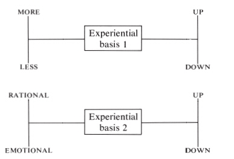

这样的表述强调，每个隐喻的两个部分仅通过经验基础联系在一起，并且只有通过这些经验基础，隐喻才能起到理解的作用。

Such a representation would emphasize that the two parts of each metaphor are linked only via an experiential basis and that it is only by means of these experiential bases that the metaphor can serve the purpose of understanding.

我们不会使用这类表述，仅仅是因为我们对隐喻的经验基础知之甚少。我们将继续在陈述隐喻时使用“是”这个词。就像“更多是向上”一样，但这里的“是”应该被视为某种经验的简写，这种经验是该隐喻的基础，也是我们理解它的基础。

We will not use such representations, but only because we know so little about experiential bases of metaphors. We will continue to use the word “is” in stating metaphors like MORE IS UP, but the IS should be viewed as a shorthand for some set of experiences on which the metaphor is based and in terms of which we understand it.

经验基础在理解那些基于不同经验而彼此不相符的隐喻的运作机制中起着重要作用。例如，“未知为上，已知为下”这样的隐喻。例如“这事*还没定论”*和“事情已经*解决了”。*这种比喻的经验基础与“理解即掌握”非常相似，例如“我没能*理解*他的解释”。对于实物而言，如果你能抓住某样东西并把它拿在手里，你就可以仔细观察它，并对它有一个相当不错的理解。抓住某样东西并观察它更容易。如果物体固定在地面上，就要比漂浮在空中的物体（例如树叶或纸片）更加小心。因此，“未知即向上，已知即向下”与“理解即掌握”相一致。

The role of the experiential basis is important in understanding the workings of metaphors that do not fit together because they are based on different kinds of experience. Take, for example, a metaphor like UNKNOWN IS UP; KNOWN IS DOWN. Examples are “That’s *up in the air”* and “The matter is *settled.”* This metaphor has an experiential basis very much like that of UNDERSTANDING IS GRASPING, as in “I couldn’t *grasp* his explanation.” With physical objects, if you can grasp something and hold it in your hands, you can look it over carefully and get a reasonably good understanding of it. It’s easier to grasp something and look at it carefully if it’s on the ground in a fixed location than if it’s floating through the air (like a leaf or a piece of paper). Thus UNKNOWN IS UP; KNOWN IS DOWN is coherent with UNDERSTANDING IS GRASPING.

但“未知已完成”与“良好已完成”和“完成已完成” （例如“我正在完成*”* ）之类的比喻并不一致。人们会预期“完成已完成”与“已知”搭配，“未完成”与“未知”搭配。 未知。但就垂直性隐喻而言，情况并非如此。原因在于，“未知向上”与“完成向上”的经验基础截然不同。

But UNKNOWN IS UP is not coherent with metaphors like GOOD IS UP and FINISHED IS UP (as in “I’m finishing *up*”). One would expect FINISHED to be paired with KNOWN and UNFINISHED to be paired with UNKNOWN. But, so far as verticality metaphors are concerned, this is not the case. The reason is that UNKNOWN IS UP has a very different experiential basis than FINISHED IS UP.

**5**

**5**

隐喻与文化连贯性

Metaphor and Cultural Coherence

一种文化中最根本的价值观将与该文化中最根本概念的隐喻结构相一致。例如，让我们考虑一下我们社会中一些与我们上下空间化隐喻相一致的文化价值观，以及它们的反面价值观。

The most fundamental values in a culture will be coherent with the metaphorical structure of the most fundamental concepts in the culture. As an example, let us consider some cultural values in our society that are coherent with our UP-DOWN spatialization metaphors and whose opposites would not be.

“越多越好”与“越多越好”和“好越好”的理念是一致的。

“More is better” is coherent with MORE IS UP and GOOD IS UP.

“少即是多”的理念与他们的想法不符。

“Less is better” is not coherent with them.

“越大越好”与“多多益善”和“好即是好”的理念是一致的。

“Bigger is better” is coherent with MORE IS UP and GOOD IS UP.

“越小越好”的理念与他们的想法不符。

“Smaller is better” is not coherent with them.

“未来会更好”与“未来一片光明”和“美好事物正在崛起”相一致。 “未来会更糟”则不然。

“The future will be better” is coherent with THE FUTURE IS UP and GOOD IS UP. “The future will be worse” is not.

“未来会有更多”与“更多是好事”和“未来是好事”的理念相一致。

“There will be more in the future” is coherent with MORE IS UP and THE FUTURE IS UP.

“你未来的地位应该会更高。”与“地位提升”和“未来一片光明”相一致。

“Your status should be higher in the future” is coherent with HIGH STATUS IS UP and THE FUTURE IS UP.

这些价值观深深植根于我们的文化之中。“未来会更好”体现了进步的概念。“未来会更丰富”则特别体现了商品的积累和工资的上涨。“你未来的地位应该更高”体现了职业主义。这些都与我们当前的空间化趋势相符。隐喻；它们的对立面则不然。因此，我们的价值观并非独立存在，而是必须与我们赖以生存的隐喻概念构成一个连贯的体系。我们并非声称所有与……相一致的文化价值观隐喻体系确实存在，只是那些存在且根深蒂固的隐喻体系与该隐喻体系是一致的。

These are values deeply embedded in our culture. “The future will be better” is a statement of the concept of progress. “There will be more in the future” has as special cases the accumulation of goods and wage inflation. “Your status should be higher in the future” is a statement of careerism. These are coherent with our present spatialization metaphors; their opposites would not be. So it seems that our values are not independent but must form a coherent system with the metaphorical concepts we live by. We are not claiming that all cultural values coherent with a metaphorical system actually exist, only that those that do exist and are deeply entrenched are consistent with the metaphorical system.

以上列出的价值观在我们这里仍然适用。文化通常指的是——在其他条件相同的情况下。但由于条件通常并不平等，这些价值观之间常常存在冲突，进而导致与之相关的隐喻之间也存在冲突。为了解释这些价值观（及其隐喻）之间的冲突，我们必须找到使用这些价值观和隐喻的亚文化群体赋予它们的不同优先级。例如，“越多越好”似乎总是由于“更多即更好”具有最清晰的物理基础，因此它具有最高的优先级。例如， “更多即更好”比“更好即更好”更重要，例如“通货膨胀正在上升”和“犯罪率正在上升”。假设通货膨胀和犯罪率都是坏事，那么这些句子的意思就是如此，因为“更多即更好”始终具有最高优先级。

The values listed above hold in our culture generally—all things being equal. But because things are usually not equal, there are often conflicts among these values and hence conflicts among the metaphors associated with them. To explain such conflicts among values (and their metaphors), we must find the different priorities given to these values and metaphors by the subculture that uses them. For instance, MORE IS UP seems always to have the highest priority since it has the clearest physical basis. The priority of MORE IS UP over GOOD IS UP can be seen in examples like “Inflation is rising” and “The crime rate is going up.” Assuming that inflation and the crime rate are bad, these sentences mean what they do because MORE IS UP always has top priority.

一般来说，哪些价值观被赋予优先权，部分取决于……一个人所处的亚文化环境以及部分个人价值观都会影响其价值观。主流文化中的各种亚文化群体拥有共同的基本价值观，但赋予这些价值观不同的优先顺序。例如，在是否现在购买一辆大车（需要支付高额分期付款，这将侵蚀未来的收入）或是否购买一辆更大的车这个问题上， “越大越好”可能与“未来会有更多”相冲突。一辆更小、更便宜的车。在美国，有些亚文化群体会买大车，不考虑未来；而另一些群体则把未来放在首位，选择买小车。在通货膨胀和能源危机之前，拥有一辆小车在某些亚文化群体中曾是一种很高的地位，因为在他们看来，“美德至上”和“节约资源”比“越大越好”更为重要。如今，小型车车主的数量急剧增加，因为存在一种很大的亚文化，在这种文化中，“省钱才是王道”比“越大越好”更为重要。

In general, which values are given priority is partly a matter of the subculture one lives in and partly a matter of personal values. The various subcultures of a mainstream culture share basic values but give them different priorities. For example, BIGGER IS BETTER may be in conflict with THERE WILL BE MORE IN THE FUTURE when it comes to the question of whether to buy a big car now, with large time payments that will eat up future salary, or whether to buy a smaller, cheaper car. There are American subcultures where you buy the big car and don’t worry about the future, and there are others where the future comes first and you buy the small car. There was a time (before inflation and the energy crisis) when owning a small car had a high status within the subculture where VIRTUE IS UP and SAVING RESOURCES IS VIRTUOUS took priority over BIGGER IS BETTER. Nowadays the number of small-car owners has gone up drastically because there is a large subculture where SAVING MONEY IS BETTER has priority over BIGGER IS BETTER.

除了亚文化群体之外，还有一些群体，它们的显著特征是共同拥有某些重要的价值观。这些价值观与主流文化相冲突。但在一些不太明显的情况下，它们又保留了其他主流价值观。以特拉普派修道会为例。在特拉普派，物质财富被视为阻碍侍奉上帝这一重要之事的“少即是多”的信条。特拉普派也认同“美德至上”的主流价值观，但他们赋予美德最高优先级，并赋予其截然不同的定义。在美德领域， “多即是多”的信条依然适用；而地位也依然重要。 虽然它不属于这个世界，而是属于更高的世界——神的国度，但它仍然是“向上” 。此外， “未来会更好”这句话在灵性成长（向上）和最终的救赎（真正意义上的“向上”）方面都是成立的。这在非主流文化群体中很常见。美德、善良和地位的定义或许会被彻底重新定义，但它们仍然是“向上”的。拥有更多重要的东西仍然是更好的选择。就重要的事情而言，未来会更好，等等。对于一个修道院团体来说，其价值体系既具有内在一致性，又与主流文化的主要导向隐喻相一致。

In addition to subcultures, there are groups whose defining characteristic is that they share certain important values that conflict with those of the mainstream culture. But in less obvious ways they preserve other mainstream values. Take monastic orders like the Trappists. There LESS IS BETTER and SMALLER IS BETTER are true with respect to material possessions, which are viewed as hindering what is important, namely, serving God. The Trappists share the mainstream value VIRTUE IS UP, though they give it the highest priority and a very different definition. MORE is still BETTER, though it applies to virtue; and status is still UP, though it is not of this world but of a higher one, the Kingdom of God. Moreover, THE FUTURE WILL BE BETTER is true in terms of spiritual growth (UP) and, ultimately, salvation (really UP). This is typical of groups that are out of the mainstream culture. Virtue, goodness, and status may be radically redefined, but they are still UP. It is still better to have more of what is important, THE FUTURE WILL BE BETTER with respect to what is important, and so on. Relative to what is important for a monastic group, the value system is both internally coherent and, with respect to what is important for the group, coherent with the major orientational metaphors of the mainstream culture.

个人和群体一样，在优先事项以及对善或美德的定义上都存在差异。对他们而言，从这个意义上讲，他们是同一个群体的子群体。相对于对他们而言重要的东西，他们的个人价值体系与主流文化的主要导向隐喻是一致的。

Individuals, like groups, vary in their priorities and in the ways they define what is good or virtuous to them. In this sense, they are subgroups of one. Relative to what is important for them, their individual value systems are coherent with the major orientational metaphors of the mainstream culture.

并非所有文化都像我们一样重视上下方向。有些文化中，平衡或中心性比我们的文化更为重要。或者考虑一下非空间性因素。取向分为主动和被动。对我们而言，在大多数情况下，主动代表向上，被动代表向下。但也有一些文化更重视被动而非主动。总的来说，上下、内外、中心-边缘、主动-被动等主要取向似乎适用于所有文化，但具体哪些概念以何种方向呈现，以及哪些取向最为重要，则因文化而异。

Not all cultures give the priorities we do to up-down orientation. There are cultures where balance or centrality plays a much more important role than it does in our culture. Or consider the nonspatial orientation active-passive. For us ACTIVE IS UP and PASSIVE IS DOWN in most matters. But there are cultures where passivity is valued more than activity. In general the major orientations up-down, in-out, central-peripheral, active-passive, etc., seem to cut across all cultures, but which concepts are oriented which way and which orientations are most important vary from culture to culture.

**6**

**6**

本体论隐喻

Ontological Metaphors

实体与实质的隐喻

Entity and Substance Metaphors

诸如上下、前后、开/关、中心/边缘、近/远等空间方位，为理解方位概念提供了极其丰富的基础。然而，仅凭方位感所能做的也有限。我们对物理对象和物质的经验，为理解提供了更深层次的基础——这种基础超越了单纯的方位感。取向。将我们的经验理解为客体和实体，使我们能够将经验的各个部分提取出来，并将它们视为独立的实体或同质的实体。一旦我们能够将经验识别为实体或实体，我们就可以指称它们、对它们进行分类、分组和量化——并以此方式对它们进行推理。

Spatial orientations like up-down, front-back, on-off, center-periphery, and near-far provide an extraordinarily rich basis for understanding concepts in orientational terms. But one can do only so much with orientation. Our experience of physical objects and substances provides a further basis for understanding—one that goes beyond mere orientation. Understanding our experiences in terms of objects and substances allows us to pick out parts of our experience and treat them as discrete entities or substances of a uniform kind. Once we can identify our experiences as entities or substances, we can refer to them, categorize them, group them, and quantify them—and, by this means, reason about them.

当事物没有清晰的界限时即使它们被划定为有界，我们仍然会将它们归类为这样的事物，例如山脉、街角、树篱等等。这种看待物理现象的方式是为了满足我们的某些目的：定位山脉、在街角相遇、修剪树篱。人类的目的通常要求我们人为地设定边界，使物理现象变得离散，正如我们自身一样：我们是受边界约束的实体。表面。

When things are not clearly discrete or bounded, we still categorize them as such, e.g., mountains, street corners, hedges, etc. Such ways of viewing physical phenomena are needed to satisfy certain purposes that we have: locating mountains, meeting at street corners, trimming hedges. Human purposes typically require us to impose artificial boundaries that make physical phenomena discrete just as we are: entities bounded by a surface.

正如人类对空间方位的基本体验产生了方位隐喻一样，我们对物理对象（尤其是我们自己的身体）的体验也为种类繁多的本体论隐喻提供了基础，即把事件、活动、情感、思想等视为实体和物质的方式。

Just as the basic experiences of human spatial orientations give rise to orientational metaphors, so our experiences with physical objects (especially our own bodies) provide the basis for an extraordinarily wide variety of ontological metaphors, that is, ways of viewing events, activities, emotions, ideas, etc., as entities and substances.

*本体论隐喻*有多种用途，以及各种隐喻反映了它们所服务的目的。以物价上涨为例，我们可以用名词“*通货膨胀”来隐喻地看待物价上涨这一现象。*这为我们提供了一种指称这种现象的方式：

*Ontological metaphors* serve various purposes, and the various kinds of metaphors there are reflect the kinds of purposes served. Take the experience of rising prices, which can be metaphorically viewed as an entity via the noun *inflation.* This gives us a way of referring to the experience:

通货膨胀是一个实体

INFLATION IS AN ENTITY

*通货膨胀正在降低*我们的生活水平。

*Inflation is lowering* our standard of living.

如果*通货膨胀进一步加剧，*我们将无法生存下去。

If there’s much *more inflation,* we’ll never survive.

我们需要*对抗通货膨胀。*

We need to *combat inflation.*

*通货膨胀正将我们*逼入绝境。

*Inflation is backing us* into a corner.

通货膨胀正在对超市收银台和加油站*造成影响。*

*Inflation is taking its toll* at the checkout counter and the gas pump.

*购买土地是应对通货膨胀*的最佳方式。

Buying land is the best way of *dealing with inflation.*

*通货膨胀让我感到恶心。*

*Inflation makes me sick.*

在这些情况下，将通货膨胀视为一个实体，使我们能够提及它、量化它、识别它的某个特定方面、将其视为一种原因、采取相应的行动，甚至可能让我们相信我们理解了它。它。像这样的本体论隐喻对于我们理性地处理自身经验而言是必不可少的。

In these cases, viewing inflation as an entity allows us to refer to it, quantify it, identify a particular aspect of it, see it as a cause, act with respect to it, and perhaps even believe that we understand it. Ontological metaphors like this are necessary for even attempting to deal rationally with our experiences.

我们用于此类目的的本体论隐喻种类繁多。以下列表概述了这些目的，并列举了一些服务于这些目的的本体论隐喻的代表性示例。

The range of ontological metaphors that we use for such purposes is enormous. The following list gives some idea of the kinds of purposes, along with representative examples of ontological metaphors that serve them.

*指*

*Referring*

我*对昆虫的恐惧*快把我老婆逼疯了。

My *fear of insects* is driving my wife crazy.

那是一个*漂亮的捕获。*

That was a *beautiful catch.*

我们正努力实现*和平。*

We are working toward *peace.*

中产阶级是*美国政治*中一股强大*的**无声力量。*

The *middle class* is a *powerful silent force* in *American politics.*

这场战争关乎*我们国家的荣誉*。

The *honor of our country* is at stake in this war.

*量化*

*Quantifying*

读完这本书需要*极大的耐心。*

It will take *a lot of patience* to finish this book.

世界上充满*了仇恨。*

There is *so much hatred* in the world.

杜邦公司在特拉华州拥有*很大的政治影响力*。

DuPont has *a lot of political power* in Delaware.

你心中*充满了敌意。*

You’ve got *too much hostility* in you.

皮特·罗斯很有*拼劲，而且热爱棒球。知识。*

Pete Rose has *a lot of hustle and baseball know-how.*

*识别方面*

*Identifying Aspects*

压力之下，*他性格中丑陋的一面*就会显露出来。

The *ugly side of his personality* comes out under pressure.

*战争的残酷*使我们所有人丧失人性。

The *brutality of war* dehumanizes us all.

我跟不上*现代生活的节奏。*

I can’t keep up with the *pace of modern life.*

他最近的*情绪健康状况*恶化了。

His *emotional health* has deteriorated recently.

我们在越南从未体验过*胜利的喜悦。*

We never got to feel the *thrill of victory* in Vietnam.

*找出原因*

*Identifying Causes*

*责任带来的压力*导致他精神崩溃。

The *pressure of his responsibilities* caused his breakdown.

他这样做是出于*愤怒。*

He did it out of *anger.*

我们的影响力世界衰落是因为我们*缺乏道德品质。*

Our influence in the world has declined because of our *lack of moral fiber.*

*内部纷争*让他们失去了冠军。

*Internal dissension* cost them the pennant.

*设定目标和激励行动*

*Setting Goals and Motivating Actions*

他去纽约是为了*追求名利。*

He went to New York to *seek fame and fortune.*

*以下是确保财务安全*所需采取的措施。

Here’s what you have to do to *insure financial security.*

我正在改变我的生活方式，以便找到*真正的幸福。*

I’m changing my way of life so that I can *find true happiness.*

面对*国家安全威胁，联邦调查局将迅速采取行动。*

The FBI will act quickly in the face of a *threat to national security.*

她看到了自己结婚是*她解决问题的办法。*

She saw getting married as the *solution to her problems.*

与方位隐喻类似，大多数这类表达方式并未被察觉为隐喻。原因之一是本体论隐喻与方位隐喻一样，用途非常有限——指称、量化等等。仅仅将非物质事物视为实体或物质，并不能让我们理解其本质。关于这一点还有很多可以探讨。但本体论隐喻还可以进一步阐述。以下两个例子说明了“心灵是一种实体”这一本体论隐喻在我们的文化中是如何被阐释的。

As in the case of orientational metaphors, most of these expressions are not noticed as being metaphorical. One reason for this is that ontological metaphors, like orientational metaphors, serve a very limited range of purposes—referring, quantifying, etc. Merely viewing a nonphysical thing as an entity or substance does not allow us to comprehend very much about it. But ontological metaphors may be further elaborated. Here are two examples of how the ontological metaphor THE MIND IS AN ENTITY is elaborated in our culture.

心灵是一台机器

THE MIND IS A MACHINE

我们仍在努力*寻找*这个方程的解法。

We’re still trying to *grind out* the solution to this equation.

我今天脑子一片*空白*。

My mind just isn’t *operating* today.

哇，*事情开始进展了*！

Boy, the *wheels are turning* now!

我今天*有点生疏了*。

I’m *a little rusty* today.

我们一直在努力解决这个问题一天下来，我们*快没力气了。*

We’ve been working on this problem all day and now we’re *running out of steam.*

心灵是易碎的。

THE MIND IS A BRITTLE OBJECT

她的自尊心非常*脆弱。*

Her ego is very *fragile.*

自从他妻子去世后，你必须*小心对待他。*

You have to *handle him with care* since his wife’s death.

他在交叉询问中*崩溃了。*

He *broke* under cross-examination.

她*很容易被击垮。*

She is *easily crushed.*

这次经历*彻底击垮了*他。

The experience *shattered* him.

我*快崩溃了。*

I’m *going to pieces.*

他脑子*一片空白。*

His mind *snapped.*

这些隐喻具体指明了不同类型的对象。它们为我们提供了不同的隐喻模型，来解释心灵的运作方式。正是如此，这使我们能够专注于心理体验的不同方面。“机器”隐喻让我们将心灵理解为具有开/关状态、效率水平、生产能力、内部机制、能量来源和运行条件。“易碎物体”隐喻则远没有那么丰富。它只能让我们谈论心理强度。然而，指的是可以用这两种隐喻来理解的一系列心理体验。我们想到的例子如下：

These metaphors specify different kinds of objects. They give us different metaphorical models for what the mind is and thereby allow us to focus on different aspects of mental experience. The MACHINE metaphor gives us a conception of the mind as having an on-off state, a level of efficiency, a productive capacity, an internal mechanism, a source of energy, and an operating condition. The BRITTLE OBJECT metaphor is not nearly as rich. It allows us to talk only about psychological strength. However, there is a range of mental experience that can be conceived of in terms of either metaphor. The examples we have in mind are these:

他崩溃了。（心灵是一台机器）

He broke down. (THE MIND IS A MACHINE)

他崩溃了。（心灵是脆弱的）

He cracked up. (THE MIND IS A BRITTLE OBJECT)

但这两个比喻关注的并非*心理*体验的同一方面。机器发生故障时，它就停止运转了。易碎物体破碎时，它的碎片散落一地。飞起来，可能会带来危险的后果。因此，例如，当某人精神失常、变得狂暴或暴力时，说“他崩溃了”是恰当的。另一方面，如果某人因心理原因变得萎靡不振、无法正常工作，我们更倾向于说“他崩溃了”。

But these two metaphors do not focus on *exactly* the same aspect of mental experience. When a machine breaks down, it simply ceases to function. When a brittle object shatters, its pieces go flying, with possibly dangerous consequences. Thus, for example, when someone goes crazy and becomes wild or violent, it would be appropriate to say “He cracked up.” On the other hand, if someone becomes lethargic and unable to function for psychological reasons, we would be more likely to say “He broke down.”

诸如此类的本体论隐喻如此自然，如此普遍地存在于我们的思想中。它们通常被认为是显而易见的、对心理现象的直接描述。我们大多数人从未意识到它们是比喻。我们把“他在压力下崩溃了”之类的陈述直接视为真或假。事实上，这种表达方式最初是由……使用的。多位记者试图解释丹·怀特为何携带枪支前往旧金山市政厅并枪杀市长乔治·弗洛伊德。莫斯康尼。对我们大多数人来说，这类解释似乎完全自然。原因在于，像“心灵是易碎的物体”这样的比喻是我们这种文化中心灵模型不可或缺的一部分；我们大多数人都是基于这种模型进行思考和行动的。

Ontological metaphors like these are so natural and so pervasive in our thought that they are usually taken as self-evident, direct descriptions of mental phenomena. The fact that they are metaphorical never occurs to most of us. We take statements like “He cracked under pressure” as being directly true or false. This expression was in fact used by various journalists to explain why Dan White brought his gun to the San Francisco City Hall and shot and killed Mayor George Moscone. Explanations of this sort seem perfectly natural to most of us. The reason is that metaphors like THE MIND IS A BRITTLE OBJECT are an integral part of the model of the mind that we have in this culture; it is the model most of us think and operate in terms of.

容器隐喻

Container Metaphors

*陆地面积*

*Land Areas*

我们是物质实体，被我们的身体表面所束缚，与世界其他部分隔绝开来。我们每个人都像皮肤一样，将自身与外界连接起来，并将世界体验为外部世界。我们每个人都是一个容器，拥有边界表面和内外方向。我们将自身的内外方向投射到其他由表面界定的物理对象上。因此，我们也将它们视为具有内外之分的容器。房间和房屋显然是容器。从一个房间移动到另一个房间，就是从一个容器移动到另一个容器。从一个房间移动到另一个房间，也就是*从*一个房间*走到*另一个房间。我们甚至会赋予固体物体这种方向感，比如我们敲开一块石头看看里面是什么。我们也把这种方向感强加于自然环境。林间空地被视为有边界，我们可以把自己看作是*在*空地里或空地*外*，*是在*树林里或树林*外。*林间空地似乎存在某种我们可以感知到的自然边界——树木大致停止生长、空地大致开始生长的模糊区域。但即便没有可以被视为界定容器的自然物理边界，我们也会人为地划定边界——将领地划分出来，使其拥有内部空间和外部边界——无论是墙壁、栅栏，还是抽象的线条或平面。人类最基本的本能之一就是领地意识。而界定领地，为其划定边界，本身就是一种量化行为。有界物体，无论是人、岩石还是陆地，都有其大小。这使得我们可以根据它们所包含的物质数量来量化它们。例如，堪萨斯州就是一个有界区域——一个容器——这就是为什么我们可以说“那里有……”*堪萨斯州*有很多土地。

We are physical beings, bounded and set off from the rest of the world by the surface of our skins, and we experience the rest of the world as outside us. Each of us is a container, with a bounding surface and an in-out orientation. We project our own in-out orientation onto other physical objects that are bounded by surfaces. Thus we also view them as containers with an inside and an outside. Rooms and houses are obvious containers. Moving from room to room is moving from one container to another, that is, moving *out of* one room and *into* another. We even give solid objects this orientation, as when we break a rock open to see what’s inside it. We impose this orientation on our natural environment as well. A clearing in the woods is seen as having a bounding surface, and we can view ourselves as being *in* the clearing or *out of* the clearing, *in* the woods or *out of* the woods. A clearing in the woods has something we can perceive as a natural boundary—the fuzzy area where the trees more or less stop and the clearing more or less begins. But even where there is no natural physical boundary that can be viewed as defining a container, we impose boundaries—marking off territory so that it has an inside and a bounding surface—whether a wall, a fence, or an abstract line or plane. There are few human instincts more basic than territoriality. And such defining of a territory, putting a boundary around it, is an act of quantification. Bounded objects, whether human beings, rocks, or land areas, have sizes. This allows them to be quantified in terms of the amount of substance they contain. Kansas, for example, is a bounded area—a CONTAINER—which is why we can say, “There’s a lot of land *in* Kansas.”

物质本身可以被视为容器。例如，以一桶水为例。当你进入桶中时，你就进入了水中。桶和水都可以被视为容器，但类型不同。桶是容器物体，而水是容器物质。

Substances can themselves be viewed as containers. Take a tub of water, for example. When you get into the tub, you get into the water. Both the tub and the water are viewed as containers, but of different sorts. The tub is a CONTAINER OBJECT, while the water is a CONTAINER SUBSTANCE.

*视野*

*The Visual Field*

我们将视觉领域概念化为一个容器，并概念化我们所看到的，就如同它内部的一部分。甚至“视觉*场”*这个词本身也暗示了这一点。这个比喻很自然，源于这样一个事实：当你观察某个区域（土地、地面空间等等）时，你的视野界定了该区域的边界，也就是你能看到的部分。鉴于一个有边界的物理空间是一个容器，而我们的视野又与这个有边界的空间相关联，在物理空间中， “视觉场域即容器”这一隐喻概念自然而然地涌现出来。因此我们可以说：

We conceptualize our visual field as a container and conceptualize what we see as being inside it. Even the term “visual *field”* suggests this. The metaphor is a natural one that emerges from the fact that, when you look at some territory (land, floor space, etc.), your field of vision defines a boundary of the territory, namely, the part that you can see. Given that a bounded physical space is a CONTAINER and that our field of vision correlates with that bounded physical space, the metaphorical concept VISUAL FIELDS ARE CONTAINERS emerges naturally. Thus we can say:

船渐渐*出现在*视野中。

The ship is *coming into* view.

我*已**看到*他了。

I *have* him *in* sight.

我看不见他——树*挡住*了。

I can’t see him—the tree is *in* the way.

他现在已经*不见了*。

He’s *out of* sight now.

它就*在*我*视野**的*中心。

That’s *in* the *center of* my *field* of vision.

*周围什么也*没有。

There’s *nothing in* sight.

我无法同时看到*所有**的*船只。

I can’t get *all* of the ships *in* sight at once.

*事件、行动、活动和状态*

*Events, Actions, Activities, and States*

我们使用本体论运用隐喻来理解事件、行为、活动和状态。事件和行为被隐喻地概念化为对象，活动被隐喻地概念化为物质，状态被隐喻地概念化为容器。例如，比赛就是一个事件，它被视为一个独立的实体。比赛存在。它存在于空间和时间之中，并且拥有明确的边界。因此，我们将其视为一个容器对象，其中包含参与者（即物体），例如起点和终点（它们是隐喻性的物体），以及跑步这项活动（它是隐喻性的实体）。因此，我们可以这样描述一场比赛：

We use ontological metaphors to comprehend events, actions, activities, and states. Events and actions are conceptualized metaphorically as objects, activities as substances, states as containers. A race, for example, is an event, which is viewed as a discrete entity. The race exists in space and time, and it has well-defined boundaries. Hence we view it as a CONTAINER OBJECT, having in it participants (which are objects), events like the start and finish (which are metaphorical objects), and the activity of running (which is a metaphorical substance). Thus we can say of a race:

你*参加*周日的比赛吗？（比赛作为容器对象）

Are you *in* the race on Sunday? (race as CONTAINER OBJECT)

你*要去参加*比赛吗？（比赛作为宾语）

Are you *going to* the race? (race as OBJECT)

你*看了*比赛吗？（比赛作为客体）

Did you *see* the race? (race as OBJECT)

比赛的终点真是太激动人心了。（终点作为容器*内*的事件对象）目的）

The *finish* of the race was really exciting. (finish as EVENT OBJECT within CONTAINER OBJECT)

比赛中有*很多精彩的跑步镜头。（跑步就像*容器中的物质）

There was *a lot of good running in* the race. (running as a SUBSTANCE in a CONTAINER)

直到最后我才开始进行*冲刺。（冲刺是*关键）

I couldn’t do *much sprinting* until the end. (sprinting as SUBSTANCE)

*比赛进行到一半时*，我耗尽了体力。（比赛作为容器对象）

*Halfway into* the race, I ran out of energy. (race as CONTAINER OBJECT)

他现在已经*退出*比赛了。（种族作为容器对象）

He’s *out of* the race now. (race as CONTAINER OBJECT)

一般而言，各种活动都被比喻为物质，因此也被比喻为容器：

Activities in general are viewed metaphorically as SUBSTANCES and therefore as CONTAINERS:

*在*洗涤过程中我从窗户往外看，水溅得地板上到处都是。

*In* washing the window, I splashed water all over the floor.

杰瑞是怎么*逃避*洗窗户的？

How did Jerry *get out of* washing the windows?

*除了*擦窗户，你还做了什么？

*Outside of* washing the windows, what else did you do?

你擦了*多少窗户？*

*How much* window-washing did you do?

你是如何*入行*做擦窗工的？

How did you *get into* window-washing as a profession?

他现在正*专心致志地*擦窗户。

He’s *immersed in* washing the windows right now.

因此，活动被视为构成它们的行动和其他活动的容器。它们也是可以将其视为储存能量、所需物质及其副产品的容器，这些副产品既可以被视为存在于*其中*，也可以被*视为从中产生*：

Thus, activities are viewed as containers for the actions and other activities that make them up. They are also viewed as containers for the energy and materials required for them and for their by-products, which may be viewed as *in* them or as *emerging from* them:

我*花了很多精力*擦窗户。

I *put a lot of energy into* washing the windows.

我从擦窗户*中获得了很多满足感。*

I *get a lot of satisfaction out of* washing windows.

*洗窗户能给人带来很多满足感*。

*There is a lot of satisfaction in* washing windows.

各种状态也可以被概念化为容器。因此，我们有如下示例：这些：

Various kinds of states may also be conceptualized as containers. Thus we have examples like these:

他*恋爱了*。

He’s *in* love.

我们现在*脱离危险了*。

We’re *out of* trouble now.

他*正在苏醒*。

He’s *coming out of* the coma.

我正在*慢慢恢复*身材。

I’m *slowly getting into* shape.

他*进入了*一种极度兴奋的状态。

He *entered* a state of euphoria.

他*陷入了*抑郁。

He *fell into* a depression.

他终于从期末考试周结束后一直*处于的恍惚状态**中苏醒过来。*

He finally *emerged from* the catatonic state he had been *in* since the end of finals week.

**7**

**7**

**拟人化**

**Personification**

或许最显而易见的本体论隐喻，就是将物理对象进一步具体化为“人”。这使我们能够从人类的动机、特征和行为的角度来理解与非人类实体相关的各种经验。以下是一些例子：

Perhaps the most obvious ontological metaphors are those where the physical object is further specified as being a person. This allows us to comprehend a wide variety of experiences with nonhuman entities in terms of human motivations, characteristics, and activities. Here are some examples:

他的*理论*向我解释了工厂化养殖的鸡的行为。

His *theory explained* to me the behavior of chickens raised in factories.

这一*事实反对*主流理论。

This *fact argues* against the standard theories.

*生活欺骗了*我。

*Life has cheated* me.

*通货膨胀正在蚕食*我们的利润。

*Inflation is eating up* our profits.

他的*宗教信仰告诉*他，他不能喝上好的法国葡萄酒。

His *religion tells* him that he cannot drink fine French wines.

迈克尔逊*-莫雷实验催生了*一种新的物理理论。

The *Michelson-Morley experiment gave birth to* a new physical theory.

*癌症*最终*夺走了*他的生命。

*Cancer* finally *caught up with* him.

在这些例子中，我们都看到了非人类事物被拟人化。但拟人化并非单一统一的普遍过程。拟人化手法的不同之处在于它着重刻画人物的哪些方面。请看以下例子。

In each of these cases we are seeing something nonhuman as human. But personification is not a single unified general process. Each personification differs in terms of the aspects of people that are picked out. Consider these examples.

通货膨胀*已经动摇了*我们经济的根基。

Inflation *has attacked* the foundation of our economy.

通货膨胀*让*我们*举步维艰。*

Inflation *has pinned* us *to the wall.*

我们现在最大的*敌人**是*通货膨胀。

Our biggest *enemy* right now *is* inflation.

美元*已被*通货膨胀摧毁。

The dollar *has been destroyed* by inflation.

通货膨胀让我积蓄全*没了。*

Inflation *has robbed* me of my savings.

通货膨胀让全国最优秀的经济学家*都束手无策。*

Inflation *has outwitted* the best economic minds in the country.

通货膨胀 *造就了*一代唯利是图的人。

Inflation *has given birth* to a money-minded generation.

这里将通货膨胀拟人化，但这种比喻并非如此。仅仅把通货膨胀比作一个人是不够的。更确切地说，通货膨胀是一个敌人。这不仅为我们提供了一种非常具体的思考通货膨胀的方式，也提供了一种应对通货膨胀的方式。我们把通货膨胀视为一个敌人，它会攻击我们、伤害我们、掠夺我们，甚至摧毁我们。因此，“通货膨胀是敌人”这一比喻促使政府采取政治和经济行动，并为其提供正当理由：向通货膨胀宣战、设定目标、呼吁做出牺牲、建立新的指挥系统等等。

Here inflation is personified, but the metaphor is not merely INFLATION IS A PERSON. It is much more specific, namely, INFLATION IS AN ADVERSARY. It not only gives us a very specific way of thinking about inflation but also a way of acting toward it. We think of inflation as an adversary that can attack us, hurt us, steal from us, even destroy us. The INFLATION IS AN ADVERSARY metaphor therefore gives rise to and justifies political and economic actions on the part of our government: declaring war on inflation, setting targets, calling for sacrifices, installing a new chain of command, etc.

关键在于，拟人化是一个涵盖范围极广的比喻范畴，每一种比喻都着重刻画人物的不同方面。或者说，看待人的方式。它们的共同之处在于，它们都是本体论隐喻的延伸，使我们能够用人类的视角来理解世界上的各种现象——这些视角基于我们自身的动机、目标、行为和特征。用人类的视角来看待像通货膨胀这样抽象的事物，具有一种独一无二的解释力。对大多数人来说，这很有道理。当我们因复杂的经济和政治因素（而这些因素又无人真正理解）而遭受重大经济损失时，“通货膨胀是敌人”这一比喻至少能为我们提供一个连贯的解释，说明我们为何会遭受这些损失。

The point here is that personification is a general category that covers a very wide range of metaphors, each picking out different aspects of a person or ways of looking at a person. What they all have in common is that they are extensions of ontological metaphors and that they allow us to make sense of phenomena in the world in human terms—terms that we can understand on the basis of our own motivations, goals, actions, and characteristics. Viewing something as abstract as inflation in human terms has an explanatory power of the only sort that makes sense to most people. When we are suffering substantial economic losses due to complex economic and political factors that no one really understands, the INFLATION IS AN ADVERSARY metaphor at least gives us a coherent account of why we’re suffering these losses.

**8**

**8**

**转喻**

**Metonymy**

在我们探讨过的拟人化案例中，我们将人类的特征赋予了非人类的事物——例如理论、疾病、通货膨胀等等。在这些案例中，并没有实际指代任何人类。当我们说“通货膨胀让我损失了积蓄”时，我们并不是用“通货膨胀”来指代某个人。这类案例必须与……等情况区分开来。

In the cases of personification that we have looked at we are imputing human qualities to things that are not human—theories, diseases, inflation, etc. In such cases there are no actual human beings referred to. When we say “Inflation robbed me of my savings,” we are not using the term “inflation” to refer to a person. Cases like this must be distinguished from cases like

火腿*三明治*正等着他结账呢。

The *ham sandwich* is waiting for his check.

这里，“火腿三明治”指的是一个真实的人，也就是点餐的人。这种情况并非拟人化隐喻，因为我们理解“火腿三明治”并非赋予其人类的特征。相反，我们是用一个实体来指代与其相关的另一个实体。这属于……我们将称之为*转喻。*以下是一些例子：

where the expression “the ham sandwich” is being used to refer to an actual person, the person who ordered the ham sandwich. Such cases are not instances of personification metaphors, since we do not understand “the ham sandwich” by imputing human qualities to it. Instead, we are using one entity to refer to another that is related to it. This is a case of what we will call *metonymy.* Here are some further examples:

他喜欢读*萨德侯爵*的作品。

He likes to read the *Marquis de Sade.* (= the writings of the marquis)

他是跳舞的*。*

He’s in *dance.* (= the dancing profession)

*丙烯颜料*已经席卷了艺术界。（指丙烯颜料的使用）

*Acrylic* has taken over the art world. (= the use of acrylic paint)

《*泰晤士报**》*的记者还没到新闻发布会现场。

The *Times* hasn’t arrived at the press conference yet. (= the reporter from the *Times*)

格伦迪太太不喜欢穿牛仔裤*。*

Mrs. Grundy frowns on *blue jeans.* (= the wearing of blue jeans)

*新挡风玻璃换上新的雨刮器*就足够了。（=指换上新雨刮器的状态）

*New windshield wipers* will satisfy him. (= the state of having new wipers)

我们将传统修辞学家称之为*提喻的现象（*即用部分代表整体）作为转喻的一个特例，如下例所示。

We are including as a special case of metonymy what traditional rhetoricians have called *synecdoche,* where the part stands for the whole, as in the following.

部分成就整体

THE PART FOR THE WHOLE

汽车堵塞了我们的高速公路。 *（* = 汽车群）

The *automobile* is clogging our highways. (= the collection of automobiles)

我们需要几个*身强力壮的人*加入我们的团队。

We need a couple of *strong bodies* for our team. (= strong people)

有大学里有很多*优秀人才。（=聪明人）*

There are a lot of *good heads* in the university. (= intelligent people)

我买了*辆*新车（汽车、摩托车等） 。

I’ve got a new *set of wheels.* (= car, motorcycle, etc.)

我们需要给组织注入一些*新鲜血液。（= 新人）*

We need some *new blood* in the organization. (= new people)

在这些例子中，如同其他转喻例子一样，一个实体被用来指代另一个实体。隐喻和转喻是不同的*修辞*过程。隐喻本质上是一种用另一个事物来指代某一事物的方式。转喻主要指称另一个事物，其主要功能是帮助理解。而转喻则主要具有指称功能，即允许我们用一个事物来*代表*另一个事物。但转喻不仅仅是一种指称手段，它也具有帮助理解的功能。例如，在“部分代表整体”这个转喻中，有很多部分可以代表整体。整体。我们选择哪个部分，决定了我们关注的是整体的哪个方面。当我们说项目需要一些“*聪明人*”时，我们用“聪明人”指的是“有智慧的人”。关键不在于用一个部分（头脑）来代表一个整体（人），而在于突出人的某个特定特征，即智慧，而智慧恰恰与头脑相关联。其他类型的转喻也是如此。当我们说“《泰晤士报*》*还没到新闻发布会现场”时，我们用“《泰晤士报*》”*指的不仅仅是某个记者，还暗示了该记者所代表的机构的重要性。因此，“《泰晤士报》还没到新闻发布会现场”的含义与“《*泰晤士报*》还没到新闻发布会现场”的含义不同。“史蒂夫·罗伯茨还没有到达……”新闻发布会”，尽管史蒂夫·罗伯茨可能是*《纽约时报》*所指的记者。

In these cases, as in the other cases of metonymy, one entity is being used to refer to another. Metaphor and metonymy are different *kinds* of processes. Metaphor is principally a way of conceiving of one thing in terms of another, and its primary function is understanding. Metonymy, on the other hand, has primarily a referential function, that is, it allows us to use one entity to *stand for* another. But metonymy is not merely a referential device. It also serves the function of providing understanding. For example, in the case of the metonymy THE PART FOR THE WHOLE there are many parts that can stand for the whole. Which part we pick out determines which aspect of the whole we are focusing on. When we say that we need some *good heads* on the project, we are using “good heads” to refer to “intelligent people.” The point is not just to use a part (head) to stand for a whole (person) but rather to pick out a particular characteristic of the person, namely, intelligence, which is associated with the head. The same is true of other kinds of metonymies. When we say “The *Times* hasn’t arrived at the press conference yet,” we are using “The *Times”* not merely to refer to some reporter or other but also to suggest the importance of the institution the reporter represents. So “The *Times* has not yet arrived for the press conference” means something different from “Steve Roberts has not yet arrived for the press conference,” even though Steve Roberts may be the *Times* reporter in question.

因此，转喻与隐喻在某些方面具有相同的作用，并且作用方式也大致相同，但它使我们能够更具体地关注所指事物的某些方面。它也像隐喻一样，不仅仅是一种诗歌或修辞手法，也不仅仅是语言问题。转喻概念（例如部分为整体）是我们日常思考、行动和说话方式的一部分。

Thus metonymy serves some of the same purposes that metaphor does, and in somewhat the same way, but it allows us to focus more specifically on certain aspects of what is being referred to. It is also like metaphor in that it is not just a poetic or rhetorical device. Nor is it just a matter of language. Metonymic concepts (like THE PART FOR THE WHOLE) are part of the ordinary, everyday way we think and act as well as talk.

例如，在我们的概念体系中，有一个特殊的转喻，即“部分代表整体”，也就是“脸代表人”。例如：

For example, we have in our conceptual system a special case of the metonymy THE PART FOR THE WHOLE, namely, THE FACE FOR THE PERSON. For example:

她只是个*花瓶。*

She’s just a *pretty face.*

观众席上有*很多张面孔。*

There are an *awful lot of faces* out there in the audience.

我们需要一些*新面孔*。

We need some *new faces* around here.

这种转喻它在我们的文化中发挥着积极的作用。绘画和摄影中的肖像画传统都以此为基础。如果你让我给你看一张我儿子的照片，而我给你看了一张他脸部的照片，你会感到满意。你会认为自己已经看到了他的照片。但如果我给你看一张他身体的照片，而没有看到脸部，你会觉得很奇怪，不会感到满意。你可能会甚至会问：“但他长什么样呢？”由此可见，“以脸指代人”这种转喻并非仅仅是语言问题。在我们的文化中，我们观察一个人的脸——而不是他的姿态或动作——来获取关于他的基本信息。当我们根据一个人的脸来感知他，并基于这种感知采取行动时，我们就是在运用转喻。

This metonymy functions actively in our culture. The tradition of portraits, in both painting and photography, is based on it. If you ask me to show you a picture of my son and I show you a picture of his face, you will be satisfied. You will consider yourself to have seen a picture of him. But if I show you a picture of his body without his face, you will consider it strange and will not be satisfied. You might even ask, “But what does he look like?” Thus the metonymy THE FACE FOR THE PERSON is not merely a matter of language. In our culture we look at a person’s face—rather than his posture or his movements—to get our basic information about what the person is like. We function in terms of a metonymy when we perceive the person in terms of his face and act on those perceptions.

与隐喻类似，转喻转喻概念并非随机或任意的现象，不应被视为孤立事件。它们也具有系统性，以下是我们文化中存在的一些典型例子。

Like metaphors, metonymies are not random or arbitrary occurrences, to be treated as isolated instances. Metonymic concepts are also systematic, as can be seen in the following representative examples that exist in our culture.

部分成就整体

THE PART FOR THE WHOLE

快*过来*！

Get *your butt* over here!

我们不雇用*长头发的人。*

We don’t hire *longhairs.*

巨人队需要在右外野增加一名*更强的投手。*

The Giants need a *stronger arm* in right field.

我新买了一辆*四速手动挡的V8发动机汽车。*

I’ve got a new *four-on-the-floor V-8.*

产品生产商

PRODUCER FOR PRODUCT

我要狮牌啤酒*。*

I’ll have a *Löwenbräu.*

他买了一辆*福特车。*

He bought a *Ford.*

他的书房里挂着一幅*毕加索的画。*

He’s got a *Picasso* in his den.

我讨厌读*海德格尔。*

I hate to read *Heidegger.*

用户使用的对象

OBJECT USED FOR USER

萨克斯*手*今天得了流感。

The *sax* has the flu today.

BLT*的*倾倒效率很差。

The *BLT* is a lousy tipper.

*他雇佣的枪手*要价五万美元。

The *gun* he hired wanted fifty grand.

我们需要一名更好的三垒*手。*

We need a better *glove* at third base.

*公交车*罢工了。

The *buses* are on strike.

受控控制器

CONTROLLER FOR CONTROLLED

*尼克松*轰炸了河内。

*Nixon* bombed Hanoi.

*小泽*昨晚的演唱会糟透了。

*Ozawa* gave a terrible concert last night.

*拿破仑*在滑铁卢战败。

*Napoleon* lost at Waterloo.

*凯西斯坦格尔*赢得了许多锦旗。

*Casey Stengel* won a lot of pennants.

一辆奔驰车追尾了*我。*

A Mercedes rear-ended *me.*

负责任的人的机构

INSTITUTION FOR PEOPLE RESPONSIBLE

*埃克森美孚*再次提价。

*Exxon* has raised its prices again.

你永远不可能让*大学*同意这一点。

You’ll never get the *university* to agree to that.

陆军希望恢复征兵制*。*

The *Army* wants to reinstitute the draft.

参议院认为堕胎是不道德的*。*

The *Senate* thinks abortion is immoral.

我不赞同*政府的*做法。

I don’t approve of the *government’s* actions.

该机构的所在地

THE PLACE FOR THE INSTITUTION

白宫*方面*保持沉默。

The *White House* isn’t saying anything.

*华盛顿*冷漠无情。满足人民的需求。

*Washington* is insensitive to the needs of the people.

克里姆林宫*威胁*要抵制下一轮SALT谈判。

The *Kremlin* threatened to boycott the next round of SALT talks.

*本季巴黎*流行长裙。

*Paris* is introducing longer skirts this season.

*好莱坞*已经今非昔比了。

*Hollywood* isn’t what it used to be.

*华尔街*一片恐慌。

*Wall Street* is in a panic.

活动地点

THE PLACE FOR THE EVENT

我们不能让泰国变成另一个*越南。*

Let’s not let Thailand become another *Vietnam.*

记住*阿拉莫。*

Remember *the Alamo.*

*珍珠港事件*至今仍对我们的外交政策产生影响。

*Pearl Harbor* still has an effect on our foreign policy.

*水门事件*改变了我们的政治。

*Watergate* changed our politics.

它是今天一整天都待在*中央车站。*

It’s been *Grand Central Station* here all day.

像这样的转喻概念与隐喻概念一样，都具有系统性。以上句子并非随意列举，而是某些普遍存在的转喻概念的实例，我们正是基于这些概念来组织我们的思想和行为。转喻概念使我们能够通过事物之间的关联来理解事物。当我们思考时，转喻概念就如同一个整体，通过与另一事物的联系，将事物联系起来。谈到*毕加索的作品，*我们并非仅仅将其视为一件独立的艺术品。我们会从艺术家本人的角度去思考它，例如他的艺术理念、技法、在艺术史上的地位等等。我们之所以对*毕加索的作品，甚至是他少年时期的一幅素描，都抱有敬畏之心，正是因为这些作品与艺术家本人有着密切的联系。这就是*“生产者-产品”转喻对两者产生影响的方式。我们的思想和行动。同样，当服务员说“火腿三明治要结账了”时，她对这个人本身并不感兴趣，而只是把他当作顾客，这就是为什么这种说法是不人道的。尼克松本人可能没有在河内投下原子弹，但通过“控制者”指代“受控的”这种转喻，我们不仅会说“尼克松轰炸了河内”，还会认为是他干的。轰炸事件，并追究他的责任。这之所以可能，是因为“控制者指代被控制者”这种转喻关系的本质，其中重点在于责任。

Metonymic concepts like these are systematic in the same way that metaphoric concepts are. The sentences given above are not random. They are instances of certain general metonymic concepts in terms of which we organize our thoughts and actions. Metonymic concepts allow us to conceptualize one thing by means of its relation to something else. When we think of *a Picasso,* we are not just thinking of a work of art alone, in and of itself. We think of it in terms of its relation to the artist, that is, his conception of art, his technique, his role in art history, etc. We act with reverence toward *a Picasso,* even a sketch he made as a teen-ager, because of its relation to the artist. This is a way in which the PRODUCER FOR PRODUCT metonymy affects both our thought and our action. Similarly, when a waitress says “The ham sandwich wants his check,” she is not interested in the person as a person but only as a customer, which is why the use of such a sentence is dehumanizing. Nixon himself may not have dropped the bombs on Hanoi, but via the CONTROLLER FOR CONTROLLED metonymy we not only say “Nixon bombed Hanoi” but also think of him as doing the bombing and hold him responsible for it. Again this is possible because of the nature of the metonymic relationship in the CONTROLLER FOR CONTROLLED metonymy, where responsibility is what is focused on.

因此，与隐喻一样，转喻概念不仅构建了我们的语言，也构建了我们的思想、态度和行为。而且，与隐喻概念一样，转喻概念也根植于我们的经验。事实上，转喻概念的根源通常比隐喻概念更为明显，因为它通常涉及直接的物理或因果联系。 例如，整体转喻源于我们对部分与整体之间关系的经验。生产者指产品则基于生产者与产品之间的因果（通常是物理）关系。生产者及其产品。活动场地的选择基于我们对活动实际举办地点的经验。等等。

Thus, like metaphors, metonymic concepts structure not just our language but our thoughts, attitudes, and actions. And, like metaphoric concepts, metonymic concepts are grounded in our experience. In fact, the grounding of metonymic concepts is in general more obvious than is the case with metaphoric concepts, since it usually involves direct physical or causal associations. The PART FOR WHOLE metonymy, for example, emerges from our experiences with the way parts in general are related to wholes. PRODUCER FOR PRODUCT is based on the causal (and typically physical) relationship between a producer and his product. THE PLACE FOR THE EVENT is grounded in our experience with the physical location of events. And so on.

文化和宗教象征是转喻的特殊例子。例如，在基督教中，鸽子象征圣灵。正如典型的转喻一样，这种象征意义并非随意而为，而是根植于西方文化中对鸽子的传统认知。以及基督教神学中圣灵的概念。鸽子之所以成为圣灵的象征，而不是鸡、秃鹫或鸵鸟，是有原因的。鸽子被认为是美丽、友善、温柔，最重要的是，和平的象征。作为一种鸟类，它的自然栖息地是天空，而天空象征着天堂，也就是圣灵的自然居所。鸽子是一种飞行姿态优美、滑翔无声的鸟，人们经常看到它从天而降，落在人群中。

Cultural and religious symbolism are special cases of metonymy. Within Christianity, for example, there is the metonymy DOVE FOR HOLY SPIRIT. As is typical with metonymies, this symbolism is not arbitrary. It is grounded in the conception of the dove in Western culture and the conception of the Holy Spirit in Christian theology. There is a reason why the dove is the symbol of the Holy Spirit and not, say, the chicken, the vulture, or the ostrich. The dove is conceived of as beautiful, friendly, gentle, and, above all, peaceful. As a bird, its natural habitat is the sky, which metonymically stands for heaven, the natural habitat of the Holy Spirit. The dove is a bird that flies gracefully, glides silently, and is typically seen coming out of the sky and landing among people.

文化和宗教的概念体系本质上是隐喻性的。象征性转喻是日常经验与构成宗教和文化特征的连贯隐喻体系之间的关键联系。这些象征性转喻根植于我们的物质世界。经验是理解宗教和文化概念的重要途径。

The conceptual systems of cultures and religions are metaphorical in nature. Symbolic metonymies are critical links between everyday experience and the coherent metaphorical systems that characterize religions and cultures. Symbolic metonymies that are grounded in our physical experience provide an essential means of comprehending religious and cultural concepts.

**9**

**9**

对隐喻连贯性的挑战

Challenges to Metaphorical Coherence

我们已经提供的证据表明，隐喻和转喻并非随机出现，而是构成连贯的系统，我们正是通过这些系统来理解自身的经验。然而，在日常隐喻表达中，我们很容易发现明显的矛盾之处。我们并未对这些矛盾之处进行全面研究，但我们详细考察过的那些例子表明，它们并非不连贯。事实并非如此，尽管它们起初看起来是这样。让我们来看两个例子。

We have offered evidence that metaphors and metonymies are not random but instead form coherent systems in terms of which we conceptualize our experience. But it is easy to find apparent incoherences in everyday metaphorical expressions. We have not made a complete study of these, but those that we have looked at in detail have turned out not to be incoherent at all, though they appeared that way at first. Let us consider two examples.

一个明显的隐喻矛盾

An Apparent Metaphorical Contradiction

查尔斯·菲尔莫尔（Charles Fillmore）在一次谈话中观察到，英语似乎有两种相互矛盾的时间组织方式。第一种方式是，未来在前，过去在后：

Charles Fillmore has observed (in conversation) that English appears to have two contradictory organizations of time. In the first, the future is in front and the past is behind:

在接下来的几周里……（未来）

In the weeks ahead of us . . . (future)

那些都过去了。

That’s all behind us now. (past)

In the second, the future is behind and the past is in front:

接下来的几周……（未来）

In the following weeks . . . (future)

在前几周……（过去）

In the preceding weeks . . . (past)

这似乎是时间隐喻组织上的一个矛盾。此外，这些看似矛盾的隐喻可以混合使用而不会产生不良影响，例如：

This appears to be a contradiction in the metaphorical organization of time. Moreover, the apparently contradictory metaphors can mix with no ill effect, as in

我们展望*接下来*的*几周*。

We’re looking *ahead* to the *following* weeks.

这里似乎*“前进”*组织着未来，而*“跟随”*组织着未来。把它放在后面。

Here it appears that *ahead* organizes the future in front, while *following* organizes it behind.

为了看出这里确实存在某种内在逻辑，我们首先我们必须考虑一些关于前后组织结构的事实。有些事物，比如人和汽车，天生就有正面和背面，但另一些事物，比如树木，则没有。在某些情况下，一块石头也可能具有前后组织结构。假设你正在观察一块中等大小的石头，而你和石头之间有一个球——比如说，如果球距离岩石一英尺远，那么你可以说“球在岩石前面”。岩石被赋予了前后方向，就好像它有一个正面朝向你一样。但这并非普遍适用。在某些语言中——例如豪萨语——岩石的方向则相反，如果球在你和岩石之间，你会说球在岩石后面。

To see that there is, in fact, a coherence here, we first have to consider some facts about front-back organization. Some things, like people and cars, have inherent fronts and backs, but others, like trees, do not. A rock may receive a front-back organization under certain circumstances. Suppose you are looking at a medium-sized rock and there is a ball between you and the rock—say, a foot away from the rock. Then it is appropriate for you to say “The ball is in front of the rock.” The rock has received a front-back orientation, as if it had a front that faced you. This is not universal. There are languages—Hausa, for instance—where the rock would receive the reverse orientation and you would say that the ball was behind the rock if it was between you and the rock.

移动物体通常会获得一个前后方向，使其前端指向运动方向（或标准运动方向，例如，倒车的汽车始终保持前端朝向运动方向）。例如，一颗球形卫星静止时没有前端，但在轨道上运行时，由于其运动方向，便会获得一个前端。

Moving objects generally receive a front-back orientation so that the front is in the direction of motion (or in the canonical direction of motion, so that a car backing up retains its front). A spherical satellite, for example, that has no front while standing still, gets a front while in orbit by virtue of the direction in which it is moving.

现在，英语中的时间结构是基于时间的。这是一个运动物体的比喻，象征着未来正向我们靠近：

Now, time in English is structured in terms of the TIME IS A MOVING OBJECT metaphor, with the future moving toward us:

总有一天……

The time will come when . . .

那个时代早已过去……

The time has long since gone when . . .

行动的时刻已经到来。

The time for action has arrived.

“时光飞逝”这句谚语正是“时间是运动的物体”这一比喻的体现。因为我们面向未来，所以我们得出以下结论：

The proverb “Time flies” is an instance of the TIME IS A MOVING OBJECT metaphor. Since we are facing toward the future, we get:

接下来几周将发生……

Coming up in the weeks ahead . . .

我期待着圣诞节的到来。

I look forward to the arrival of Christmas.

在我们面前的是一个伟大的这是一个机会，我们不想让它从我们身边溜走。

Before us is a great opportunity, and we don’t want it to pass us by.

根据“时间是运动的物体”这一比喻，时间被赋予了前后方向，朝向运动的方向，就像任何运动的物体一样。因此，未来是它朝向我们移动，也朝向我们，我们发现这样的表达方式：

By virtue of the TIME IS A MOVING OBJECT metaphor, time receives a front-back orientation facing in the direction of motion, just as any moving object would. Thus the future is facing toward us as it moves toward us, and we find expressions like:

我无法面对未来。

I can’t face the future.

未来景象……

The face of things to come . . .

让我们直面未来。

Let’s meet the future head-on.

现在，虽然*诸如“在我们前面”、“我期待”*和“*在我们之前”*之类的表达方式，将时间与人联系起来；而诸如“*在……之前*”和“在……之后”之类的表达方式，则将时间与时间联系起来。因此，我们得到*：*

Now, while expressions like *ahead of us, I look forward,* and *before us* orient times with respect to people, expressions like *precede* and *follow* orient times with respect to times. Thus we get:

下周及下下周。

Next week and the week following it.

但并非：

but not:

接下来的一周……

The week following me . . .

既然未来面向我们，那么之后的时代就更加遥远，而所有未来的时代都发生在现在之后。这就是为什么*接下来的几周和**我们未来几周的情况*一样。

Since future times are facing toward us, the times following them are further in the future, and all future times follow the present. That is why the *weeks to follow* are the same as the *weeks ahead of us.*

这个例子的目的不仅在于表明不存在矛盾，还在于展现其中涉及的所有微妙细节：时间是运动物体的隐喻，由于时间是运动物体而赋予的前后方向，以及诸如*“跟随”、“先于”*和*“面对”*等词语在语境中的一致运用。这种比喻手法被应用于时间。所有这些连贯细致的比喻结构都融入了我们日常关于时间的字面语言中，如此熟悉以至于我们通常不会注意到它们。

The point of this example is not merely to show that there is no contradiction but also to show all the subtle details that are involved: the TIME IS A MOVING OBJECT metaphor, the front-back orientation given to time by virtue of its being a moving object, and the consistent application of words like *follow, precede,* and *face* when applied to time on the basis of the metaphor. All of this consistent detailed metaphorical structure is part of our everyday literal language about time, so familiar that we would normally not notice it.

连贯性与一致性

Coherence versus Consistency

我们已经证明，“时间是一个运动的物体”这一比喻具有内在一致性。但我们还有另一种理解时间流逝的方式：

We have shown that the TIME IS A MOVING OBJECT metaphor has an internal consistency. But there is another way in which we conceptualize the passing of time:

时间它是静止的，而我们穿过它

TIME IS STATIONARY AND WE MOVE THROUGH IT

随着岁月流逝……

As we go through the years, . . .

随着我们进入20世纪80年代，……

As we go further into the 1980s, . . .

一年即将结束。

We’re approaching the end of the year.

这里我们讨论的是“时间流逝”的两种子情况：一种情况是我们运动而时间静止；另一种情况是时间运动而我们静止。它们的共同之处在于相对于我们而言的相对运动，未来在我们前方。以及身后的过去。也就是说，它们是同一个隐喻的两个子情况，如图所示。

What we have here are two subcases of TIME PASSES US: in one case, we are moving and time is standing still; in the other, time is moving and we are standing still. What is in common is relative motion with respect to us, with the future in front and the past behind. That is, they are two subcases of the same metaphor, as shown in the accompanying diagram.

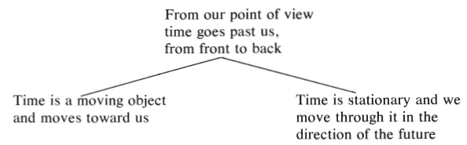

换句话说，它们有一个主要的共同含义。这两个比喻都表明，从我们的角度来看，时间是从前向后流逝的。

This is another way of saying that they have a major common entailment. Both metaphors entail that, from our point of view, time goes past us from front to back.

尽管这两个比喻并不一致（也就是说，它们无法构成单一的意象），但它们仍然“契合”，因为它们都是一个大范畴的子范畴，因此共享一个重要的共同内涵。两者之间存在差异。我们发现，*相互契合*（即“协调一致”）的隐喻与彼此相符的隐喻之间存在*差异。隐喻之间的联系更倾向于体现在连贯性而非一致性上。*

Although the two metaphors are not consistent (that is, they form no single image), they nonetheless “fit together,” by virtue of being subcategories of a major category and therefore sharing a major common entailment. There is a difference between metaphors that are *coherent* (that is, “fit together”) with each other and those that are *consistent.* We have found that the connections between metaphors are more likely to involve coherence than consistency.

再举一个例子，我们来看另一个比喻：

As another example, let us take another metaphor:

爱是一段旅程

LOVE IS A JOURNEY

看看*我们走了多远。*

Look *how far we’ve come.*

我们正*处于十字路口。*

We’re *at a crossroads.*

我们只能*各奔东西了。*

We’ll just have to *go our separate ways.*

我们不能*回头了现在。*

We can’t *turn back now.*

我觉得这段关系不会*有结果。*

I don’t think this relationship is *going anywhere.*

*我们在哪里*？

*Where* are we?

我们被*困住了。*

We’re *stuck.*

这是一条*漫长而坎坷的道路。*

It’s been a *long, bumpy road.*

这段关系走上了*死路。*

This relationship is a *dead-end street.*

我们只是*在白费力气。*

We’re just *spinning our wheels.*

我们的婚姻*岌岌可危。*

Our marriage is *on the rocks.*

我们偏离了*轨道。*

We’ve gotten *off the track.*

这段关系正在*走向破裂。*

This relationship is *foundering.*

这里的基本比喻是旅程，而旅程有很多种：比如开车。旅行，无论是火车旅行还是海上航行。

Here the basic metaphor is that of a JOURNEY, and there are various types of journeys that one can make: a car trip, a train trip, or a sea voyage.

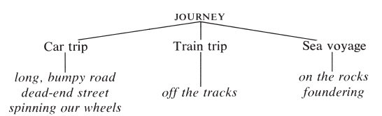

再次强调，并没有一个统一的意象能够完全契合所有“旅程”的隐喻。它们之所以具有*连贯性*，是因为它们都是“旅程”的隐喻，尽管它们具体描述的是不同的旅行方式。同样的情况也出现在“时间是运动的物体”的隐喻中，事物可以以多种方式运动。因此，*时间飞逝，时间缓慢流逝，时间飞逝而过。*总的来说，隐喻概念的定义不是用具体的形象（飞行、爬行、沿着道路行走等），而是用更一般的类别，如经过。

Once again, there is no single consistent image that the JOURNEY metaphors all fit. What makes them *coherent* is that they are all JOURNEY metaphors, though they specify different means of travel. The same sort of thing occurs with the TIME IS A MOVING OBJECT metaphor, where there are various ways in which something can move. Thus, *time flies, time creeps along, time speeds by.* In general, metaphorical concepts are defined not in terms of concrete images (flying, creeping, going down the road, etc.), but in terms of more general categories, like passing.

10

10

更多示例

Some Further Examples

我们一直认为，隐喻在一定程度上构建了我们的日常概念，而这种结构也反映在我们的字面语言中。在全面理解这些论断的哲学意义之前，我们需要更多例子。在接下来的每个例子中，我们都会给出一个隐喻，并列出一些作为该隐喻特例的日常表达。这个比喻。英语表达方式有两种：一种是简单的字面表达，另一种是符合比喻且属于日常谈论该主题的习语。

We have been claiming that metaphors partially structure our everyday concepts and that this structure is reflected in our literal language. Before we can get an overall picture of the philosophical implications of these claims, we need a few more examples. In each of the ones that follow we give a metaphor and a list of ordinary expressions that are special cases of the metaphor. The English expressions are of two sorts: simple literal expressions and idioms that fit the metaphor and are part of the normal everyday way of talking about the subject.

理论（和论证）是建筑物

THEORIES (and ARGUMENTS) ARE BUILDINGS

这就是你理论的*基础吗？这个理论需要更多**支撑。*论证不够*稳固。*我们需要更多事实，否则论证会*崩溃。*我们需要*构建……*对此有一个*强有力的*论据。我还没想好论证的*形式。这里还有一些事实来**支持*这个理论。我们需要用*可靠的*论据来支撑这个理论。这个理论的*成败*取决于*这个*论据的强度。这个论证崩溃*了**。*他们*驳斥了*他最新的理论。我们将证明这个理论毫无*根据。*到目前为止，我们只收集到了一些证据*。**该*理论的框架。

Is that the *foundation* for your theory? The theory needs more *support.* The argument is *shaky.* We need some more facts or the argument will *fall apart.* We need to *construct* a *strong* argument for that. I haven’t figured out yet what the *form* of the argument will be. Here are some more facts to *shore up* the theory. We need to *buttress* the theory with *solid* arguments. The theory will *stand* or *fall* on the *strength* of that argument. The argument *collapsed.* They *exploded* his latest theory. We will show that theory to be without *foundation.* So far we have put together only the *framework* of the theory.

思想即食物

IDEAS ARE FOOD

他说的那些话*让我很不舒服。*这篇文章里全是些*不成熟的事实、不成熟的想法和老掉牙的理论。*这里的事实太多了，我根本*消化*不了。我实在无法*接受*这种说法。这个论点*听起来很可疑。*让我好好*琢磨琢磨*。这倒是个理论。你可以好好*琢磨琢磨。*我们需要让这个想法*先酝酿*一段时间。这*值得深思。*他是个*如饥似渴的*读者。我们不需要*手把手*地教学生。他把那本书*读完了*。让我们先把这个想法*放在一边，*好好琢磨琢磨。这是论文的*精华部分。让这个想法**好好酝酿*一段时间。这个想法已经*酝酿*好几年了。

What he said *left a bad taste in my mouth.* All this paper has in it are *raw facts, half-baked ideas, and warmed-over theories.* There are too many facts here for me to *digest* them all. I just can’t *swallow* that claim. That argument *smells fishy.* Let me *stew* over that for a while. Now there’s a theory you can really *sink your teeth into.* We need to let that idea *percolate* for a while. That’s *food for thought.* He’s a *voracious* reader. We don’t need to *spoon-feed* our students. He *devoured* the book. Let’s let that idea *simmer on the back burner* for a while. This is the *meaty* part of the paper. Let that idea *jell* for a while. That idea has been *fermenting* for years.

就生死而言，思想是有机体，可以是人，也可以是植物。

With respect to life and death IDEAS ARE ORGANISMS, either PEOPLE or PLANTS.

思想即人

IDEAS ARE PEOPLE

相对论*催生了*物理学中无数的思想。他是现代生物学之*父。这是谁的**杰作*？看看他的思想*催生了什么。*那些思想在中世纪就*消亡了。他的思想将**永存*。认知心理学仍处于*起步阶段。*这是一个应该*复兴的思想。*你是从哪里*挖到*这个想法的？他*呼吸着……*为这个想法*注入新的活力。*

The theory of relativity *gave birth to* an enormous number of ideas in physics. He is the *father* of modern biology. Whose *brainchild* was that? Look at what his ideas have *spawned.* Those ideas *died off* in the Middle Ages. His ideas will *live on* forever. Cognitive psychology is still in its *infancy.* That’s an idea that ought to be *resurrected.* Where’d you *dig up* that idea? He *breathed new life into* that idea.

思想是植物

IDEAS ARE PLANTS

他的想法终于实现了*。*那个想法夭折了。那只是一个*萌芽中**的*理论。这个想法需要数年时间才能*完全成熟。*他认为化学只是物理学的一个*分支*。数学有很多*分支。*他伟大思想的种子在他年轻时就已播下*。*她拥有*丰富的想象力。我有一个想法**，*我想……*在你的脑海中种下种子*。他思想*贫瘠*。

His ideas have finally come to *fruition.* That idea *died on the vine.* That’s a *budding* theory. It will take years for that idea to *come to full flower.* He views chemistry as a mere *offshoot* of physics. Mathematics has many *branches.* The *seeds* of his great ideas were *planted* in his youth. She has a *fertile* imagination. Here’s an idea that I’d like to *plant* in your mind. He has a *barren* mind.

创意即产品

IDEAS ARE PRODUCTS

我们确实*在源源不断地**产生*新想法。这周我们*想出了*很多点子。他*产生*新想法的速度惊人。近年来他的*思维效率*有所下降。我们需要打磨这个想法，*让它更完善**、*更流畅*。*这只是一个粗略的想法，需要进一步*完善。*

We’re really *turning* (*churning, cranking, grinding*) *out* new ideas. We’ve *generated* a lot of ideas this week. He *produces* new ideas at an astounding rate. His *intellectual productivity* has decreased in recent years. We need to *take the rough edges off* that idea, *hone it down, smooth it out.* It’s a rough idea; it needs to be *refined.*

思想是商品

IDEAS ARE COMMODITIES

*如何包装*你的想法很重要。他不会*接受*的。这个想法根本行不通*。*好的想法永远都有*市场*。这个想法*毫无价值*。他一直是……*宝贵的想法？我**一分钱*都不会给。你的想法在知识市场根本没有机会*。*

It’s important how you *package* your ideas. He won’t *buy* that. That idea just won’t *sell.* There is always a *market* for good ideas. That’s a *worthless* idea. He’s been a source of *valuable* ideas. I wouldn’t *give a plugged nickel for* that idea. Your ideas don’t have a chance in the *intellectual marketplace.*

创意就是资源

IDEAS ARE RESOURCES

他*黔驴技穷了*。别*浪费*你的精力。做一些小项目。咱们集思广益吧*。*他是个*足智多谋的*人。我们已经把所有点子都*用光了。那是个**没用的*想法。这个想法*很有价值。*

He *ran out of* ideas. Don’t *waste* your thoughts on small projects. Let’s *pool* our ideas. He’s a *resourceful* man. We’ve *used up* all our ideas. That’s a *useless* idea. That idea will *go a long way.*

创意就是金钱

IDEAS ARE MONEY

我也来说两句*。*他有*很多*想法。那本书简直就是思想的*宝库。他有**很多*想法。

Let me put in my *two cents’ worth.* He’s *rich* in ideas. That book is a *treasure trove* of ideas. He has a *wealth* of ideas.

思想是锋利的切割工具

IDEAS ARE CUTTING INSTRUMENTS

这是一个*精辟的*想法。它直击问题*的核心。那是一个**一针见血的*评论。他很*机智，反应**敏捷*，头脑*清晰*。她*把*他的论点驳得*体无完肤。*

That’s an *incisive* idea. That *cuts right to the heart of* the matter. That was a *cutting* remark. He’s *sharp.* He has a *razor* wit. He has a *keen* mind. She *cut* his argument *to ribbons.*

理念即时尚

IDEAS ARE FASHIONS

那种想法几年前就*过时了*。我听说现在社会生物学*很*流行。马克思主义目前在西欧*很时髦。那种想法**早就过时了！*那是个*陈旧的*想法。英语批评的新*趋势*是什么？*老旧的*观念在当今社会没有立足之地。他通过阅读《纽约书评》*来了解时事。伯克利是**前卫*思想的中心。符号学现在相当*时髦。*革命的思想在美国已经不再*流行。变革语法**热潮*在六十年代中期席卷美国，最近才传到欧洲。

That idea went *out of style* years ago. I hear sociobiology *is in* these days. Marxism is currently *fashionable* in western Europe. That idea is *old hat!* That’s an *outdated* idea. What are the new *trends* in English criticism? *Old-fashioned* notions have no place in today’s society. He keeps *up-to-date* by reading the New York Review of Books. Berkeley is a center of *avant-garde* thought. Semiotics has become quite *chic.* The idea of revolution is no longer *in vogue* in the United States. The transformational grammar *craze* hit the United States in the mid-sixties and has just made it to Europe.

理解即是看见；思想是光源；话语是光的媒介。

UNDERSTANDING IS SEEING; IDEAS ARE LIGHT-SOURCES; DISCOURSE IS A LIGHT-MEDIUM

我*我明白*你的意思了。但从我的*角度来看，**情况有所*不同。你对此有何*看法？我的**看法*不同。现在我明白了*全貌。*让我*指出一点*。这真是个*有见地的*想法。这话说得*太好了*。论点很清晰。*之前*的讨论却很*晦涩*。你能*解释一下*你的观点吗？论点很*清晰*。之前的讨论却很*混乱。*

I *see* what you’re saying. It *looks* different from my *point of view.* What is your *outlook* on that? I *view* it differently. Now I’ve got the *whole picture.* Let me *point something out* to you. That’s an *insightful* idea. That was a *brilliant* remark. The argument is *clear.* It was a *murky* discussion. Could you *elucidate* your remarks? It’s a *transparent* argument. The discussion was *opaque.*

爱是一种生理现象力（电磁力、引力等）

LOVE IS A PHYSICAL FORCE (ELECTROMAGNETIC, GRAVITATIONAL, etc.)

我能感觉到我们之间有*电流穿过。**火花四溅。*我被她*深深吸引*。他们之间有着无法抗拒的*吸引力。他们**一见钟情*。他的整个生活*都围绕*着她。他们周围的*气氛*总是*充满活力。*他们的关系中蕴含着惊人的*能量*。但他们失去了*动力。*

I could feel the *electricity* between us. There were *sparks.* I was *magnetically drawn* to her. They are uncontrollably *attracted* to each other. They *gravitated* to each other immediately. His whole life *revolves* around her. The *atmosphere* around them is always *charged.* There is incredible *energy* in their relationship. They lost their *momentum.*

爱情是病人

LOVE IS A PATIENT

这是一段*病态的*关系。他们拥有*牢固、健康的*婚姻。这段婚姻已经*死了*——无法*挽回。*他们的婚姻正在*好转*。我们正在*重新振作起来。*他们的关系*非常好。*他们的婚姻死气沉沉。他们的婚姻*岌岌可危**。*这段婚姻已经*筋疲力尽*。

This is a *sick* relationship. They have a *strong, healthy* marriage. The marriage is *dead*—it can’t be *revived.* Their marriage is *on the mend.* We’re getting *back on our feet.* Their relationship is *in really good shape.* They’ve got a *listless* marriage. Their marriage is *on its last legs.* It’s a *tired* affair.

爱情是疯狂

LOVE IS MADNESS

我为她*疯狂*。她*快把我逼疯了。*他总是 *他简直对她赞不绝口*。他为她*疯狂*了。我也非常*喜欢*哈利。我对她简直*着迷*。

I’m *crazy* about her. She *drives me out of my mind.* He constantly *raves* about her. He’s gone *mad* over her. I’m just *wild* about Harry. I’m *insane* about her.

爱是魔法

LOVE IS MAGIC

她对我*施了魔法。**魔法*消失了。我曾被*迷惑。*她*催眠了我。*他让我*神魂颠倒。*我被他*迷住了*。我被她*迷住了*。她*魅力四射。*

She *cast her spell* over me. The *magic* is gone. I was *spellbound.* She had me *hypnotized.* He has me *in a trance.* I was *entranced* by him. I’m *charmed* by her. She is *bewitching.*

爱即战争

LOVE IS WAR

他以风流成性著称*。*她*曾为他争风吃醋，但**最终还是败给了*他的情妇。他*逃离了*她。 *她步步紧逼。*他锲而不舍地*追求*她*。*他慢慢地*赢得了*她的芳心。他*娶*了她。他*征服了*她。她被追求者*包围*。他不得不一一*击退*他们*。*他争取了她朋友的*帮助。他**拉拢了*她的母亲。这真是我见过*最不合适的联姻了。*

He is known for his many rapid *conquests.* She *fought for* him, but his mistress *won out.* He *fled from* her *advances.* She *pursued* him *relentlessly.* He is slowly *gaining ground* with her. He *won* her hand in marriage. He *overpowered* her. She is *besieged* by suitors. He has to *fend* them *off.* He *enlisted the aid* of her friends. He *made an ally* of her mother. Theirs is a *misalliance* if I’ve ever seen one.

财富是一个隐藏的物体

WEALTH IS A HIDDEN OBJECT

他*想*发财致富。他炫耀自己*新获得的*财富。他是个*寻宝者。*她是个*拜金女。*他*失去了*所有财产。他正在*寻找*财富。

He’s *seeking* his fortune. He’s flaunting his *new-found* wealth. He’s a *fortune-hunter.* She’s a *gold-digger.* He *lost* his fortune. He’s *searching for* wealth.

重要性就是大

SIGNIFICANT IS BIG

他是服装行业的大佬，也是*文坛*巨匠。这是*近年来*广告界*最棒的创意。他**鹤立鸡群，遥遥领先*于业内所有人。那只是*个小*罪，一个*善意*的谎言。我震惊于这罪行的*严重性。那是我经历过的**最伟大的*事件之一。在世界大赛历史上留下浓墨重彩的一笔。他的成就*远超*其他*平庸*之辈。

He’s a *big* man in the garment industry. He’s a *giant* among writers. That’s the *biggest* idea to hit advertising in years. He’s *head and shoulders above* everyone in the industry. It was only a *small* crime. That was only a *little* white lie. I was astounded at the *enormity* of the crime. That was one of the *greatest* moments in World Series history. His accomplishments *tower over* those of *lesser* men.

视觉即触觉；眼睛是肢体。

SEEING IS TOUCHING; EYES ARE LIMBS

我无法*将*目光*从*她身上移开。他目不转睛地*盯着*电视。她的目光*捕捉到了*图案的每一个细节。他们的目光*相遇了。*她的目光始终没有*离开**他*的脸。她的目光*扫过*房间里的一切。他想要所有的*一切**尽收眼底*。

I can’t *take* my eyes *off* her. He sits with his eyes *glued to* the TV. Her eyes *picked out* every detail of the pattern. Their eyes *met.* She never *moves* her eyes *from* his face. She *ran* her eyes *over* everything in the room. He wants everything *within reach of* his eyes.

眼睛是情绪的容器

THE EYES ARE CONTAINERS FOR THE EMOTIONS

*我能看到他眼中的*恐惧。他的眼中充满*了愤怒。她的**眼中*充满了激情。他的眼中*流露出*怜悯。她眼中的恐惧*挥之不去。他的**眼中流露出**爱意*。她的眼中*噙满*了泪水。

I could see the fear *in* his eyes. His eyes were *filled* with anger. There was passion *in* her eyes. His eyes *displayed* his compassion. She couldn’t *get* the fear *out* of her eyes. Love *showed in* his eyes. Her eyes *welled* with emotion.

情感影响是身体接触

EMOTIONAL EFFECT IS PHYSICAL CONTACT

母亲的去世对他*打击**很大。*这个想法*让我震惊。*她真是个*美人。*我被深深*打动了。*他的真诚深深*打动*了我。他*给*世界留下了深刻的印象。他的话让我*深受感动，也**让我无比震撼。*

His mother’s death *hit* him *hard.* That idea *bowled me over.* She’s a *knockout.* I was *struck* by his sincerity. That really *made an impression* on me. He *made his mark on* the world. I was *touched* by his remark. That *blew me away.*

生理和心理状态都是人体内存在的实体。

PHYSICAL AND EMOTIONAL STATES ARE ENTITIES WITHIN A PERSON

*他肩膀*疼。别让我*得*流感。我的感冒已经*从头蔓延到胸口了。*他的疼痛*消失了。*他的抑郁症*又复发了。*热茶加蜂蜜可以*止咳*。他几乎动弹不得。*他强忍着*喜悦，笑容*消失了*。*“收起*你那副冷笑*，*士兵！”他的恐惧*挥之不去。“*我得*摆脱*这种抑郁——它一直*缠着我。”* “如果你感冒了，多喝茶就能*把它排出体外。”他**身上*没有一丝*懦弱*。 “他*骨子里*没有一根诚实的骨头。”

He has a pain *in* his shoulder. Don’t *give* me the flu. My cold has *gone from my head to my chest.* His pains *went away.* His depression *returned.* Hot tea and honey will *get rid of* your cough. He could barely *contain* his joy. The smile *left* his face. *Wipe* that sneer *off* your face, private! His fears *keep coming back.* I’ve got to *shake off* this depression—it keeps *hanging on.* If you’ve got a cold, drinking lots of tea will *flush it out* of your system. There isn’t a *trace* of cowardice *in* him. He hasn’t got *an honest bone in his body.*

活力是一种物质

VITALITY IS A SUBSTANCE

她精力充沛，活力*四射。她*他精力*充沛，而他却**精疲力竭*。我一天下来也筋疲力尽，感觉*精疲力竭**。*那*件事*耗费了我*大量精力*。

She’s *brimming* with vim and vigor. She’s *overflowing* with vitality. He’s *devoid* of energy. I don’t *have* any energy *left* at the end of the day. I’m *drained.* That *took a lot out of* me.

生命是一个容器

LIFE IS A CONTAINER

我的人生*充实而*精彩。他的人生*空虚寂寞**，没什么值得*他*去*追求的了。她的生活*充实*而精彩。*尽情享受*人生吧。他的人生*充满了*悲伤。*尽情活出你的人生。*

I’ve had a *full* life. Life is *empty* for him. There’s *not much left* for him *in* life. Her life is *crammed* with activities. *Get the most out of* life. His life *contained* a great deal of sorrow. Live your life *to the fullest.*

人生如赌游戏

LIFE IS A GAMBLING GAME

我愿意*冒险一试。*胜算*不大。但*我还有一张王牌。他*手里**握着所有王牌。*胜负难料*。*如果你*打得好，*就能赢。他*赢了很多*。他真是个彻头彻尾的*失败者。*关键时刻他会在哪里*？*那是我的*王牌。*他在*虚张声势。*总统把*底牌藏得很深。*咱们加大赌注吧*。*或许我们需要增加*一些诱人的筹码。*我认为我们应该 *保持现状。*这*全凭运气。*风险*很高。*

I’ll *take my chances.* The *odds are against me.* I’ve got an *ace up my sleeve.* He’s *holding all the aces.* It’s a *toss-up.* If you *play your cards right,* you can do it. He *won big.* He’s a real *loser.* Where is he when the *chips are down?* That’s my *ace in the hole.* He’s *bluffing.* The president is *playing it close to his vest.* Let’s *up the ante.* Maybe we need to *sweeten the pot.* I think we should *stand pat.* That’s *the luck of the draw.* Those are *high stakes.*

在最后一组例子中，我们看到的是一系列所谓的“语言公式”、“固定形式表达”或“短语词汇”。它们在很多方面都像单个词一样发挥作用，而且语言中这类短语词汇数以千计。在给出的例子中，一组这样的短语词汇由一个单一的隐喻结构连贯地组织起来。概念。虽然它们都是“人生如赌”这一隐喻的实例，但它们通常用来谈论生活，而非赌博情境。它们是谈论生活情境的正常方式，正如使用“建构”一词是谈论理论的正常方式一样。正是在这个意义上，我们将它们纳入了我们所谓的由隐喻构成的字面表达之中。概念。如果你说“我们胜算渺茫”或“我们只能碰碰运气”，人们不会认为你是在用比喻，而是在使用符合实际情况的日常语言。然而，你谈论、理解甚至体验自身处境的方式，却仍然带有比喻的意味。

In this last group of examples we have a collection of what are called “speech formulas,” or “fixed-form expressions,” or “phrasal lexical items.” These function in many ways like single words, and the language has thousands of them. In the examples given, a set of such phrasal lexical items is coherently structured by a single metaphorical concept. Although each of them is an instance of the LIFE IS A GAMBLING GAME metaphor, they are typically used to speak of life, not of gambling situations. They are normal ways of talking about life situations, just as using the word “construct” is a normal way of talking about theories. It is in this sense that we include them in what we have called literal expressions structured by metaphorical concepts. If you say “The odds are against us” or “We’ll have to take our chances,” you would not be viewed as speaking metaphorically but as using the normal everyday language appropriate to the situation. Nevertheless, your way of talking about, conceiving, and even experiencing your situation would be metaphorically structured.

11

11

隐喻结构的局部性

The Partial Nature of Metaphorical Structuring

到目前为止，我们已经描述了隐喻定义概念的系统性特征。这类概念可以通过许多不同的隐喻来理解（例如，“时间就是金钱”、“时间是运动的物体”等等）。概念的隐喻结构必然是片面的，并且反映在语言的词汇中，包括短语词汇包含诸如“没有根基”之类的固定形式表达。由于概念以系统的方式进行隐喻性结构化，例如，“理论是建筑物”，因此我们可以使用来自一个领域（建筑物）的表达（*构造、根基*）来谈论隐喻定义的领域（理论）中的相应概念。例如*，什么是根基？*在隐喻定义的领域（理论）中的含义将取决于隐喻概念“理论是建筑物”如何被用来构建概念“理论”的细节。

Up to this point we have described the systematic character of metaphorically defined concepts. Such concepts are understood in terms of a number of different metaphors (e.g., TIME IS MONEY, TIME IS A MOVING OBJECT, etc.). The metaphorical structuring of concepts is necessarily partial and is reflected in the lexicon of the language, including the phrasal lexicon, which contains fixed-form expressions such as “to be without foundation.” Because concepts are metaphorically structured in a systematic way, e.g., THEORIES ARE BUILDINGS, it is possible for us to use expressions (*construct, foundation*) from one domain (BUILDINGS) to talk about corresponding concepts in the metaphorically defined domain (THEORIES). What *foundation,* for example, means in the metaphorically defined domain (THEORY) will depend on the details of how the metaphorical concept THEORIES ARE BUILDINGS is used to structure the concept THEORY.

用于构建概念“理论”的“建筑”概念部分是地基和外壳。屋顶、内部房间、楼梯和走廊等建筑构件不属于该概念的范畴。 理论。因此， “理论是建筑物”这一比喻包含一个“已使用”的部分（地基和外壳）和一个“未使用”的部分（房间、楼梯等）。诸如*“构建”*和*“地基”*之类的表达方式，正是这种比喻概念中“已使用”部分的体现，也是我们日常关于理论的字面语言的一部分。

The parts of the concept BUILDING that are used to structure the concept THEORY are the foundation and the outer shell. The roof, internal rooms, staircases, and hallways are parts of a building not used as part of the concept THEORY. Thus the metaphor THEORIES ARE BUILDINGS has a “used” part (foundation and outer shell) and an “unused” part (rooms, staircases, etc.). Expressions such as *construct* and *foundation* are instances of the used part of such a metaphorical concept and are part of our ordinary literal language about theories.

但是，反映这种现象的语言表达方式又如何呢？比喻中“未使用”的部分理论就像建筑物一样吗？以下是四个例子：

But what of the linguistic expressions that reflect the “unused” part of a metaphor like THEORIES ARE BUILDINGS? Here are four examples:

他的理论中包含成千上万个小房间和漫长蜿蜒的走廊。

His theory has thousands of little rooms and long, winding corridors.

他的理论具有包豪斯式的伪功能主义简洁性。

His theories are Bauhaus in their pseudofunctional simplicity.

他偏爱那种装饰着石像鬼的宏伟哥特式建筑。

He prefers massive Gothic theories covered with gargoyles.

复杂的理论通常会在逻辑层面上出现问题。

Complex theories usually have problems with the plumbing.

这些句子超出了正常字面语言的范畴，属于以下哪项？通常被称为“比喻”或“想象”语言。因此，字面表达（“他构建了一个理论”）和想象表达（“他的理论充满了怪诞的元素”）都可以是同一个一般隐喻的例子（理论是建筑物）。

These sentences fall outside the domain of normal literal language and are part of what is usually called “figurative” or “imaginative” language. Thus, literal expressions (“He has constructed a theory”) and imaginative expressions (“His theory is covered with gargoyles”) can be instances of the same general metaphor (THEORIES ARE BUILDINGS).

在这里，我们可以区分三种不同的想象性（或非字面意义上的）隐喻亚种：

Here we can distinguish three different subspecies of imaginative (or nonliteral) metaphor:

对比喻中已使用部分的延伸，例如：“这些事实是我理论的砖瓦。”这里指的是建筑物的外壳，而“理论是建筑物”的比喻却没有提及所使用的材料。

Extensions of the used part of a metaphor, e.g., “These facts are the bricks and mortar of my theory.” Here the outer shell of the building is referred to, whereas the THEORIES ARE BUILDINGS metaphor stops short of mentioning the materials used.

未使用的字面比喻部分的例子，例如：“他的理论有成千上万个小房间和长长的、蜿蜒的走廊。”

Instances of the unused part of the literal metaphor, e.g., “His theory has thousands of little rooms and long, winding corridors.”

新颖隐喻的例子，即不用于结构的隐喻。这是我们正常概念体系的一部分，但作为一种新的思考方式，例如，“古典理论就像是拥有众多子女的族长，而这些子女大多争斗不休。” 这些亚种中的每一个都位于构成我们正常概念体系的隐喻概念的*常用部分之外。*

Instances of novel metaphor, that is, a metaphor not used to structure part of our normal conceptual system but as a new way of thinking about something, e.g., “Classical theories are patriarchs who father many children, most of whom fight incessantly.” Each of these subspecies lies outside the *used* part of a metaphorical concept that structures our normal conceptual system.

我们顺便指出，我们用来描述的所有语言表达方式一般的比喻概念是象征性的。例如，“时间就是金钱”、“时间是流动的”、“掌控一切”、“思想是食物”、“理论是建筑物”等等。这些都不是字面意义上的。这是因为它们只有*一部分*被用于构建我们通常的概念。由于它们必然包含一些不属于我们通常概念范畴的部分，因此它们超越了字面意义的范畴。

We note in passing that all of the linguistic expressions we have given to characterize general metaphorical concepts are figurative. Examples are TIME IS MONEY, TIME IS A MOVING OBJECT, CONTROL IS UP, IDEAS ARE FOOD, THEORIES ARE BUILDINGS, etc. None of these is literal. This is a consequence of the fact that only *part* of them is used to structure our normal concepts. Since they necessarily contain parts that are not used in our normal concepts, they go beyond the realm of the literal.

我们目前讨论过的每一个比喻表达（例如，“时机*终会到来”；* “我们*构建*理论”、*“攻击*观点”）都属于一个完整的比喻概念体系——这些概念是我们生活和思考中不断使用的概念。这些表达方式，如同语言中所有其他词语和短语一样，都是由约定俗成的。除了这些情况之外，它们也是……的一部分在整个隐喻体系中，存在一些独特的隐喻表达方式，它们独立存在，并非我们语言或思维中系统性地使用。这些表达方式广为人知，例如“山脚” *、* “一颗*卷心菜*”、 “*桌腿*”等等。这些表达方式是隐喻概念的孤立实例，其中某个部分仅出现过一次（或许两次或三次）。因此，“山即人”这个比喻中，只有山脚部分会被使用*。*在日常对话中，我们不会谈论山的*头部、肩膀*或*躯干*，尽管在特殊语境下，可以根据这些未使用的部分构建新的比喻表达。事实上，“山即人”这个比喻中存在一种登山者会使用的表达方式。山肩（即山顶附近的山脊）以及征服、与山搏斗甚至被山杀死，都是比喻。*在*一些*卡通作品中**，*山被赋予了生命，山峰变成了人头。关键在于，像“山即人”这样的比喻在我们的文化和语言中处于边缘地位；它们通常只包含一个固定的部分。它们是语言的固定表达方式，而且由于使用频率很低，它们与其他隐喻概念之间缺乏系统性的互动。这使得它们对我们的目的而言相对来说不太重要，但并非完全如此，因为它们可以扩展到创造新的隐喻概念时未被使用的部分。例如，表达方式、开玩笑等等。而我们能够将这些方式延伸到未使用的部分，这表明：尽管它们微不足道，但它们确实存在。

Each of the metaphorical expressions we have talked about so far (e.g., the time *will come;* we *construct* a theory, *attack* an idea) is used within a whole system of metaphorical concepts—concepts that we constantly use in living and thinking. These expressions, like all other words and phrasal lexical items in the language, are fixed by convention. In addition to these cases, which are parts of whole metaphorical systems, there are idiosyncratic metaphorical expressions that stand alone and are not used systematically in our language or thought. These are well-known expressions like the *foot* of the mountain, a *head* of cabbage, the *leg* of a table, etc. These expressions are isolated instances of metaphorical concepts, where there is only one instance of a used part (or maybe two or three). Thus the *foot* of the mountain is the only used part of the metaphor A MOUNTAIN IS A PERSON. In normal discourse we do not speak of the *head, shoulders,* or *trunk* of a mountain, though in special contexts it is possible to construct novel metaphorical expressions based on these unused parts. In fact, there is an aspect of the metaphor A MOUNTAIN IS A PERSON in which mountain climbers will speak of the *shoulder* of a mountain (namely, a ridge near the top) and of *conquering, fighting,* and even *being killed by* a mountain. And there are cartoon conventions where mountains become animate and their peaks become heads. The point here is that there are metaphors, like A MOUNTAIN IS A PERSON, that are marginal in our culture and our language; their used part may consist of only one conventionally fixed expression of the language, and they do not systematically interact with other metaphorical concepts because so little of them is used. This makes them relatively uninteresting for our purposes but not completely so, since they can be extended to their unused part in coining novel metaphorical expressions, making jokes, etc. And our ability to extend them to unused parts indicates that, however marginal they are, they do exist.

*像“山脚*”这样的例子是特例性的、非系统性的、孤立的。它们与其他隐喻没有互动，在我们的概念体系中也没有扮演任何特别重要的角色，因此并非我们赖以生存的隐喻。它们唯一的生命迹象在于，它们可以在亚文化中得到延伸，并且它们未被使用的部分可以作为……这是（相对而言乏味的）新奇隐喻的基础。如果说有什么隐喻表达方式应该被称为“死的”，那就是这些了，尽管它们仍然保留着一丝生命力，因为它们部分是通过一些边缘化的隐喻概念来理解的，比如“山即人”。

Examples like the *foot* of the mountain are idiosyncratic, unsystematic, and isolated. They do not interact with other metaphors, play no particularly interesting role in our conceptual system, and hence are not metaphors that we live by. The only signs of life they have is that they can be extended in subcultures and that their unused portions serve as the basis for (relatively uninteresting) novel metaphors. If any metaphorical expressions deserve to be called “dead,” it is these, though they do have a bare spark of life, in that they are understood partly in terms of marginal metaphorical concepts like A MOUNTAIN IS A PERSON.

区分这些孤立且非系统性的案例与系统性的隐喻表达方式至关重要。我们一直在讨论的，诸如*“浪费时间”、“攻击立场”、“分道扬镳*”等等表达方式，都反映了构建我们行为和思想的系统性隐喻概念。它们在最根本的意义上是“鲜活的”：它们是我们赖以生存的隐喻。它们在英语词汇中被约定俗成地固定下来，但这丝毫不会削弱它们的鲜活性。

It is important to distinguish these isolated and unsystematic cases from the systematic metaphorical expressions we have been discussing. Expressions like *wasting time, attacking positions, going our separate ways,* etc., are reflections of systematic metaphorical concepts that structure our actions and thoughts. They are “alive” in the most fundamental sense: they are metaphors we live by. The fact that they are conventionally fixed within the lexicon of English makes them no less alive.

12

12

我们的概念体系是如何建立在基础之上的？

How Is Our Conceptual System Grounded?

我们认为，我们日常概念体系的大部分都是以隐喻结构构建的；也就是说，大多数概念都是通过其他概念的部分含义来理解的。这就引出了一个关于我们概念体系基础的重要问题：是否存在任何无需隐喻就能被直接理解的概念？如果不存在，我们又如何理解任何事物呢？完全没有吗？

We claim that most of our normal conceptual system is metaphorically structured; that is, most concepts are partially understood in terms of other concepts. This raises an important question about the grounding of our conceptual system. Are there any concepts at all that are understood directly, without metaphor? If not, how can we understand anything at all?

最容易被直接理解的概念是简单的空间概念，例如“向上”。我们的空间概念“向上”源于我们的空间经验。我们有身体，我们直立行走。我们几乎每一个动作都涉及一个运动程序，该程序要么改变我们的上下方向，要么维持它，要么预设它，要么以某种方式将其考虑在内。我们持续的身体活动即使在睡眠中，我们周围的活动也使得上下方向感不仅与我们的身体活动相关，而且至关重要。上下方向感在我们运动程序和日常功能中的核心地位，可能会让人认为除了这种方向感概念之外别无选择。然而，客观地说，空间方向感的框架有很多种。包括笛卡尔坐标系在内的空间系统本身并不具有上下方向的概念。然而，人类的空间概念却包含上下、前后、内外、远近等概念。正是这些概念与我们日常的身体机能密切相关，因此对我们而言，它们比其他可能的空间结构更为重要。换句话说，我们空间概念的结构源于我们持续不断的感知和体验。空间经验，也就是我们与物理环境的互动。由此产生的概念，是我们赖以生存的最根本的概念。

The prime candidates for concepts that are understood directly are the simple spatial concepts, such as UP. Our spatial concept UP arises out of our spatial experience. We have bodies and we stand erect. Almost every movement we make involves a motor program that either changes our up-down orientation, maintains it, presupposes it, or takes it into account in some way. Our constant physical activity in the world, even when we sleep, makes an up-down orientation not merely relevant to our physical activity but centrally relevant. The centrality of up-down orientation in our motor programs and everyday functioning might make one think that there could be no alternative to this orientational concept. Objectively speaking, however, there are many possible frameworks for spatial orientation, including Cartesian coordinates, that don’t in themselves have up-down orientation. Human spatial concepts, however, include UP-DOWN, FRONT-BACK, IN-OUT, NEAR-FAR, etc. It is these that are relevant to our continual everyday bodily functioning, and this gives them priority over other possible structurings of space—for us. In other words, the structure of our spatial concepts emerges from our constant spatial experience, that is, our interaction with the physical environment. Concepts that emerge in this way are concepts that we live by in the most fundamental way.

因此，向上运动并非仅仅从其自身角度来理解，而是源于一系列持续进行的运动功能，这些功能与我们相对于所处引力场的直立姿势有关。想象一个球形生物生活在任何引力场之外，对其他任何体验都一无所知，也无法想象。对于这样一个生命体来说， “向上”究竟意味着什么？这个问题的答案不仅取决于这个球形生命的生理构造，还取决于它的文化。

Thus UP is not understood purely in its own terms but emerges from the collection of constantly performed motor functions having to do with our erect position relative to the gravitational field we live in. Imagine a spherical being living outside any gravitational field, with no knowledge or imagination of any other kind of experience. What could UP possibly mean to such a being? The answer to this question would depend, not only on the physiology of this spherical being, but also on its culture.

换句话说，我们所谓的“直接身体体验”绝不仅仅是拥有某种身体的问题；相反，*每一种*体验都发生在浩瀚的文化预设背景之中。因此，如果将直接的身体体验描述为存在某种核心的、直接的体验，然后我们再用自身的概念体系对其进行“诠释”，那就可能会产生误导。文化假设、价值观和态度并非我们可以随意叠加在体验之上的概念性外层。更准确的说法是，所有经验都从根本上来说是文化性的，我们体验“世界”的方式，使得我们的文化已经存在于体验本身之中。

In other words, what we call “direct physical experience” is never merely a matter of having a body of a certain sort; rather, *every* experience takes place within a vast background of cultural presuppositions. It can be misleading, therefore, to speak of direct physical experience as though there were some core of immediate experience which we then “interpret” in terms of our conceptual system. Cultural assumptions, values, and attitudes are not a conceptual overlay which we may or may not place upon experience as we choose. It would be more correct to say that all experience is cultural through and through, that we experience our “world” in such a way that our culture is already present in the very experience itself.

然而，即使我们承认每一种体验都包含文化预设，我们仍然可以对“更”具身体性的体验（例如站立）和“更”具身体性的体验（例如站立）做出重要的区分。那些更具文化性的体验，例如参加婚礼仪式。下文中当我们谈到“身体”体验与“文化”体验时，正是基于这种含义来使用这些术语。

However, even if we grant that every experience involves cultural presuppositions, we can still make the important distinction between experiences that are “more” physical, such as standing up, and those that are “more” cultural, such as participating in a wedding ceremony. When we speak of “physical” versus “cultural” experience in what follows, it is in this sense that we use the terms.

我们身体运作的一些核心概念——上下、内外、前后、明暗、冷暖、男女等等——比其他概念更加清晰明确。而我们的情感体验则不然。是如同我们的空间和感知经验一样基础，我们的情感体验在身体活动方面却远没有那么清晰。尽管我们感知运动功能能够构建出清晰的空间概念结构，但仅凭情感功能本身却无法构建出清晰的情感概念结构。由于存在*系统性的关联……*我们的情绪（例如快乐）和感觉运动体验（例如直立姿势）之间相互关联，构成了定向隐喻概念（例如“快乐向上”）的基础。这类隐喻使我们能够以更清晰的术语来概念化我们的情绪，并将它们与一般幸福感相关的其他概念（例如健康、生命、掌控感等）联系起来。从这个意义上讲，我们可以谈谈*涌现的隐喻*和*涌现的概念。*

Some of the central concepts in terms of which our bodies function—UP-DOWN, IN-OUT, FRONT-BACK, LIGHT-DARK, WARM-COLD, MALE-FEMALE, etc.—are more sharply delineated than others. While our emotional experience is as basic as our spatial and perceptual experience, our emotional experiences are much less sharply delineated in terms of what we do with our bodies. Although a sharply delineated conceptual structure for space emerges from our perceptual-motor functioning, no sharply defined conceptual structure for the emotions emerges from our emotional functioning alone. Since there are *systematic correlates* between our emotions (like happiness) and our sensory-motor experiences (like erect posture), these form the basis of orientational metaphorical concepts (such as HAPPY IS UP). Such metaphors allow us to conceptualize our emotions in more sharply defined terms and also to relate them to other concepts having to do with general well-being (e.g., HEALTH, LIFE, CONTROL, etc.). In this sense, we can speak of *emergent metaphors* and *emergent concepts.*

例如，“物体”、“物质”和“容器”这些概念直接涌现。我们体验到自身是独立于世界其他部分的实体——如同具有内外之分的容器。我们也体验到外部事物是实体——通常也如同具有内外之分的容器。我们体验到自身是由物质构成的——例如，血肉之躯——以及由各种物质构成的外部物体——木头、石头、金属等等。我们通过视觉和触觉体验到许多事物具有清晰的边界，而当事物没有清晰的边界时，我们常常会给它们投射边界——将它们概念化为实体，并且常常将它们概念化为容器（例如，森林、空地、云等等）。

For example, the concepts OBJECT, SUBSTANCE, and CONTAINER emerge directly. We experience ourselves as entities, separate from the rest of the world—as containers with an inside and an outside. We also experience things external to us as entities—often also as containers with insides and outsides. We experience ourselves as being made up of substances—e.g., flesh and bone—and external objects as being made up of various kinds of substances—wood, stone, metal, etc. We experience many things, through sight and touch, as having distinct boundaries, and, when things have no distinct boundaries, we often project boundaries upon them—conceptualizing them as entities and often as containers (for example, forests, clearings, clouds, etc.).

就像这种情况在方位隐喻中，基本的本体论隐喻建立*在我们经验中系统性的关联之上。*例如，正如我们所见，“视觉场是一个容器”这一隐喻就建立在我们所见之物与一个有界物理空间之间的关联之上。“时间是一个运动的物体”这一隐喻则基于一个向我们运动的物体与我们所处环境之间的关联。所需时间到达我们这里。同样的关联也是“时间即容器”这一隐喻的基础（例如“他十分钟就完成了*”*），物体所经过的有限空间与其经过该空间所需的时间相关。事件和行为与有限的时间跨度相关，这使得它们成为“容器对象”。

As in the case of orientational metaphors, basic ontological metaphors are grounded by virtue of *systematic correlates within our experience.* As we saw, for example, the metaphor THE VISUAL FIELD IS A CONTAINER is grounded in the correlation between what we see and a bounded physical space. The TIME IS A MOVING OBJECT metaphor is based on the correlation between an object moving toward us and the time it takes to get to us. The same correlation is a basis for the TIME IS A CONTAINER metaphor (as in “He did it *in* ten minutes”), with the bounded space traversed by the object correlated with the time the object takes to traverse it. Events and actions are correlated with bounded time spans, and this makes them CONTAINER OBJECTS.

对实物的经验为转喻提供了基础。转喻概念源于我们经验中两个物理实体之间的关联（例如，部分代表整体，对象代表用户），或者物理实体与被隐喻地概念化为物理实体的事物之间的关联（例如，地点代表事件，机构代表负责人）。

Experience with physical objects provides the basis for metonymy. Metonymic concepts emerge from correlations in our experience between two physical entities (e.g., PART FOR WHOLE, OBJECT FOR USER) or between a physical entity and something metaphorically conceptualized as a physical entity (e.g., THE PLACE FOR THE EVENT, THE INSTITUTION FOR THE PERSON RESPONSIBLE).

或许，关于扎根，最需要强调的是经验与体验之间的区别。我们理解它的方式。我们并非声称身体体验比其他类型的体验（无论是情感的、心理的、文化的还是其他任何体验）更基本。所有这些体验可能与身体体验一样基本。相反，我们关于“扎根”的观点是，我们通常会用身体的视角来理解非物质的*——*也就是说，我们用身体的视角来理解非物质的。界限不那么清晰的，相对于界限更清晰的而言。请看以下示例：

Perhaps the most important thing to stress about grounding is the distinction between an experience and the way we conceptualize it. We are not claiming that physical experience is in any way more basic than other kinds of experience, whether emotional, mental, cultural, or whatever. All of these experiences may be just as basic as physical experiences. Rather, what we are claiming about grounding is that we typically conceptualize the nonphysical *in terms of* the physical—that is, we conceptualize the less clearly delineated in terms of the more clearly delineated. Consider the following examples:

哈利在厨房里。

Harry is in the kitchen.

哈里是麋鹿会成员。

Harry is in the Elks.

哈利恋爱了。

Harry is in love.

这些句子涉及三种不同的经验领域：空间、社会和情感。这三种经验领域之间没有先后之分；它们都是同等重要的基本经验类型。

The sentences refer to three different domains of experience: spatial, social, and emotional. None of these has experiential priority over the others; they are all equally basic kinds of experience.

但就概念而言结构上存在差异。第一句话中的“在……之中”概念直接源于空间经验，且界限分明。它并非隐喻概念。然而，另外两句话则是……隐喻概念。第二个例子是“社会群体是容器”这一隐喻的实例，社会群体的概念就是根据这一隐喻构建的。这种比喻使我们能够通过空间化的方式来“把握”社会群体的概念。“in”这个词和“in”这个概念在所有三个例子中都是相同的；我们并没有三个不同的“in”概念，也没有三个同音词“in”。我们只有一个涌现的概念“in”，一个表示它的词，以及两个部分定义社会群体和情感状态的比喻概念。这些案例表明，人们可以拥有同样基本的体验，但对这些体验的概念化却可能并不同样基本。

But with respect to conceptual structuring there is a difference. The concept IN of the first sentence emerges directly from spatial experience in a clearly delineated fashion. It is not an instance of a metaphorical concept. The other two sentences, however, are instances of metaphorical concepts. The second is an instance of the SOCIAL GROUPS ARE CONTAINERS metaphor, in terms of which the concept of a social group is structured. This metaphor allows us to “get a handle on” the concept of a social group by means of a spatialization. The word “in” and the concept IN are the same in all three examples; we do not have three different concepts of IN or three homophonous words “in.” We have one emergent concept IN, one word for it, and two metaphorical concepts that partially define social groups and emotional states. What these cases show is that it is possible to have equally basic kinds of experiences while having conceptualizations of them that are not equally basic.

13

13

结构隐喻的基础

The Grounding of Structural Metaphors

基于简单物理概念（上下、内外、物体、物质等等）的隐喻——这些概念是我们概念体系中最基本的要素之一，没有它们我们就无法在这个世界上生存——无法推理或交流——但它们本身并不丰富。说某物被视为具有内外方向的容器物体，并不意味着……确实如此。但是，正如我们从“心智是一台机器”的隐喻和各种拟人化隐喻中看到的那样，我们可以更具体地阐述空间化隐喻。这不仅使我们能够相当详细地阐述一个概念（例如“心智”），而且还能找到合适的方法来突出它的某些方面并隐藏其他方面。结构隐喻（例如“理性”）《论证即战争》一书提供了此类阐述的最丰富来源。结构隐喻不仅能像简单的方向性隐喻和本体论隐喻那样，帮助我们定位、指称、量化概念等等，还能让我们用一个结构严谨、界限分明的概念来构建另一个概念。

Metaphors based on simple physical concepts—up-down, in-out, object, substance, etc.—which are as basic as anything in our conceptual system and without which we could not function in the world—could not reason or communicate—are not in themselves very rich. To say that something is viewed as a CONTAINER OBJECT with an IN-OUT orientation does not say very much about it. But, as we saw with the MIND IS A MACHINE metaphor and the various personification metaphors, we can elaborate spatialization metaphors in much more specific terms. This allows us not only to elaborate a concept (like the MIND) in considerable detail but also to find appropriate means for highlighting some aspects of it and hiding others. Structural metaphors (such as RATIONAL ARGUMENT IS WAR) provide the richest source of such elaboration. Structural metaphors allow us to do much more than just orient concepts, refer to them, quantify them, etc., as we do with simple orientational and ontological metaphors; they allow us, in addition, to use one highly structured and clearly delineated concept to structure another.

与方向性隐喻和本体论隐喻一样，结构隐喻植根于我们经验中存在的系统性关联。为了更详细地了解这一点，让我们来考察一下“理性论证即战争”这一隐喻是如何建立的。这个隐喻使我们能够用更容易理解的事物——即身体冲突——来概念化理性论证。在动物王国中，争斗无处不在。无处动物之间的争斗远比人类之间的争斗更为常见。动物为了获得自己想要的东西——食物、性、领地、控制权等等——而争斗，因为其他动物也想要同样的东西，或者想要阻止它们得到。人类也是如此，只不过我们发展出了更复杂的手段来实现自己的目标。作为“理性动物”，我们已经将争斗制度化，并体现在诸多方面。其中之一便是战争。尽管千百年来我们已将肢体冲突制度化，并投入众多顶尖人才研发更有效的冲突手段，但其基本结构却基本未变。在两只野兽的搏斗中，科学家们观察到它们为了恐吓而发出挑战，以及建立和捍卫领地等行为。领土、进攻、防御、反击、撤退和投降。人类的战斗也遵循同样的原则。

Like orientational and ontological metaphors, structural metaphors are grounded in systematic correlations within our experience. To see what this means in detail, let us examine how the RATIONAL ARGUMENT IS WAR metaphor might be grounded. This metaphor allows us to conceptualize what a rational argument is in terms of something that we understand more readily, namely, physical conflict. Fighting is found everywhere in the animal kingdom and nowhere so much as among human animals. Animals fight to get what they want—food, sex, territory, control, etc.—because there are other animals who want the same thing or who want to stop them from getting it. The same is true of human animals, except that we have developed more sophisticated techniques for getting our way. Being “rational animals,” we have institutionalized our fighting in a number of ways, one of them being war. Even though we have over the ages institutionalized physical conflict and have employed many of our finest minds to develop more effective means of carrying it out, its basic structure remains essentially unchanged. In fights between two brute animals, scientists have observed the practices of issuing challenges for the sake of intimidation, of establishing and defending territory, attacking, defending, counterattacking, retreating, and surrendering. Human fighting involves the same practices.

然而，作为理性动物，我们也希望在避免实际肢体冲突危险的情况下获得所需之物。因此，人类进化出了口头辩论这种社会机制。我们时时刻刻都在争论，试图……为了达到目的，我们往往会诉诸武力，有时这种诉求会“恶化”为肢体暴力。这种口角之争与肢体冲突的本质并无太大区别。以家庭争吵为例，夫妻双方都试图达成各自的目标，例如让对方接受自己对某个问题的观点，或者至少按照自己的观点行事。每个人都认为自己是对方的“目标”。仿佛争斗中既有输赢，也有需要建立和捍卫的领地。在毫无保留的争论中，你会攻击、防守、反击等等，运用一切你能掌握的语言手段——恐吓、威胁、援引权威、侮辱、贬低、挑战权威、回避问题、讨价还价、奉承，甚至试图给出“理性理由”。但所有这些都……这些策略可以而且经常被包装成*理由；*例如：

Part of being a rational animal, however, involves getting what you want without subjecting yourself to the dangers of actual physical conflict. As a result, we humans have evolved the social institution of verbal argument. We have arguments all the time in order to try to get what we want, and sometimes these “degenerate” into physical violence. Such verbal battles are comprehended in much the same terms as physical battles. Take a domestic quarrel, for instance. Husband and wife are both trying to get what each of them wants, such as getting the other to accept a certain viewpoint on some issue or at least to act according to that viewpoint. Each sees himself as having something to win and something to lose, territory to establish and territory to defend. In a no-holds-barred argument, you attack, defend, counterattack, etc., using whatever verbal means you have at your disposal—intimidation, threat, invoking authority, insult, belittling, challenging authority, evading issues, bargaining, flattering, and even trying to give “rational reasons.” But all of these tactics can be, and often are, presented as *reasons;* for example:

……因为我比你块头大。（*恐吓*）

. . . because I’m bigger than you. (*intimidation*)

……因为如果你不这样做，我就……（*威胁*）

. . . because if you don’t, I’ll . . . (*threat*)

因为我是老板。（*权威*）

. . . because I’m the boss. (*authority*)

……因为你很蠢。（*侮辱*）

. . . because you’re stupid. (*insult*)

……因为你通常都做错了。（*贬低*）

. . . because you usually do it wrong. (*belittling*)

……因为我和你一样拥有同样的权利。（*挑战权威*）

. . . because I have as much right as you do. (*challenging authority*)

……因为我爱你。（*回避问题*）

. . . because I love you. (*evading the issue*)

……因为如果你愿意……，我……（*讨价还价*）

. . . because if you will . . . , I’ll . . . (*bargaining*)

……因为你在这方面比我强太多了。（*奉承*）

. . . because you’re so much better at it. (*flattery*)

运用这类策略的争论在我们文化中最为常见，正因为它们如此深入我们的日常生活，我们有时才会忽略它们。然而，在我们文化中一些重要且有影响力的群体中，这类策略却屡见不鲜。至少在原则上，这些策略不被提倡，因为它们被认为是“非理性”和“不公平的”。学术界、法律界、外交界、教会界和新闻界都声称提出了一种理想的、或者说“更高层次”的理性论证形式，在这种形式中，所有这些策略都被禁止。在这种理性论证中，唯一允许的策略据说是……陈述前提、引用佐证、得出逻辑结论。但即便在最理想的情况下，所有这些条件都满足，理性论证仍然要以战争的视角来理解和进行。仍然需要确立和捍卫立场，有输有赢，你有一个对手，你需要攻击并试图摧毁他的立场和论点。你尝试击落他。如果你完全成功，就能彻底消灭他。

Arguments that use tactics like these are the most common in our culture, and because they are so much a part of our daily lives, we sometimes don’t notice them. However, there are important and powerful segments of our culture where such tactics are, at least in principle, frowned upon because they are considered to be “irrational” and “unfair.” The academic world, the legal world, the diplomatic world, the ecclesiastical world, and the world of journalism claim to present an ideal, or “higher,” form of RATIONAL ARGUMENT, in which all of these tactics are forbidden. The only permissible tactics in this RATIONAL ARGUMENT are supposedly the stating of premises, the citing of supporting evidence, and the drawing of logical conclusions. But even in the most ideal cases, where all of these conditions hold, RATIONAL ARGUMENT is still comprehended and carried out in terms of WAR. There is still a position to be established and defended, you can win or lose, you have an opponent whose position you attack and try to destroy and whose argument you try to shoot down. If you are completely successful, you can wipe him out.

关键在于，我们对论点的构想以及我们进行论点的方式都根植于我们对肢体冲突的认知和经验。即使你这辈子从未打过架，更别提打仗了，但如果你从会说话起就开始争论，你仍然会构想论点，并且根据规定处决他们“论证即战争”这个比喻之所以存在，是因为这种比喻已经根植于你所处文化的观念体系之中。不仅所有被认为符合“理性论证”理想的“理性”论证都是以战争的视角来构想的，而且几乎所有这些论证都以隐蔽的形式包含了理性论证中常见的“非理性”和“不公平”的策略。理想状态下的事物应该超越一切。以下是一些典型例子：

The point here is that not only our conception of an argument but the way we carry it out is grounded in our knowledge and experience of physical combat. Even if you have never fought a fistfight in you life, much less a war, but have been arguing from the time you began to talk, you still conceive of arguments, and execute them, according to the ARGUMENT IS WAR metaphor because the metaphor is built into the conceptual system of the culture in which you live. Not only are all the “rational” arguments that are assumed to actually live up to the ideal of RATIONAL ARGUMENT conceived of in terms of WAR, but almost all of them contain, in hidden form, the “irrational” and “unfair” tactics that rational arguments in their ideal form are supposed to transcend. Here are some typical examples:

可以合理推断……（*恐吓*）

It is plausible to assume that . . . (*intimidation*)

清楚地， 。 。 。

Clearly, . . .

明显地， 。 。 。

Obviously, . . .

如果不……（*威胁*） ，那将是不科学的。

It would be unscientific to fail to . . . (*threat*)

那样说就犯了……的谬误。

To say that would be to commit the Fallacy of . . .

正如笛卡尔所表明的那样，……（*权威*）

As Descartes showed, . . . (*authority*)

休谟观察到……

Hume observed that . . .

脚注 374：参见弗施鲁根海默，1954。

Footnote 374: cf. Verschlugenheimer, 1954.

这项工作有所欠缺。必要的严谨性……（*侮辱*）

The work lacks the necessary rigor for . . . (*insult*)

我们将这种理论称为“狭义”理性主义。

Let us call such a theory “Narrow” Rationalism.

为了展现所谓的“学术客观性”，……

In a display of “scholarly objectivity,” . . .

这项工作不会形成一套形式化的理论。（*贬低*）

The work will not lead to a formalized theory. (*belittling*)

他的成果无法量化。

His results cannot be quantified.

如今很少有人会认真持有这种观点。

Few people today seriously hold that view.

以免我们陷入实证主义方法的谬误，……（*挑战权威*）

Lest we succumb to the error of positivist approaches, . . . (*challenging authority*)

行为主义导致了……

Behaviorism has led to . . .

他没有提出任何替代理论。（*回避问题*）

He does not present any alternative theory. (*evading the issue*)

但这属于……的问题。

But that is a matter of . . .

作者确实提出了一些具有挑战性的事实，尽管……

The author does present some challenging facts, although . . .

你的立场在某种程度上是正确的……（*讨价还价*）

Your position is right as far as it goes, . . . (*bargaining*)

如果从现实主义的角度来看，就可以接受以下说法……

If one takes a realist point of view, one can accept the claim that . . .

在他那篇引人入胜的论文中，……（*奉承*）

In his stimulating paper, . . . (*flattery*)

他的论文提出了一些有趣的问题……

His paper raises some interesting issues . . .

例如这些使我们能够追溯理性论证的谱系，从“非理性”论证（即*日常争论*）一直追溯到其起源于肢体冲突。恐吓、威胁、诉诸权威等策略，虽然措辞可能更为委婉，但在理性论证中与在日常争论和战争中一样普遍存在。无论我们身处科学界、学术界，还是其他领域，都可能出现这种情况。无论是在法律环境中，追求理性论证的理想，还是在自己的家庭中通过讨价还价来达到目的，我们构思、实施和描述论证的方式都基于“论证即战争”的比喻。

Examples like these allow us to trace the lineage of our rational argument back through “irrational” argument (= *everyday arguing*) to its origins in physical combat. The tactics of intimidation, threat, appeal to authority, etc., though couched, perhaps, in more refined phrases, are just as present in rational argument as they are in everyday arguing and in war. Whether we are in a scientific, academic, or legal setting, aspiring to the ideal of rational argument, or whether we are just trying to get our way in our own household by haggling, the way we conceive of, carry out, and describe our arguments is grounded in the ARGUMENT IS WAR metaphor.

现在让我们来探讨生活中其他重要的结构性隐喻：劳动是一种资源，时间也是一种资源。这两个隐喻都是文化根植于我们对物质资源的经验。物质资源通常指原材料或燃料来源。两者都被视为服务于特定目的。燃料可用于取暖、运输或为成品生产提供能源。原材料通常直接用于产品生产。在这两种情况下，物质资源都可以被*量化*并赋予*价值。*在这两种情况下，重要的是材料的*种类，而不是具体的块数或数量。例如，只要是**合适*的煤种，用哪块煤来取暖都无关紧要。在这两种情况下，材料都会随着用途的*实现而逐渐消耗*。总结如下：

Let us now consider other structural metaphors that are important in our lives: LABOR IS A RESOURCE and TIME IS A RESOURCE. Both of these metaphors are culturally grounded in our experience with material resources. Material resources are typically raw materials or sources of fuel. Both are viewed as serving purposeful ends. Fuel may be used for heating, transportation, or the energy used in producing a finished product. Raw materials typically go directly into products. In both cases, the material resources can be *quantified* and given a *value.* In both cases, it is the *kind* of material as opposed to the particular piece or quantity of it that is important for achieving the purpose. For example, it doesn’t matter which particular pieces of coal heat your house as long as they are the right *kind* of coal. In both cases, the material gets *used up* progressively as the purpose is served. To summarize:

物质资源是*一种*物质。

A material resource is a *kind* of substance

可以相当精确地*量化。*

can be *quantified* fairly precisely

可以为单位数量赋予一个*值*

can be assigned a *value* per unit quantity

具有*实际*意义

serves a *purposeful* end

它在完成其目的的过程中逐渐*被消耗掉*

is *used up* progressively as it serves its purpose

以用原材料生产产品为例，这需要一定的劳动。一般来说，劳动投入越多，产量就越高。假设劳动投入与产品产量成正比，那么我们可以给劳动赋予*价值*以生产一件产品所需的时间来衡量。流水线就是一个完美的模型：原材料从一端进入，劳动者按步骤进行操作，每个步骤的持续时间由流水线的速度决定，产品则从另一端输出。这为“劳动即资源”这一比喻提供了理论基础，如下所示：

Take the simple case where you make a product from raw material. It takes a certain amount of labor. In general, the more labor you perform, the more you produce. Assuming that this is true—that the labor is proportional to the amount of product—we can assign *value* to the labor in terms of the time it takes to produce a unit of product. The perfect model of this is the assembly line, where the raw material comes in at one end, labor is performed in progressive stages, whose duration is fixed by the speed of the line itself, and products come out at the other end. This provides a grounding for the LABOR IS RESOURCE metaphor, as follows:

劳动是*一种*活动（请记住：活动是一种物质）。

LABOR is a *kind* of activity (recall: AN ACTIVITY IS A SUBSTANCE)

可以相当精确*地量化*（以时间计）

can be *quantified* fairly precisely (in terms of time)

可以为其单位赋予一个*价值。*

can be assigned a *value* per unit

具有*实际*意义

serves a *purposeful* end

它在完成其使命的过程中逐渐*被消耗殆尽。*

is *used up* progressively as it serves it purpose

由于劳动可以用时间来量化，而且在工业社会中通常也是如此，这就为“时间是一种资源”这一比喻奠定了基础：

Since labor can be quantified in terms of time and usually is, in an industrial society, we get the basis for the TIME IS A RESOURCE metaphor:

时间是*一种*（抽象的） 物质

TIME is a *kind* of (abstract) SUBSTANCE

可以相当精确地*量化。*

can be *quantified* fairly precisely

可以为其单位赋予一个*价值。*

can be assigned a *value* per unit

具有*实际*意义

serves a *purposeful* end

它在完成其目的的过程中逐渐*被消耗掉*

is *used up* progressively as it serves its purpose

当我们像在自己的文化中那样，奉行“劳动是一种资源”和“时间是一种资源”的隐喻时，我们往往根本不会意识到它们是隐喻。但是，正如上文对它们经验根基的阐述所示，两者都是结构性隐喻。这些都是西方工业社会的基础。

When we are living by the metaphors LABOR IS A RESOURCE and TIME IS A RESOURCE, as we do in our culture, we tend not to see them as metaphors at all. But, as the above account of their grounding in experience shows, both are structural metaphors that are basic to Western industrial societies.

这两个复杂的结构隐喻都运用了简单的本体论隐喻。“劳动是一种资源”运用了“活动是一种物质”的隐喻。“时间是一种资源”运用了“时间是一种物质”的隐喻。这两个“物质”隐喻使得劳动和时间可以被量化——也就是说，可以被测量，被视为逐渐“消耗”的过程，并被赋予货币价值；它们也使我们能够将时间和劳动视为可以用于各种目的的“用途”。

These two complex structural metaphors both employ simple ontological metaphors. LABOR IS A RESOURCE uses AN ACTIVITY IS A SUBSTANCE. TIME IS A RESOURCE uses TIME IS A SUBSTANCE. These two SUBSTANCE metaphors permit labor and time to be quantified—that is, measured, conceived of as being progressively “used up,” and assigned monetary values; they also allow us to view time and labor as things that can be “used” for various ends.

“劳动是一种资源”和“时间是一种资源”并非普世真理。它们在我们文化中自然而然地出现，源于我们看待工作的方式、我们对量化的热情以及我们对目标导向的执着。这些比喻突显了劳动和时间在我们文化中至关重要的方面。这样做也淡化或掩盖了劳动和时间的某些方面。我们可以通过考察这两种隐喻的关注点来了解它们各自隐藏的内容。

LABOR IS A RESOURCE and TIME IS A RESOURCE are by no means universal. They emerged naturally in our culture because of the way we view work, our passion for quantification, and our obsession with purposeful ends. These metaphors highlight those aspects of labor and time that are centrally important in our culture. In doing this, they also deemphasize or hide certain aspects of labor and time. We can see what both metaphors hide by examining what they focus on.

将劳动视为一种*活动*，这种比喻的前提是劳动可以被清晰地识别并与非劳动区分开来。它假设我们可以区分工作和娱乐，区分生产性活动和非生产性活动。这些假设显然在大多数情况下都不符合现实，或许流水线、劳改队等情况除外。将劳动仅仅视为一种活动，而忽略了劳动者的身份、他们的体验以及劳动对他们生活的意义，这种观点掩盖了工作*是否*具有个人意义、是否令人满意以及是否人道等问题。

In viewing labor as a *kind* of activity, the metaphor assumes that labor can be clearly identified and distinguished from things that are not labor. It makes the assumptions that we can tell work from play and productive activity from nonproductive activity. These assumptions obviously fail to fit reality much of the time, except perhaps on assembly lines, chain gangs, etc. The view of labor as merely a *kind* of activity, independent of who performs it, how he experiences it, and what it means in his life, hides the issues of whether the work is personally meaningful, satisfying, and humane.

劳动时间量化，将时间视为服务于特定目的的观念，催生了休闲时间的概念，它与劳动时间的概念相呼应。在我们这样的社会里，不活动并不被视为一种目的，因此，一个专门从事休闲活动的产业应运而生。结果，休闲时间也成为了一种资源——可以被高效利用、明智使用、储蓄、预算、浪费、流失。等等。用“劳动”和“时间”来比喻“资源”时，隐藏着我们对“劳动”和“时间”的概念如何影响我们对“休闲”的概念，使休闲变得与劳动非常相似。

The quantification of labor in terms of time, together with the view of time as serving a purposeful end, induces a notion of LEISURE TIME, which is parallel to the concept LABOR TIME. In a society like ours, where inactivity is not considered a purposeful end, a whole industry devoted to leisure activity has evolved. As a result, LEISURE TIME becomes a RESOURCE too—to be spent productively, used wisely, saved up, budgeted, wasted, lost, etc. What is hidden by the RESOURCE metaphors for labor and time is the way our concepts of LABOR and TIME affect our concept of LEISURE, turning it into something remarkably like LABOR.

关于劳动和时间的“资源”隐喻掩盖了其他文化以及我们自身社会某些亚文化中存在的各种可能的劳动和时间观念：例如，工作可以是一种游戏，不作为也可能是有益的，因为我们归类为劳动的大部分内容要么没有明确的目的，要么没有有价值的目的。

The RESOURCE metaphors for labor and time hide all sorts of possible conceptions of labor and time that exist in other cultures and in some subcultures of our own society: the idea that work can be play, that inactivity can be productive, that much of what we classify as LABOR serves either no clear purpose or no worthwhile purpose.

我们在……中讨论的三种结构隐喻本节—— “理性论证即战争”、“劳动是一种资源”、 “时间是一种资源” ——都具有很强的文化基础。它们在我们这样的文化中自然而然地出现，因为它们所强调的内容与……非常吻合。我们共同经历的与它们所掩盖的真相之间的对应关系微乎其微。但它们不仅根植于我们的物质和文化经验，也影响着我们的经验和行为。

The three structural metaphors we have considered in this section—RATIONAL ARGUMENT IS WAR, LABOR IS A RESOURCE, and TIME IS A RESOURCE—all have a strong cultural basis. They emerged naturally in a culture like ours because what they highlight corresponds so closely to what we experience collectively and what they hide corresponds to so little. But not only are they grounded in our physical and cultural experience; they also influence our experience and our actions.

14

14

因果关系：部分涌现，部分隐喻

Causation: Partly Emergent and Partly Metaphorical

我们在讨论“接地”概念时已经看到，存在直接涌现的概念（例如上下、内外、物体、物质等）和基于经验涌现的隐喻概念（例如视觉领域是一个容器、活动是一个容器等）。从我们所考虑的有限例子来看，似乎……过去人们曾明确区分直接涌现的概念和隐喻涌现的概念，认为每个概念非此即彼。但事实并非如此。即使是像“因果关系”这样基本的概念，也并非纯粹的涌现概念或纯粹的隐喻概念。相反，它似乎具有一个直接涌现的核心，而这个核心又通过隐喻的方式加以阐释。

We have seen in our discussion of grounding that there are directly emergent concepts (like UP-DOWN, IN-OUT, OBJECT, SUBSTANCE, etc.) and emergent metaphorical concepts based on our experience (like THE VISUAL FIELD IS A CONTAINER, AN ACTIVITY IS A CONTAINER, etc.). From the limited range of examples we have considered, it might seem as if there were a clear distinction between directly emergent and metaphorically emergent concepts and that every concept must be one or the other. This is not the case. Even a concept as basic as CAUSATION is not purely emergent or purely metaphorical. Rather, it appears to have a directly emergent core that is elaborated metaphorically.

直接操控：因果关系的雏形

Direct Manipulation: The Prototype of Causation

标准理论意义理论假定我们所有复杂的概念都可以被分析成不可分解的基本单元。这些基本单元被认为是意义的最终“构建模块”。因果关系的概念通常被认为是这样一个最终构建模块。我们认为，标准理论从根本上错误地假定基本概念是不可分解的基本单元。

Standard theories of meaning assume that all of our complex concepts can be analyzed into undecomposable primitives. Such primitives are taken to be the ultimate “building blocks” of meaning. The concept of causation is often taken to be such an ultimate building block. We believe that the standard theories are fundamentally mistaken in assuming that basic concepts are undecomposable primitives.

我们同意因果关系是人类的基本概念。它是人们用来组织其物质和文化现实的最常用概念之一。但这并不意味着它是一个不可分解的原始概念。我们更愿意提出，理解因果关系的最佳方式是……经验整体。对因果关系的正确理解要求将其视为其他组成部分的集合。但是该集群形成一个整体——一个我们人类认为比各个部分更基本的整体。

We agree that causation is a basic human concept. It is one of the concepts most often used by people to organize their physical and cultural realities. But this does not mean that it is an undecomposable primitive. We would like to suggest instead that causation is best understood as an experiential gestalt. A proper understanding of causation requires that it be viewed as a cluster of other components. But the cluster forms a gestalt—a whole that we human beings find more basic than the parts.

这一点在婴儿身上体现得最为明显。皮亚杰假设，婴儿最初是通过意识到自己可以直接操纵周围的物体来学习因果关系的——比如扯掉毯子、扔奶瓶、丢弃玩具。事实上，婴儿似乎会经历一个“练习”这些操作的阶段。例如，他们会反复地把勺子掉在地上。即使是婴儿的这种直接操作，也包含一些共同的特征，这些特征体现了直接因果关系的概念，而这种概念是我们日常生活中不可或缺的一部分——比如我们拨动电灯开关、扣衬衫纽扣、开门等等。尽管这些行为各不相同，但绝大多数都与直接因果关系密切相关。它们都具有一些我们称之为“典型”或“范例”的直接因果关系特征。这些共同特征包括：

We can see this most clearly in infants. Piaget has hypothesized that infants first learn about causation by realizing that they can directly manipulate objects around them—pull off their blankets, throw their bottles, drop toys. There is, in fact, a stage in which infants seem to “practice” these manipulations, e.g., they repeatedly drop their spoons. Such direct manipulations, even on the part of infants, involve certain shared features that characterize the notion of direct causation that is so integral a part of our constant everyday functioning in our environment—as when we flip light switches, button our shirts, open doors, etc. Though each of these actions is different, the overwhelming proportion of them share features of what we may call a “prototypical” or “paradigmatic” case of direct causation. These shared features include:

该代理人的目标是使患者的状态发生某种改变。

The agent has as a goal some change of state in the patient.

状态的变化是物理变化。

The change of state is physical.

该代理人有一个实现此目标的“计划”。

The agent has a “plan” for carrying out this goal.

该计划要求代理人使用机动车程序。

The plan requires the agent’s use of a motor program.

该代理人控制着该运动程序。

The agent is in control of that motor program.

代理人主要负责执行该计划。

The agent is primarily responsible for carrying out the plan.

施事者是能量来源（即施事者将能量导向病人），病人是能量目标（即病人的变化是由于外部能量来源造成的）。

The agent is the energy source (i.e., the agent is directing his energies toward the patient), and the patient is the energy goal (i.e., the change in the patient is due to an external source of energy).

代理人通过身体或器械接触病人（即，代理人的行为与病人的行为在时空上存在重叠）。患者的变化）。

The agent touches the patient either with his body or an instrument (i.e., there is a spatiotemporal overlap between what the agent does and the change in the patient).

特工成功执行了计划。

The agent successfully carries out the plan.

患者的变化显而易见。

The change in the patient is perceptible.

该代理通过感觉感知来监测患者的变化。

The agent monitors the change in the patient through sensory perception.

只有一个特定的病原体和一个特定的病人。

There is a single specific agent and a single specific patient.

这组属性刻画了“原型”直接操作的特征，而这些正是因果关系的典型例子。我们正在使用此处“原型”一词的含义与罗施在其人类分类理论（1977）中的用法相同。她的实验表明，人们对物体进行分类并非基于集合论，而是基于原型和家族相似性。例如，像麻雀、知更鸟等小型飞行鸣禽是*鸟类的原型。*鸡、鸵鸟和企鹅也是鸟类，但它们并非鸟类的核心成员。它们不属于鸟类范畴——它们是非典型鸟类。但它们仍然是鸟类，因为它们与原型鸟类具有足够的家族相似性；也就是说，它们与原型鸟类共享足够的特征，以至于人们会将它们归类为鸟类。

This set of properties characterizes “prototypical” direct manipulations, and these are cases of causation par excellence. We are using the word “prototypical” in the sense Rosch uses it in her theory of human categorization (1977). Her experiments indicate that people categorize objects, not in set-theoretical terms, but in terms of prototypes and family resemblances. For example, small flying singing birds, like sparrows, robins, etc., are *prototypical birds.* Chickens, ostriches, and penguins are birds but are not central members of the category—they are nonprototypical birds. But they are birds nonetheless, because they bear sufficient family resemblances to the prototype; that is, they share enough of the relevant properties of the prototype to be classified by people as birds.

以上十二个属性从以下意义上刻画了因果关系的原型：它们在行动中反复出现。在我们日常生活中，因果关系以*格式塔的*形式呈现。也就是说，同时发生的属性组合比它们单独发生的情况更能基础我们的经验。由于这些属性在我们日常活动中不断重复出现，因果关系这一范畴便随之出现，并伴随着构成原型因果关系的这些属性组合。其他类型的因果关系，原型性较低的行为或事件，是指与原型具有足够家族相似性的行为或事件。这些行为或事件包括远距离作用、非人类主体、中间主体的使用、两个或多个主体同时出现、运动程序的非自主或不受控制的使用等等。（在物理因果关系中，主体和受害方都是事件，物理定律取代了计划、目标，（以及运动活动，所有人类特有的方面都被排除在外。）当与原型缺乏足够的家族相似性时，我们就不再将所发生的事情描述为因果关系。例如，如果有多个行为主体，如果这些行为主体的行为在空间和时间上与患者的变化相距甚远，并且如果如果既没有愿望，也没有计划，更没有控制，那么我们可能就不会……如果说这是一个因果关系的例子，或者至少我们会对此提出疑问。

The twelve properties given above characterize a prototype of causation in the following sense. They recur together over and over in action after action as we go through our daily lives. We experience them as a *gestalt;* that is, the complex of properties occurring together is more basic to our experience than their separate occurrence. Through their constant recurrence in our everyday functioning, the category of causation emerges with this complex of properties characterizing prototypical causations. Other kinds of causation, which are less prototypical, are actions or events that bear sufficient family resemblances to the prototype. These would include action at a distance, nonhuman agency, the use of an intermediate agent, the occurrence of two or more agents, involuntary or uncontrolled use of the motor program, etc. (In physical causation the agent and patient are events, a physical law takes the place of plan, goal, and motor activity, and all of the peculiarly human aspects are factored out.) When there is an insufficient family resemblance to the prototype, we cease to characterize what happens as causation. For example, if there were multiple agents, if what the agents did was remote in space and time from the patient’s change, and if there were neither desire nor plan nor control, then we probably wouldn’t say that this was an instance of causation, or at least we would have questions about it.

尽管因果关系的范畴边界模糊，但在大量实例中却清晰可见。我们在现实世界中的成功运作离不开将因果关系的概念应用于不断涌现的新领域——通过意图、计划、推理等等。之所以稳定，是因为我们在这个框架下依然能够正常运转。基于经验中涌现出的因果关系概念，我们可以将其应用于隐喻概念。例如，“哈利讲笑话鼓舞了士气”就是一个因果关系的例子，哈利的行为提升了我们的士气，正如“快乐向上”的隐喻所言。

Although the category of causation has fuzzy boundaries, it is clearly delineated in an enormous range of instances. Our successful functioning in the world involves the application of the concept of causation to ever new domains of activity—through intention, planning, drawing inferences, etc. The concept is stable because we continue to function successfully in terms of it. Given a concept of causation that emerges from our experience, we can apply that concept to metaphorical concepts. In “Harry raised our morale by telling jokes,” for example, we have an instance of causation where what Harry did made our morale go UP, as in the HAPPY IS UP metaphor.

尽管我们对因果关系的概念已经有了认识。虽然它被认为是人类活动的基础，但它并非通常意义上的“原始”概念，也就是说，它并非不可分析和不可分解的。由于它是基于一个具有反复出现的复杂属性的原型来定义的，因此我们对因果关系的理解既是整体性的，又可以分析成这些属性，并且能够进行广泛的变化。因果原型所分析的对象（例如，控制、运动程序、意志等）可能也具有原型特征，并能够进行进一步分析。这使得我们能够拥有既基础又整体，且可无限分析的概念。

Though the concept of causation as we have characterized it is basic to human activity, it is not a “primitive” in the usual building-block sense, that is, it is not unanalyzable and undecomposable. Since it is defined in terms of a prototype that is characterized by a recurrent complex of properties, our concept of causation is at once holistic, analyzable into those properties, and capable of a wide range of variation. The terms into which the causation prototype is analyzed (e.g., control, motor program, volition, etc.) are probably also characterized by prototype and capable of further analysis. This permits us to have concepts that are at once basic, holistic, and indefinitely analyzable.

原型因果关系的隐喻延伸

Metaphorical Extensions of Prototypical Causation

制作物体的简单例子（例如，纸飞机、雪球、沙子）城堡）都是直接因果关系的特殊情况。它们都涉及典型的直接操作，并具备上述所有属性。但它们还有一个额外的特征，使它们区别于*制造的实例：*由于这种操作，我们把这个物体看作是另*一种*东西。原本只是一张纸，现在变成了一架纸飞机。我们对它的分类方式也不同了——它具有不同的形式和功能。正是这一点将*“制造”*与其他类型的直接操作区分开来。即使是简单的状态变化，例如水变成冰，也可以被视为一种“制造”，因为冰与水具有不同的形式和功能。因此，我们可以得到以下例子：

Simple instances of making an object (e.g., a paper airplane, a snowball, a sand castle) are all special cases of direct causation. They all involve prototypical direct manipulation, with all of the properties listed above. But they have one additional characteristic that sets them apart as instances of *making:* As a result of the manipulation, we view the object as a different *kind* of thing. What was a sheet of paper is now a paper airplane. We categorize it differently—it has a different form and function. It is essentially this that sets instances of *making* apart from other kinds of direct manipulation. Even a simple change of state, like the change from water to ice, can be viewed as an instance of making, since ice has a different form and function than water. Thus we get examples like:

你可以通过冷冻水来制冰。

You can make ice out of water by freezing it.

这与一些例子类似。喜欢：

This parallels examples like:

我用一张报纸折了一架纸飞机。

I made a paper airplane out of a sheet of newspaper.

我用黏土捏了一个雕像。

I made a statue out of clay.

我们用“物体源于物质”这一隐喻来理解这类变化——从一种状态转变为另一种状态，拥有新的形式和功能。这就是为什么在上述例子中使用了“*源于*”这个表达：冰被视为从水中浮现；飞机被视为从……中升起从纸中取出；雕像被视为从黏土中浮现。在“我用黏土做了一个雕像”这样的句子中，黏土被视为容器（通过“物质即容器”的隐喻），物体——即雕像——从中浮现出来。因此， “制作”这个概念部分是隐喻性的，但并非完全如此。也就是说，“制作”是直接涌现的概念的一个实例，即……直接操纵，这一概念可以通过“物体从物质中产生”这一比喻进一步阐述。

We conceptualize changes of this kind—from one state into another, having a new form and function—in terms of the metaphor THE OBJECT COMES OUT OF THE SUBSTANCE. This is why the expression *out of* is used in the above examples: the ice is viewed as emerging out of the water; the airplane is viewed as emerging out of the paper; the statue is viewed as emerging out of the clay. In a sentence like “I made a statue out of clay,” the substance clay is viewed as the CONTAINER (via the SUBSTANCE IS A CONTAINER metaphor) from which the object—namely, the statue—emerges. Thus the concept MAKING is partly, but not totally, metaphorical. That is, MAKING is an instance of a directly emergent concept, namely, DIRECT MANIPULATION, which is further elaborated by the metaphor THE OBJECT COMES OUT OF THE SUBSTANCE.

我们还可以通过阐述直接操控来理解“制造”这一概念，并使用另一种比喻：物质进入物体。因此：

Another way we can conceptualize making is by elaborating on direct manipulation, using another metaphor: THE SUBSTANCE GOES INTO THE OBJECT. Thus:

我把一张报纸*做成了*一架飞机。

I made a sheet of newspaper *into* an airplane.

我用你给我的黏土*捏成了*一个雕像。

I made the clay you gave me *into* a statue.

这里，物体被视为材料的容器。“物质进入物体”的比喻出现了。其含义远比“制造”的概念更为广泛。我们用这种比喻来理解各种各样的变化，包括自然变化和人为变化。例如：

Here the object is viewed as a container for the material. The SUBSTANCE GOES INTO THE OBJECT metaphor occurs far more widely than in the concept of MAKING. We conceptualize a wide range of changes, natural as well as man-made, in terms of this metaphor. For example:

水变成*了*冰。

The water turned *into* ice.

毛毛虫变成*了*蝴蝶。

The caterpillar turned *into* a butterfly.

她正在慢慢变成*一个*美丽的女人。

She is slowly changing *into* a beautiful woman.

“物体源于物质”这一比喻也用于其他领域。“制造”的概念，但其适用范围要有限得多，主要与进化有关：

The OBJECT COMES OUT OF THE SUBSTANCE metaphor is also used outside the concept of MAKING but in a much more limited range of circumstances, mostly those having to do with evolution:

哺乳动物是*由*爬行动物进化而来的。

Mammals developed *out of* reptiles.

我们现行的法律体系*源于*英国普通法。

Our present legal system evolved *out of* English common law.

因此，我们用来阐述直接操纵到“制造”概念的两个比喻，都可以独立地用来概念化各种“改变”的概念。

Thus the two metaphors we use to elaborate direct manipulation into the concept of MAKING are both used independently to conceptualize various concepts of CHANGE.

这两个比喻作为“创造”概念一部分的“变革”自然而然地源于人类最根本的体验之一——出生。在出生过程中，一个物体（婴儿）从一个容器（母亲）中诞生。与此同时，母亲的物质（她的血肉）也存在于婴儿（容器物体）之中。出生的体验（以及农业生长）为变革提供了基础。“创造”这一概念的核心是制造有形物体，但它也适用于抽象实体。我们可以从关于创造的出生隐喻中看到这种概念的根基：

These two metaphors for CHANGE, which are used as part of the concept of MAKING, emerge naturally from as fundamental a human experience as there is, namely, birth. In birth, an object (the baby) comes out of a container (the mother). At the same time, the mother’s substance (her flesh and blood) are in the baby (the container object). The experience of birth (and also agricultural growth) provides a grounding for the general concept of CREATION, which has as its core the concept of MAKING a physical object but which extends to abstract entities as well. We can see this grounding in birth metaphors for creation in general:

我们的国家*诞生于*对自由的渴望。

Our nation was *born out of* a desire for freedom.

*他的作品是他丰富*想象力的产物。

His writings are products of his *fertile* imagination.

他的实验*催生了*许多新的理论。

His experiment *spawned* a host of new theories.

你的行为只会*滋生更多问题。*暴力。

Your actions will only *breed* violence.

他*精心策划了*一个巧妙的计谋。

He *hatched* a clever scheme.

他*构思了*一个精妙的分子运动理论。

He *conceived* a brilliant theory of molecular motion.

大学是新思想的*孵化器。*

Universities are *incubators* for new ideas.

相对论于1905年*首次问世*。

The theory of relativity *first saw the light of day* in 1905.

芝加哥大学是核时代的*发源地。*

The University of Chicago was the *birthplace* of the nuclear age.

爱德华·泰勒是氢弹之*父。*

Edward Teller is the *father* of the hydrogen bomb.

这些都是“创造即诞生”这一普遍隐喻的例证。这赋予我们这是用隐喻来概念化特殊因果关系的另一个例子。

These are all instances of the general metaphor CREATION IS BIRTH. This gives us another instance where a special case of causation is conceptualized metaphorically.

最后，还有一种特殊的因果关系，我们可以用“涌现”这一隐喻来理解。在这种情况下，某种心理或情绪状态被视为导致某种行为或事件的原因：

Finally, there is another special case of CAUSATION which we conceptualize in terms of the EMERGENCE metaphor. This is the case where a mental or emotional state is viewed as causing an act or event:

*他绝望之下*枪杀了市长。

He shot the mayor *out of* desperation.

他为了家庭*放弃了自己的事业。*

He gave up his career *out of* love for his family.

他母亲差点就走了*孤独到*发疯。

His mother nearly went crazy *from* loneliness.

他*因*精疲力竭而倒下。

He dropped *from* exhaustion.

他对秩序的热爱*促使*他成为了一名数学家。

He became a mathematician *out of* a passion for order.

在此，状态（绝望、孤独等）被视为一个容器，而行为或事件被视为从该容器中涌现出来的对象。因果关系被视为事件从状态中涌现的过程。

Here the STATE (desperation, loneliness, etc.) is viewed as a container, and the act or event is viewed as an object that emerges from the container. The CAUSATION is viewed as the EMERGENCE of the EVENT from the STATE.

概括

Summary

正如我们刚才看到的，因果关系的概念是基于直接操控的原型直接源于我们的经验。原型核心通过隐喻加以阐述，从而形成一个涵盖诸多特例的广泛因果关系概念。所使用的隐喻包括：物体源于物质、物质归于物体、创造即诞生，以及因果关系（事件由状态产生）即涌现（事件/物体从状态/容器中涌现）。

As we have just seen, the concept of CAUSATION is based on the prototype of DIRECT MANIPULATION, which emerges directly from our experience. The prototypical core is elaborated by metaphor to yield a broad concept of CAUSATION, which has many special cases. The metaphors used are THE OBJECT COMES OUT OF THE SUBSTANCE, THE SUBSTANCE GOES INTO THE OBJECT, CREATION IS BIRTH, and CAUSATION (of event by state) IS EMERGENCE (of the event/object from the state/container).

我们还发现，因果关系概念的原型核心，即直接操作，并非不可分析的语义原语，而是一个整体，它由在我们日常进行直接操作的经验中自然而然地同时出现的属性构成。原型概念“直接操作”在我们经验中是基础且原始的，但并非“构建模块”意义上的那种原始操作。理论。在这样的理论中，每个概念要么*是*最终的构成要素，要么只能以一种方式分解成最终的构成要素。而我们将在下一章提出的理论则认为，经验存在自然维度，概念可以沿着这些维度以多种方式进行分析。此外，沿着每个维度，概念通常可以……根据我们的经验，需要进行更深入的分析，因此并不总是存在最终的构建模块。

We also saw that the prototypical core of the concept CAUSATION, namely, DIRECT MANIPULATION, is not an unanalyzable semantic primitive but rather a gestalt consisting of properties that naturally occur together in our daily experience of performing direct manipulations. The prototypical concept DIRECT MANIPULATION is basic and primitive in our experience, but not in the sense required by a “building-block” theory. In such theories, each concept either *is* an ultimate building block or can be broken down into ultimate building blocks in one and only one way. The theory we will propose in the next chapter suggests, instead, that there are natural dimensions of experience and that concepts can be analyzed along these dimensions in more than one way. Moreover, along each dimension, concepts can often be analyzed further and further, relative to our experience, so that there are not always ultimate building blocks.

因此，因果关系并非不可分析的原始概念，这体现在以下三个方面：

Thus there are three ways in which CAUSATION is not an unanalyzable primitive:

—它的特点是与直接操纵的原型具有家族相似性。

—It is characterized in terms of family resemblances to the prototype of DIRECT MANIPULATION.

—直接操控原型本身就是一个可无限期分析的、自然共存的整体。特性。

—The DIRECT MANIPULATION prototype itself is an indefinitely analyzable gestalt of naturally cooccurring properties.

—因果关系的典型核心以各种隐喻的方式加以阐述。

—The prototypical core of CAUSATION is elaborated metaphorically in various ways.

15

15

经验的连贯结构

The Coherent Structuring of Experience

体验格式塔与体验的维度

Experiential Gestalts and the Dimensions of Experience

我们一直在讨论隐喻概念，将其视为用一种经验来部分构建另一种经验的方式。为了详细了解隐喻构建的内涵，我们首先必须更清楚地理解，对于一种或一系列经验而言，连贯性意味着什么。由于具有某种结构，争论便成为一种现象。例如，我们曾提出，争论是一种对话，其部分结构受到“战争”概念的影响（由此产生了“争论即战争”的比喻）。假设你正在进行一场对话，突然意识到它已经变成了争论。是什么让对话变成了争论？这又与战争有何关联？为了理解其中的区别。在对话和争论之间，我们首先要弄清楚参与对话的意义是什么。

We have talked throughout of metaphorical concepts as ways of partially structuring one experience in terms of another. In order to see in detail what is involved in metaphorical structuring, we must first have a clearer idea of what it means for an experience or set of experiences to be coherent by virtue of having a structure. For example, we have suggested that an argument is a conversation that is partially structured by the concept WAR (thus giving us the ARGUMENT IS WAR metaphor). Suppose you are having a conversation and you suddenly realize that it has turned into an argument. What is it that makes a conversation an argument, and what does that have to do with war? To see the difference between a conversation and an argument, we first have to see what it means to be engaged in a conversation.

最基本的对话形式是两个人互相交谈。通常，其中一人发起对话，然后两人轮流谈论一些共同的话题或一系列话题。保持轮流发言并围绕当前话题展开（或在允许的范围内转换话题）至关重要。时尚）需要一定程度的合作。无论对话对参与者还有其他什么目的，对话通常都服务于礼貌的社交互动。

The most basic kind of conversation involves two people who are talking to each other. Typically, one of them initiates it and they take turns talking about some common topic or set of topics. Maintaining the turn-taking and keeping to the topic at hand (or shifting topics in a permissible fashion) takes a certain amount of cooperation. And whatever other purposes a conversation may have for the participants, conversations generally serve the purpose of polite social interaction.

即使是像礼貌的双人对话这样简单的场景，也能看到几个结构维度：

Even in as simple a case as a polite two-party conversation, several dimensions of structure can be seen:

*参与者：*参与者属于某种自然类型，即人。在这里，他们……发言者的角色。对话由参与者的行为决定，而且相同的参与者在整个对话过程中扮演着不同的角色。

*Participants:* The participants are of a certain natural kind, namely, people. Here they take the role of speakers. The conversation is defined by what the participants do, and the same participants play a role throughout the conversation.

*组成部分：*这些部分由某种自然活动构成，即说话。每一次发言都是整个对话的一部分，这些部分必须以某种方式组合在一起，才能形成连贯的对话。

*Parts:* The parts consist of a certain natural kind of activity, namely, talking. Each turn at talking is a part of the conversation as a whole, and these parts must be put together in a certain fashion for there to be a coherent conversation.

*阶段：*对话对话通常包含一系列初始条件，然后经历不同的阶段，至少包括开头、中间部分和结尾。因此，有些话用于开启对话（例如“你好！”、“你好吗？”等），有些话用于推动对话进入中间部分，还有一些话用于结束对话。

*Stages:* Conversations typically have a set of initial conditions and then pass through various stages, including at least a beginning, a central part, and an end. Thus there are certain things that are said in order to initiate a conversation (“Hello!”, “How are you?”, etc.), others that move it along to the central part, and still others that end it.

*线性顺序：*参与者的发言轮次按顺序进行。对话以线性顺序进行，一般限制是说话者轮流发言。允许一定的重叠，也允许出现一个说话者未发言而另一个说话者继续发言的情况。如果没有这种对线性顺序的限制，对话就变成了独白或一堆杂乱无章的话语，而不是真正的对话。

*Linear sequence:* The participants’ turns at speaking are ordered in a linear sequence, with the general constraint that the speakers alternate. Certain overlappings are permitted, and there are lapses where one speaker doesn’t take his turn and the other speaker continues. Without such constraints on linear sequencing of parts, you get a monologue or a jumble of words but no conversation.

*因果关系：*一轮发言结束后预计会导致下一回合的开始。

*Causation:* The finish of one turn at talking is expected to result in the beginning of the next turn.

*目的：*对话可以服务于多种目的，但所有典型的对话都有一个共同的目的，那就是以合理的合作方式维持礼貌的社交互动。

*Purpose:* Conversations may serve any number of purposes, but all typical conversations share the purpose of maintaining polite social interaction in a reasonably cooperative manner.

还有很多细节可以补充，以更精确地描述对话的特征，但这六个结构维度勾勒出了典型对话的共同特征的主要轮廓。对话。

There are many details that could be added that characterize conversation more precisely, but these six dimensions of structure give the main outlines of what is common to typical conversations.

如果你正在进行一场对话（对话至少具备以下六个结构维度），并且你感觉到它正在演变成争论，那么除了对话本身之外，你还感受到了什么？最根本的区别在于一种被围攻的感觉。你意识到自己有一个对你来说很重要的观点，而对方并不接受。至少有一位参与者希望对方放弃自己的观点，这就造成了一种有输有赢的局面。当你发现自己的立场受到攻击，或者感到需要反驳对方的立场时，你就会意识到自己陷入了争论。当双方都将大部分精力投入到试图驳斥对方的观点时，争论就正式升级了。同时保持自己的立场。争论仍然是一场对话，尽管如果争论变得激烈，维持对话结构的礼貌合作可能会受到考验。

If you are engaged in a conversation (which has at least these six dimensions of structure) and you perceive it turning into an argument, what is it that you perceive over and above being in a conversation? The basic difference is a sense of being embattled. You realize that you have an opinion that matters to you and that the other person doesn’t accept it. At least one participant wants the other to give up his opinion, and this creates a situation where there is something to be won or lost. You sense that you are in an argument when you find your own position under attack or when you feel a need to attack the other person’s position. It becomes a full-fledged argument when both of you devote most of your conversational energy to trying to discredit the other person’s position while maintaining your own. The argument remains a conversation, although the element of polite cooperation in maintaining the conversational structure may be strained if the argument becomes heated.

这种身处险境的感觉源于你感觉自己置身于类似战争的情境中，即使并非真正的战斗——因为你仍在维持着正常的交谈。你体验到你将对方视为对手，攻击他的立场，试图捍卫自己的立场，并尽一切可能迫使他让步。对话的结构呈现出战争的结构特征，你的行动也随之改变。你的认知和行动在某种程度上与交战一方的认知和行动相符。我们可以在下文中更详细地了解这一点。论证的特征列表：

The sense of being embattled comes from experiencing yourself as being in a warlike situation even though it is not actual combat—since you are maintaining the amenities of conversation. You experience the other participant as an adversary, you attack his position, you try to defend your own, and you do what you can to make him give in. The structure of the conversation takes on aspects of the structure of a war, and you act accordingly. Your perceptions and actions correspond in part to the perceptions and actions of a party engaged in war. We can see this in more detail in the following list of characteristics of argument:

你有一个对你来说很重要的观点。（*有自己的立场*）

You have an opinion that matters to you. (*having a position*)

另一位参与者不同意你的观点（*持有不同立场*） 。

The other participant does not agree with your opinion. (*has a different position*)

你们双方或其中一方都希望对方放弃自己的观点（*投降*）并接受自己的观点（*胜利*）。（*他是你的对手*）

It matters to one or both of you that the other give up his opinion (*surrender*) and accept yours (*victory*). (*he is your adversary*)

意见分歧演变为意见冲突。（*冲突*）

The difference of opinion becomes a conflict of opinions. (*conflict*)

您认为如何才能最好地让他相信你的观点（*制定策略*），并考虑你可以提供哪些证据来支持这个问题（*调动力量*）。

You think of how you can best convince him of your view (*plan strategy*) and consider what evidence you can bring to bear on the issue (*marshal forces*).

考虑到你认为他立场的弱点，你提出问题和反对意见，旨在最终迫使他放弃自己的立场并接受你的观点。（*攻击*）

Considering what you perceive as the weaknesses of his position, you ask questions and raise objections designed to force him ultimately to give up his position and adopt yours. (*attack*)

你试图改变对话的前提，以便你能占据更有利的地位。（*策略*）

You try to change the premises of the conversation so that you will be in a stronger position. (*maneuvering*)

面对他的提问和反对意见，你试图坚持自己的立场。（*辩护*）

In response to his questions and objections, you try to maintain your own position. (*defense*)

随着论证的进行，你可能需要对你的总体观点进行一些修正。（*退让*）

As the argument progresses, maintaining your general view may require some revision. (*retreat*)

您可以提出新的问题和异议。（*反击*）

You may raise new questions and objections. (*counterattack*)

要么你们都累了，决定停止争论（*休战*），要么你们谁也无法说服对方（*僵局）。*或者你们其中一人认输。（*投降*）

Either you get tired and decide to quit arguing (*truce*), or neither of you can convince the other (*stalemate*), or one of you gives in. (*surrender*)

之所以说这份将对话演变为争论的要素清单具有连贯性，是因为它们与“战争”概念的要素相对应。从“战争”概念添加到“对话”概念中的部分，可以从我们描述对话结构时提到的六个结构维度来理解。

What gives coherence to this list of things that make a conversation into an argument is that they correspond to elements of the concept WAR. What is added from the concept WAR to the concept CONVERSATION can be viewed in terms of the same six dimensions of structure that we gave in our description of conversational structure.

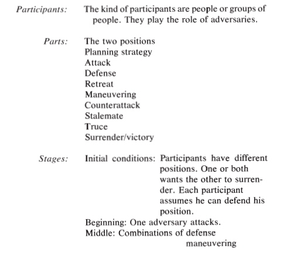

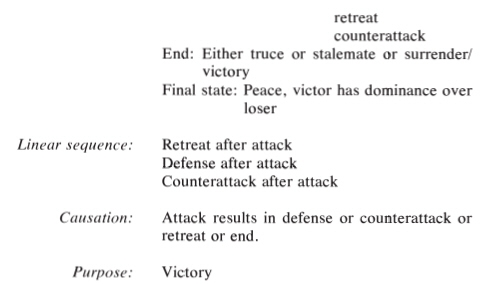

将对话理解为争论，意味着能够将“战争”概念的多维结构叠加到相应的“对话”结构之上。这种多维结构是*经验格式塔的特征，经验格式塔*是将经验组织成*结构化整体的方式。*在“争论即战争”的隐喻中，“对话”的格式塔是结构化的。此外，通过与战争（WAR）格式塔中特定元素的对应关系，我们可以进一步理解对话。因此，一种活动——交谈——可以从另一种活动——肢体冲突——的角度来理解。正是这种多维格式塔结构赋予了我们的经验以*连贯性。当*战争格式塔与我们在对话中的感知和行为相契合时，我们便将对话体验为一场争论。

Understanding a conversation as being an argument involves being able to superimpose the multidimensional structure of part of the concept WAR upon the corresponding structure CONVERSATION. Such multidimensional structures characterize *experiential gestalts,* which are ways of organizing experiences into *structured wholes.* In the ARGUMENT IS WAR metaphor, the gestalt for CONVERSATION is structured further by means of correspondences with selected elements of the gestalt for WAR. Thus one activity, talking, is understood in terms of another, physical fighting. Structuring our experience in terms of such multidimensional gestalts is what makes our experience *coherent.* We experience a conversation as an argument when the WAR gestalt fits our perceptions and actions in the conversation.

理解这种多维格式塔及其相互关联是理解我们经验连贯性的关键。正如我们前面所看到的，*经验格式塔是多维的结构化整体。*而它们的维度又是由直接涌现的概念定义的。也就是说，各种维度（参与者、部分、阶段等等）都是从我们的经验中自然涌现出来的范畴。我们已经看到，因果关系是一个直接涌现的概念，而其他维度……我们对自身经验进行分类的术语具有相当明显的经验基础：

Understanding such multidimensional gestalts and the correlations between them is the key to understanding coherence in our experience. As we saw above, *experiential gestalts are multidimensional structured wholes.* Their dimensions, in turn, are defined in terms of directly emergent concepts. That is, the various dimensions (participants, parts, stages, etc.) are categories that emerge naturally from our experience. We have already seen that CAUSATION is a directly emergent concept, and the other dimensions in terms of which we categorize our experience have a fairly obvious experiential basis:

*参与者：*这一维度源于“自我”的概念，即自我是一个可与其所执行的行为区分开来的行动者。我们还区分参与者的*类型*（例如，人、动物、物体）。

*Participants:* This dimension arises out of the concept of the SELF as an actor distinguishable from the actions he performs. We also distinguish *kinds* of participants (e.g., people, animals, objects).

*零件：*我们我们体验到自身拥有可以独立控制的各个部分（手臂、腿等等）。同样，我们对物理对象的体验，要么基于它们天然存在的部分，要么基于我们通过感知、互动或使用而赋予它们的部分。类似地，我们也会将部分-整体结构强加于事件和活动之上。而且，就像参与者的情况一样，我们区分*各种*部件（例如，各种物体、各种活动等）。

*Parts:* We experience ourselves as having parts (arms, legs, etc.) that we can control independently. Likewise, we experience physical objects either in terms of parts that they naturally have or parts that we impose upon them, either by virtue of our perceptions, our interactions with them, or our uses for them. Similarly, we impose a part-whole structure on events and activities. And, as in the case of participants, we distinguish *kinds* of parts (e.g., kinds of objects, kinds of activities, etc.).

*阶段：*我们最简单的运动功能包括知道我们在哪里以及我们处于什么位置（初始条件），开始移动（开始），执行运动功能（中间），以及停止（结束），这使我们处于最终状态。

*Stages:* Our simplest motor functions involve knowing where we are and what position we are in (initial conditions), starting to move (beginning), carrying out the motor function (middle), and stopping (end), which leaves us in a final state.

*线性序列：*同样，控制我们最简单的运动功能需要让我们把它们按正确的线性顺序排列。

*Linear sequence:* Again, the control of our simplest motor functions requires us to put them in the right linear sequence.

*目的：*从出生（甚至更早）起，我们就有需求和欲望，并且很早就意识到我们可以通过某些行为（哭泣、移动、操纵物体）来满足这些需求和欲望。